# Contenido

## Introducción

Este documento describe el trabajo realizado durante la ejecución de la prueba técnica en el proceso de selección llevado a cabo para cubrir el puesto de Jr Data Engineer, dentro del departamento de CoE (Center of Excellence), en Fujitsu Spain. Este es el reto planteado:

[figure not shown]

En primer lugar, se estudiaran las fuentes de datos proporcionadas y su contexto. Tras esa tarea previa, se realizarán análisis exploratorios, trabajos de ingeniería de características, codificación de variables y, por último, se utilizarán distintos algoritmos durante la búsqueda y construcción de un modelo predictivo para este conjunto de datos.

En cuanto a los lenguajes de programación utilizados en este proyecto, se ha trabajado tanto en R como en Python. Finalmente, se ha decidido usar el segundo para confeccionar este documento en formato HTML, ya que se ha detectado una mayor eficiencia al realizar la mayoria de las tareas de entrenamiento de modelos.

## Carga del conjunto de datos. Limpieza.

A continuación, se explica la tarea de importación de cada uno de los seis archivos de datos proporcionados, las dificultades encontradas durante el proceso y la limpieza llevada a cabo en ellos. También se muestran algunos estadísticos descriptivos que permitan realizar una primera aproximación a los datos.

### Importación client_hostname_location.csv

Se trata de un fichero CSV que utiliza el carácter "Â¢" como separador de campos. En cuanto a la codificación de caracteres, se utiliza el parámetro encoding='ISO-8859-1' durante su importación.

```python
import pandas as pd
pd.set_option('display.max_columns', None)

# Importa el archivo CSV usando el separador y la codificación adecuados
df_client_hostname_location_csv = pd.read_csv('client_hostname_location.csv', sep='Â¢', encoding='ISO-8859-1', engine='python')

df_client_hostname_location_csv
```

|  | client | hostname | alias_list | address_list | CodeProvince |
| --- | --- | --- | --- | --- | --- |
| 0 | 5.123.144.95 | 5.123.144.95 | [Errno 1] Unknown host | NaN | 30 |
| 1 | 5.122.76.187 | 5.122.76.187 | [Errno 1] Unknown host | NaN | 18 |
| 2 | 5.215.249.99 | 5.215.249.99 | [Errno 1] Unknown host | NaN | 1 |
| 3 | 31.56.102.211 | 31-56-102-211.shatel.ir | ['211.102.56.31.in-addr.arpa'] | ['31.56.102.211'] | 42 |
| 4 | 5.123.166.223 | 5.123.166.223 | [Errno 1] Unknown host | NaN | 31 |
| ... | ... | ... | ... | ... | ... |
| 258440 | 5.116.105.239 | 5.116.105.239 | [Errno 1] Unknown host | NaN | 24 |
| 258441 | 95.80.131.30 | 95-80-131-30.maxnet.ir | ['30.131.80.95.in-addr.arpa'] | ['95.80.131.30'] | 34 |
| 258442 | 2.177.65.234 | 2.177.65.234 | [Errno 1] Unknown host | NaN | 17 |
| 258443 | 5.119.39.232 | 5.119.39.232 | [Errno 1] Unknown host | NaN | 2 |
| 258444 | 5.125.96.182 | 5.125.96.182 | [Errno 1] Unknown host | NaN | 4 |

258445 rows × 5 columns

```python
# Renombra columnas
df_client_hostname_location_csv.rename(columns={'CodeProvince': 'province_code', 'client': 'client_ip'}, inplace=True)
```

En este caso, al igual que en todos los archivos proporcionados, se comprueba si existen columnas que no contengan duplicados y que, en consecuencia, puedan optar a clave primaria. Para facilitar esta tarea, vamos a crear la función find_primary_key.

```python
def find_primary_key(df):
    """
    Función para buscar columnas en un dataframe que podrían optar a ser clave primaria
    (es decir, columnas sin valores duplicados).

    Parámetros:
    df (pandas.core.frame.DataFrame): el dataframe sobre el que se quiere realizar la búsqueda.

    Devuelve:
    List: lista de nombres de columnas que podrían optar a ser clave primaria.
    """
    columns_without_duplicates = []

    # Itera sobre cada columna del dataframe
    for column in df.columns:
        # Verifica si hay duplicados en la columna
        if not df[column].duplicated().any():
            # Si no hay duplicados, agrega la columna a la lista
            columns_without_duplicates.append(column)

    return columns_without_duplicates
```

```python
columns_without_duplicates = find_primary_key(df_client_hostname_location_csv)

# Imprime el nombre de las columnas sin duplicados
if len(columns_without_duplicates) > 0:
    print("El dataframe df_client_hostname_location_csv posee esta/s columna/s que no contiene/n valores duplicados: {}".format(columns_without_duplicates))
else:
    print("No existen columnas sin valores duplicados en df_client_hostname_location_csv.")
```

```
El dataframe df_client_hostname_location_csv posee esta/s columna/s que no contiene/n valores duplicados: ['client_ip']
```

El archivo client_hostname_location.csv contiene 258445 registros y 5 columnas. Posee información acerca de la ubicación de los clientes que han realizado solicitudes al servidor.

**Observaciones:**

- La columna “client_ip” podría optar a ser clave primaria, ya que no contiene duplicados.
- Parece que la información contenida en los campos client_ip y hostname es redundante.
- Parece que la información de las columnas alias_list y address_list no es relevante.

```python
# Porcentaje de información redundante en las columnas client_ip y hostname
redundant_percentage = (df_client_hostname_location_csv['client_ip'] == df_client_hostname_location_csv['hostname']).mean() * 100

print('Porcentaje de información redundante en las columnas client_ip y hostname:', redundant_percentage, '%')
```

```
Porcentaje de información redundante en las columnas client_ip y hostname: 97.74845711853585 %
```

Efectivamente, se confirma que los valores de las columnas client_ip y hostname coinciden en el 97,75% de los registros. Por tanto, se puede desestimar la segunda.

```python
# Porcentaje de registros que poseen el valor "[Errno 1] Unknown host" en la columna alias_list
unknown_host_percentage = (df_client_hostname_location_csv['alias_list'] == "[Errno 1] Unknown host").sum() / len(df_client_hostname_location_csv) * 100

print('Porcentaje de registros que poseen el valor "[Errno 1] Unknown host" en la columna alias_list:', unknown_host_percentage, '%')
```

```
Porcentaje de registros que poseen el valor "[Errno 1] Unknown host" en la columna alias_list: 97.74845711853585 %
```

También se ha comprobado que en el 97,75% de los registros los valores de la columna alias_list coinciden con "[Errno 1] Unknown host". Por tanto, este atributo no contiene información relevante y se puede desestimar.

```python
# Porcentaje de registros que contienen una cadena vacía "" en la columna address_list
empty_string_percentage = (df_client_hostname_location_csv['address_list'].isna()).sum() / len(df_client_hostname_location_csv) * 100

print('Porcentaje de registros que contienen una cadena vacía "" en la columna address_list:', empty_string_percentage, '%')
```

```
Porcentaje de registros que contienen una cadena vacía "" en la columna address_list: 97.74845711853585 %
```

Por último, se verifica que en el 97,75% de los casos, los registros de la columna address_list contienen una cadena vacía. En definitiva, eliminamos las tres columnas que no contienen información relevante.

```python
# Elimina las columnas 'hostname', 'alias_list' y 'address_list'
df_client_hostname_location_csv.drop(['hostname', 'alias_list', 'address_list'], axis=1, inplace=True)

print(df_client_hostname_location_csv.info())
df_client_hostname_location_csv
```

```
<class 'pandas.core.frame.DataFrame'>
RangeIndex: 258445 entries, 0 to 258444
Data columns (total 2 columns):
 #   Column         Non-Null Count   Dtype
---  ------         --------------   -----
 0   client_ip      258445 non-null  object
 1   province_code  258445 non-null  int64
dtypes: int64(1), object(1)
memory usage: 3.9+ MB
None
```

|  | client_ip | province_code |
| --- | --- | --- |
| 0 | 5.123.144.95 | 30 |
| 1 | 5.122.76.187 | 18 |
| 2 | 5.215.249.99 | 1 |
| 3 | 31.56.102.211 | 42 |
| 4 | 5.123.166.223 | 31 |
| ... | ... | ... |
| 258440 | 5.116.105.239 | 24 |
| 258441 | 95.80.131.30 | 34 |
| 258442 | 2.177.65.234 | 17 |
| 258443 | 5.119.39.232 | 2 |
| 258444 | 5.125.96.182 | 4 |

258445 rows × 2 columns

Tras la limpieza inicial, solo quedan dos columnas en el dataframe df_client_hostname_location_csv. Estas relacionan la IP de cada cajero con el código de la provincia en la que se encuentra instalado. Este dataframe posee 258445 registros y su columna client_ip no contiene duplicados.

### Importación reparations.xml

Se trata de un archivo en formato XML que posee la siguiente estructura:

```
<?xml version='1.0' encoding='utf-8'?>
<data>
  <row>
    <client>5.123.144.95</client>
    <hostname>5.123.144.95</hostname>
    <Repaired>1</Repaired>
  </row>
  <row>
    <client>5.122.76.187</client>
    <hostname>5.122.76.187</hostname>
    <Repaired>1</Repaired>
  </row>
  ...
</data>
```

```python
import xml.etree.ElementTree as ET

# Parsea el archivo XML
tree = ET.parse('reparations.xml')
root = tree.getroot()

# Crea una lista de diccionarios para almacenar los datos
data = []
for item in root:
    d = {}
    for child in item:
        d[child.tag] = child.text
    data.append(d)

# Convierte la lista de diccionarios en un DataFrame
df_reparations_xml = pd.DataFrame(data)

# Renombra columnas
df_reparations_xml.rename(columns={'Repaired': 'repaired', 'client': 'client_ip'}, inplace=True)
# Cambia el tipo de la columna repaired a entero
df_reparations_xml['repaired'] = df_reparations_xml['repaired'].astype(int)

print(df_reparations_xml.info())
# Muestra el DataFrame
df_reparations_xml
```

```
<class 'pandas.core.frame.DataFrame'>
RangeIndex: 258445 entries, 0 to 258444
Data columns (total 3 columns):
 #   Column     Non-Null Count   Dtype
---  ------     --------------   -----
 0   client_ip  258445 non-null  object
 1   hostname   258441 non-null  object
 2   repaired   258445 non-null  int32
dtypes: int32(1), object(2)
memory usage: 4.9+ MB
None
```

|  | client_ip | hostname | repaired |
| --- | --- | --- | --- |
| 0 | 5.123.144.95 | 5.123.144.95 | 1 |
| 1 | 5.122.76.187 | 5.122.76.187 | 1 |
| 2 | 5.215.249.99 | 5.215.249.99 | 1 |
| 3 | 31.56.102.211 | 31-56-102-211.shatel.ir | 1 |
| 4 | 5.123.166.223 | 5.123.166.223 | 0 |
| ... | ... | ... | ... |
| 258440 | 5.116.105.239 | 5.116.105.239 | 1 |
| 258441 | 95.80.131.30 | 95-80-131-30.maxnet.ir | 0 |
| 258442 | 2.177.65.234 | 2.177.65.234 | 1 |
| 258443 | 5.119.39.232 | 5.119.39.232 | 0 |
| 258444 | 5.125.96.182 | 5.125.96.182 | 0 |

258445 rows × 3 columns

```python
columns_without_duplicates = find_primary_key(df_reparations_xml)

# Imprime el nombre de las columnas sin duplicados
if len(columns_without_duplicates) > 0:
    print("El dataframe df_reparations_xml posee esta/s columna/s que no contiene/n valores duplicados: {}".format(columns_without_duplicates))
else:
    print("No existen columnas sin valores duplicados en df_reparations_xml.")
```

```
El dataframe df_reparations_xml posee esta/s columna/s que no contiene/n valores duplicados: ['client_ip']
```

```python
# Muestra los distintos valores que podemos encontrar en la columna "repaired"
print(df_reparations_xml["repaired"].unique().tolist())
```

```
[1, 0]
```

El archivo reparations.xml contiene 258445 registros y 3 campos. Posee información acerca de los clientes que realizaron solicitudes al servidor web: su IP, hostname e indica si se ha efectuado o no una reparación en estos equipos mediante la variable booleana repaired.

**Observaciones:**

- La columna client_ip podría optar a ser clave primaria, ya que no contiene duplicados.
- Parece que la información contenida en los campos client_ip y hostname es redundante.
- El número de registros de este archivo parece coincidir con el del anterior.

```python
# Calcula el porcentaje de información redundante en las columnas 'client_ip' y 'hostname'
redundant_percentage = (df_reparations_xml['client_ip'] == df_reparations_xml['hostname']).mean() * 100

print('Porcentaje de información redundante en las columnas client_ip y hostname:', redundant_percentage, '%')
```

```
Porcentaje de información redundante en las columnas client_ip y hostname: 97.74845711853585 %
```

Efectivamente, se confirma que los valores de las columnas client_ip y hostname coinciden en el 97,75% de los registros. Por tanto, desestimamos la segunda.

```python
# Elimina la columna 'hostname'
df_reparations_xml.drop('hostname', axis=1, inplace=True)
```

```python
# Compara el número de registros
if df_client_hostname_location_csv.shape[0] == df_reparations_xml.shape[0]:
    print("Los dataframes df_client_hostname_location_csv y df_reparations_xml poseen el mismo número de registros.")
else:
    print("Los dataframes df_client_hostname_location_csv y df_reparations_xml no tienen el mismo número de registros.")

# Convierte las columnas en conjuntos y los compara
set_client_csv = set(df_client_hostname_location_csv['client_ip'])
set_client_xml = set(df_reparations_xml['client_ip'])

if set_client_csv == set_client_xml:
    print("Las columnas 'client_ip' en ambos dataframes poseen exactamente los mismos valores.")
else:
    print("Las columnas 'client_ip' en ambos dataframes no poseen los mismos valores.")
```

```
Los dataframes df_client_hostname_location_csv y df_reparations_xml poseen el mismo número de registros.
Las columnas 'client_ip' en ambos dataframes poseen exactamente los mismos valores.
```

```python
# Número total de registros
total_records = len(df_reparations_xml)

# Número total de valores únicos por columna
unique_values = df_reparations_xml.nunique()

# Número total de valores faltantes por columna
missing_values = df_reparations_xml.isnull().sum()

print(f'Número total de registros: {total_records}\n\nValores únicos:\n{unique_values}\n\nValores faltantes:\n{missing_values}\n\nEstadísticos básicos:')

# Estadísticas básicas para las columnas numéricas
df_reparations_xml.describe().transpose()[['mean', '50%', 'std', 'min', 'max']]
```

```
Número total de registros: 258445

Valores únicos:
client_ip    258445
repaired          2
dtype: int64

Valores faltantes:
client_ip    0
repaired     0
dtype: int64

Estadísticos básicos:
```

|  | mean | 50% | std | min | max |
| --- | --- | --- | --- | --- | --- |
| repaired | 0.499255 | 0.0 | 0.5 | 0.0 | 1.0 |

Tras la limpieza inicial, solo quedan dos columnas en el dataframe df_reparations_xml. Estas indican si un cajero (identificado por su IP) ha sido reparado o no. Este dataframe posee el mismo número de registros (258445) que el anterior (df_client_hostname_location_csv) y las direcciones IP que contienen en sus columnas client_ip coinciden. No existen valores faltantes y la media de 0.499 en la variable binaria "repaired" sugiere que la distribución de los cajeros reparados y no reparados es casi equitativa.

### Importación access.log

Se trata de un archivo de texto plano generado por un servidor web. Este tipo de ficheros son comunes en los registros (logs) que generan estas máquinas y son útiles para analizar el tráfico del servidor, identificar patrones de uso, errores, posibles ataques, etc.

El fichero no contiene cabecera que indique los campos que incluye. Los nombres y descripción de los campos se han deducido a partir de los datos que contienen. Para importar el archivo se utiliza la función read_csv, indicando el espacio como separador de campos. Esto provoca que el campo “timestamp” quede partido en dos columnas (“timestamp_1” y “timestamp_2”), por lo que se realiza una concatenación de estas después de la importación para obtener la columna “timestamp”.

```python
# Lee el archivo de texto plano
df_access_log = pd.read_csv('access.log', sep=' ', header=None)

# Asigna nombres a las columnas del DataFrame.
df_access_log.columns = ['client_ip', 'name', 'user_id', 'timestamp_1', 'timestamp_2', 'method_url', 'response_code', 'size', 'referer', 'user_agent', 'server_reg']

# Crea la columna "timestamp" al concatenar las registros de las columnas "timestamp_1" y "timestamp_2"
df_access_log.insert(4, 'timestamp', df_access_log['timestamp_1'] + df_access_log['timestamp_2'])

# Elimina las columnas "timestamp_1" y "timestamp_2"
df_access_log = df_access_log.drop(columns=['timestamp_1', 'timestamp_2'])

# Muestra el DataFrame resultante
df_access_log
```

|  | client_ip | name | user_id | timestamp | method_url | response_code | size | referer | user_agent | server_reg |
| --- | --- | --- | --- | --- | --- | --- | --- | --- | --- | --- |
| 0 | 54.36.149.41 | - | - | [22/Jan/2019:03:56:14+0330] | GET /filter/27\|13%20%D9%85%DA%AF%D8%A7%D9%BE%D... | 200 | 30577 | - | Mozilla/5.0 (compatible; AhrefsBot/6.1; +http:... | - |
| 1 | 31.56.96.51 | - | - | [22/Jan/2019:03:56:16+0330] | GET /image/60844/productModel/200x200 HTTP/1.1 | 200 | 5667 | https://www.zanbil.ir/m/filter/b113 | Mozilla/5.0 (Linux; Android 6.0; ALE-L21 Build... | - |
| 2 | 31.56.96.51 | - | - | [22/Jan/2019:03:56:16+0330] | GET /image/61474/productModel/200x200 HTTP/1.1 | 200 | 5379 | https://www.zanbil.ir/m/filter/b113 | Mozilla/5.0 (Linux; Android 6.0; ALE-L21 Build... | - |
| 3 | 40.77.167.129 | - | - | [22/Jan/2019:03:56:17+0330] | GET /image/14925/productModel/100x100 HTTP/1.1 | 200 | 1696 | - | Mozilla/5.0 (compatible; bingbot/2.0; +http://... | - |
| 4 | 91.99.72.15 | - | - | [22/Jan/2019:03:56:17+0330] | GET /product/31893/62100/%D8%B3%D8%B4%D9%88%D8... | 200 | 41483 | - | Mozilla/5.0 (Windows NT 6.2; Win64; x64; rv:16... | - |
| ... | ... | ... | ... | ... | ... | ... | ... | ... | ... | ... |
| 10365147 | 188.229.21.56 | - | - | [26/Jan/2019:20:29:13+0330] | GET /content/view/shoppingRules HTTP/1.1 | 302 | 0 | https://www.zanbil.ir/m/product/32106/62372/%D... | Mozilla/5.0 (Linux; Android 7.0; SM-N920C Buil... | - |
| 10365148 | 5.127.220.71 | - | - | [26/Jan/2019:20:29:13+0330] | GET /apple-touch-icon-120x120.png HTTP/1.1 | 404 | 32420 | - | MobileSafari/604.1 CFNetwork/976 Darwin/18.2.0 | - |
| 10365149 | 5.213.7.50 | - | - | [26/Jan/2019:20:29:13+0330] | GET /m/product/18962/%D8%BA%D8%B0%D8%A7-%D8%B3... | 200 | 20959 | https://www.google.com/ | Mozilla/5.0 (iPhone; CPU iPhone OS 10_2_1 like... | - |
| 10365150 | 109.125.169.52 | - | - | [26/Jan/2019:20:29:13+0330] | GET /image/%7B%7BbasketItem.id%7D%7D?type=prod... | 200 | 5 | https://www.zanbil.ir/ | Mozilla/5.0 (Windows NT 6.1; rv:64.0) Gecko/20... | - |
| 10365151 | 37.129.59.160 | - | - | [26/Jan/2019:20:29:13+0330] | GET /basket/view HTTP/1.1 | 200 | 17299 | https://www-zanbil-ir.cdn.ampproject.org/v/s/w... | Mozilla/5.0 (Linux; Android 6.0.1; D6633 Build... | - |

10365152 rows × 10 columns

```python
columns_without_duplicates = find_primary_key(df_access_log)

# Imprime el nombre de las columnas sin duplicados
if len(columns_without_duplicates) > 0:
    print("El dataframe df_access_log posee esta/s columna/s que no contiene/n valores duplicados: {}".format(columns_without_duplicates))
else:
    print("No existen columnas sin valores duplicados en df_access_log.")
```

```
No existen columnas sin valores duplicados en df_access_log.
```

```python
# Comprueba si hay alguna columna con valores nulos
cols_with_missing_values = df_access_log.columns[df_access_log.isnull().any()]
# Imprime el nombre de las columnas con valores nulos
if len(cols_with_missing_values) > 0:
  print("Esta/s columna/s contienen valores nulos: {}".format(list(cols_with_missing_values)))
else:
  print("No existen columnas con valores nulos.")
```

```
Esta/s columna/s contienen valores nulos: ['method_url', 'referer', 'user_agent']
```

```python
# Número total de valores únicos por columna
unique_values = df_access_log.nunique()
print(f'Valores únicos:\n{unique_values}')
```

```
Valores únicos:
client_ip        258606
name                  1
user_id               2
timestamp        400109
method_url       894210
response_code        16
size              69707
referer          103237
user_agent        28343
server_reg         1558
dtype: int64
```

**Observaciones:**

- El fichero access.log contiene más de 10 millones de registros (10.365.152) y 10 variables.
- No existe ningún campo que pueda optar a ser clave primaria. Todas las columnas contienen duplicados.
- Parece que la mayoría de los registros contienen un guion en los campos name, user_id y server_reg.
- Se observa que los distintos métodos de petición HTTP que aparecen en el campo method_url de este archivo de log son: GET, HEAD, POST, CONNECT, OPTIONS y PROPFIND, aunque existen algunos valores que no corresponden a ninguno de estos métodos.
- Algunos registros contienen direcciones IP del tipo IPv4 e IPv6 en el campo server_reg.
- El campo client_ip contiene 161 direcciones IP (258606 - 258445) que no se encuentran en el archivo client_hostname_location.csv que se importó anteriormente. Esas filas serán eliminadas, ya que no tenemos información de estas máquinas en los archivos anteriores.
- La información contenida en el campo user_agent indica que los agentes de usuario que han realizado las solicitudes se ubican en dispositivos con una tipología variada (equipos de escritorio, dispositivos móviles, etc.) y que utilizan sistemas operativos como Linux, Android, Windows, iOS, etc.
- Las fechas más antigua y reciente que encontramos en el campo “timestamp” son respectivamente: el 22/Jan/2019-03:56:14 y el 26/Jan/2019 20:29:13 (abarca 5 días aproximadamente).

```python
# Calcula el porcentaje de registros que poseen un guion (-) en la columna 'name'
dash_percentage = (df_access_log['name'] == "-").sum() / len(df_access_log) * 100

print('Porcentaje de registros que poseen un guion (-) en la columna name:', dash_percentage, '%.')
```

```
Porcentaje de registros que poseen un guion (-) en la columna name: 100.0 %.
```

Efectivamente, se confirma que la totalidad de los registros poseen un guion (-) en la columna name. En consecuencia, se puede eliminar por no poseer información relevante.

```python
# Calcula el porcentaje de registros que poseen un guion (-) en la columna 'user_id'
dash_percentage = (df_access_log['user_id'] == "-").sum() / len(df_access_log) * 100

print('Porcentaje de registros que poseen un guion (-) en la columna user_id:', dash_percentage, '%.')
```

```
Porcentaje de registros que poseen un guion (-) en la columna user_id: 99.99998070457625 %.
```

De igual manera, el 99,99% de los registros poseen un guion (-) en la columna user_id. Por tanto, también se puede eliminar.

```python
# Calcula el porcentaje de registros que poseen un guion (-) en la columna 'server_reg'
dash_percentage = (df_access_log['server_reg'] == "-").sum() / len(df_access_log) * 100

print('Porcentaje de registros que poseen un guion (-) en la columna server_reg:', dash_percentage, '%.')
```

```
Porcentaje de registros que poseen un guion (-) en la columna server_reg: 99.76781816610118 %.
```

También se verifica que el 99,77% de los registros poseen un guion (-) en la columna server_reg. En conclusión, también se puede eliminar esta columna.

A continuación, vamos a extraer el método HTTP utilizado en cada registro de la columna method_url. Con esta información, se creará una nueva columna llamada http_method.

```python
# Crea una nueva columna con el método HTTP extraído
df_access_log['http_method'] = df_access_log['method_url'].apply(lambda x: str(x).split()[0])

# Define los métodos válidos
valid_methods = ["GET", "HEAD", "POST", "CONNECT", "OPTIONS", "PROPFIND"]

# Filtra registros con métodos no válidos
invalid_methods = df_access_log[~df_access_log['http_method'].isin(valid_methods)]

# Calcula el porcentaje de registros con métodos no válidos
percentage_invalid_methods = len(invalid_methods) / len(df_access_log) * 100

print(f'\nRegistros que poseen métodos no válidos en la columna http_method:\n  Porcentaje: {percentage_invalid_methods} %.\n  Total: {invalid_methods.shape[0]} registros.')

# Muestra los registros con métodos no válidos
invalid_methods
```

```
Registros que poseen métodos no válidos en la columna http_method:
  Porcentaje: 0.0005209764410594269 %.
  Total: 54 registros.
```

|  | client_ip | name | user_id | timestamp | method_url | response_code | size | referer | user_agent | server_reg | http_method |
| --- | --- | --- | --- | --- | --- | --- | --- | --- | --- | --- | --- |
| 136410 | 74.82.60.74 | - | - | [22/Jan/2019:08:27:26+0330] | \x13BitTorrent protocol\x00\x00\x00\x00\x00\x1... | 400 | 166 | - | - | - | \x13BitTorrent |
| 156367 | 80.82.64.127 | - | - | [22/Jan/2019:08:40:11+0330] | \x16\x03\x01\x00\x96\x01\x00\x00\x92\x03\x03\x... | 400 | 166 | - | - | - | \x16\x03\x01\x00\x96\x01\x00\x00\x92\x03\x03\x... |
| 318484 | 72.52.125.78 | - | - | [22/Jan/2019:09:55:32+0330] | \x17\x10\x05\x15JL\xAD\xDC\xCEL\xC1Ff>F | 400 | 166 | - | - | - | \x17\x10\x05\x15JL\xAD\xDC\xCEL\xC1Ff>F |
| 1049860 | 108.178.16.154 | - | - | [22/Jan/2019:14:32:00+0330] | j\x00\xA7\x00\xF3\x00H\x00z\x00\xF3\x00\xFE\x0... | 400 | 166 | - | - | - | j\x00\xA7\x00\xF3\x00H\x00z\x00\xF3\x00\xFE\x0... |
| 1515767 | 64.62.197.65 | - | - | [22/Jan/2019:18:04:50+0330] | \x00\x85\x07 | 400 | 166 | - | - | - | \x00\x85\x07 |
| 1515768 | 64.62.197.65 | - | - | [22/Jan/2019:18:04:50+0330] | \x05bE\x00\x05b\x00\x00@\x00;\x11\x0F\xAC\xD8:... | 400 | 166 | - | - | - | \x05bE\x00\x05b\x00\x00@\x00;\x11\x0F\xAC\xD8:... |
| 1681702 | 74.82.60.72 | - | - | [22/Jan/2019:19:31:13+0330] | E\x00\x00I\xCD{\x00\x00@\x11\xF5Q | 400 | 166 | - | - | - | E\x00\x00I\xCD{\x00\x00@\x11\xF5Q |
| 2066480 | 5.188.210.12 | - | - | [22/Jan/2019:23:05:04+0330] | \x05\x01\x00 | 400 | 166 | - | - | - | \x05\x01\x00 |
| 2068273 | 5.188.210.12 | - | - | [22/Jan/2019:23:06:22+0330] | \x04\x01\x00P\x05\xBC\xD2\x0C\x00 | 400 | 166 | - | - | - | \x04\x01\x00P\x05\xBC\xD2\x0C\x00 |
| 2327870 | 66.240.205.34 | - | - | [23/Jan/2019:03:09:34+0330] | Gh0st\xAD\x00\x00\x00\xE0\x00\x00\x00x\x9CKS``... | 400 | 166 | - | - | - | Gh0st\xAD\x00\x00\x00\xE0\x00\x00\x00x\x9CKS``... |
| 2340763 | 66.160.199.78 | - | - | [23/Jan/2019:03:52:09+0330] | E\x00\x00J\x11,@\x00@\x11\x7F\xA1 | 400 | 166 | - | - | - | E\x00\x00J\x11,@\x00@\x11\x7F\xA1 |
| 2366063 | 194.113.106.124 | - | - | [23/Jan/2019:05:21:53+0330] | NaN | 400 | 0 | - | - | - | nan |
| 2834614 | 94.183.88.223 | - | - | [23/Jan/2019:11:10:38+0330] | G | 400 | 0 | - | - | - | G |
| 2834672 | 94.183.88.223 | - | - | [23/Jan/2019:11:10:41+0330] | G | 400 | 0 | - | - | - | G |
| 2835551 | 94.183.88.223 | - | - | [23/Jan/2019:11:11:00+0330] | G | 400 | 0 | - | - | - | G |
| 2839663 | 94.183.88.223 | - | - | [23/Jan/2019:11:12:15+0330] | G | 400 | 0 | - | - | - | G |
| 2959843 | 74.82.17.87 | - | - | [23/Jan/2019:11:53:42+0330] | &\xBEi\x86p\xBAOt}U\x95\xB3\x5C\x1F\x02\x1D\x8... | 400 | 166 | - | - | - | &\xBEi\x86p\xBAOt}U\x95\xB3\x5C\x1F\x02\x1D\x8... |
| 2964923 | 74.82.17.87 | - | - | [23/Jan/2019:11:55:26+0330] | E\x03\x01\x02\x00\x01\x00\x01\xFC\x03\x039\xDC... | 400 | 166 | - | - | - | E\x03\x01\x02\x00\x01\x00\x01\xFC\x03\x039\xDC... |
| 2995238 | 74.82.60.66 | - | - | [23/Jan/2019:12:07:16+0330] | \x00\x84\x00\x01\x01\x01\x01\x01\x04\xD2\x00\x... | 400 | 166 | - | - | - | \x00\x84\x00\x01\x01\x01\x01\x01\x04\xD2\x00\x... |
| 3088635 | 74.82.60.85 | - | - | [23/Jan/2019:12:43:24+0330] | \x05bE\x00\x05b\x00\x00@\x00:\x11\x8E\x18\xAD\... | 400 | 166 | - | - | - | \x05bE\x00\x05b\x00\x00@\x00:\x11\x8E\x18\xAD\... |
| 3088697 | 74.82.60.85 | - | - | [23/Jan/2019:12:43:27+0330] | \x00\x00\x00\x03\x16edge-stun.facebook.com | 400 | 166 | - | - | - | \x00\x00\x00\x03\x16edge-stun.facebook.com |
| 3098502 | 74.82.60.85 | - | - | [23/Jan/2019:12:47:00+0330] | \x05bE\x00\x05b\x00\x00@\x00:\x11\xDC\xCBJ}\xA... | 400 | 166 | - | - | - | \x05bE\x00\x05b\x00\x00@\x00:\x11\xDC\xCBJ}\xA... |
| 3952707 | 66.160.178.90 | - | - | [23/Jan/2019:19:06:38+0330] | w\x12\xC4\xD1\x83\x07\x84\x14dJ4\x8D\xDBym\xAD... | 400 | 166 | - | - | - | w\x12\xC4\xD1\x83\x07\x84\x14dJ4\x8D\xDBym\xAD... |
| 4157749 | 185.222.211.18 | - | - | [23/Jan/2019:21:01:08+0330] | \x03\x00\x00/*\xE0\x00\x00\x00\x00\x00Cookie: ... | 400 | 166 | - | - | - | \x03\x00\x00/*\xE0\x00\x00\x00\x00\x00Cookie: |
| 4210780 | 72.52.125.79 | - | - | [23/Jan/2019:21:31:31+0330] | nKB*=w\xF4\x0C\xB5\x189\x9D\xB0<K\x9B\xBA\x82\... | 400 | 166 | - | - | - | nKB*=w\xF4\x0C\xB5\x189\x9D\xB0<K\x9B\xBA\x82\... |
| 4221032 | 94.23.156.20 | - | - | [23/Jan/2019:21:37:36+0330] | NaN | 400 | 0 | - | - | - | nan |
| 4348690 | 64.62.197.31 | - | - | [23/Jan/2019:22:43:20+0330] | \x00;\x01\x02\x00\x01\x00\x01\xFC\x03\x03\xC3/... | 400 | 166 | - | - | - | \x00;\x01\x02\x00\x01\x00\x01\xFC\x03\x03\xC3/... |
| 4589551 | 102.165.52.19 | - | - | [24/Jan/2019:01:21:49+0330] | \x16\x03\x01\x00^\x01\x00\x00Z\x03\x01\x5CG\xF4 | 400 | 166 | - | - | - | \x16\x03\x01\x00^\x01\x00\x00Z\x03\x01\x5CG\xF4 |
| 4589556 | 102.165.52.19 | - | - | [24/Jan/2019:01:21:49+0330] | \x16\x03\x01\x00^\x01\x00\x00Z\x03\x01\x5CG\xF4 | 400 | 166 | - | - | - | \x16\x03\x01\x00^\x01\x00\x00Z\x03\x01\x5CG\xF4 |
| 4707751 | 34.221.219.207 | - | - | [24/Jan/2019:06:57:45+0330] | t3 9.2.0.0 | 400 | 166 | - | - | - | t3 |
| 4978591 | 74.82.4.78 | - | - | [24/Jan/2019:10:36:55+0330] | r4---sn-a5msen7s.googlevideo.com.com\x01\xBB\... | 400 | 166 | - | - | - | r4---sn-a5msen7s.googlevideo.com.com\x01\xBB\x... |
| 4987186 | 74.82.4.78 | - | - | [24/Jan/2019:10:41:34+0330] | \x10\x7F\x91Q\xE3\x8E\x5C\xE7\xF4>\xB3&{o\xB9F... | 400 | 166 | - | - | - | \x10\x7F\x91Q\xE3\x8E\x5C\xE7\xF4>\xB3&{o\xB9F... |
| 5006848 | 72.52.87.84 | - | - | [24/Jan/2019:10:51:17+0330] | \x04\xB7\x14(\x8D\x17\xC7fR\x95\xE9.R\xAF62\xB... | 400 | 166 | - | - | - | \x04\xB7\x14(\x8D\x17\xC7fR\x95\xE9.R\xAF62\xB... |
| 5081781 | 52.53.248.70 | - | - | [24/Jan/2019:11:26:18+0330] | t3 9.2.0.0 | 400 | 166 | - | - | - | t3 |
| 5256694 | 64.71.174.32 | - | - | [24/Jan/2019:12:43:55+0330] | E\x00\x003\xAA1@\x00@\x11\xA6N | 400 | 166 | - | - | - | E\x00\x003\xAA1@\x00@\x11\xA6N |
| 5256785 | 64.71.174.32 | - | - | [24/Jan/2019:12:43:59+0330] | \x17\x03\x03\x01\xBB\x00\x00\x00\x00\x00\x00\x... | 400 | 166 | - | - | - | \x17\x03\x03\x01\xBB\x00\x00\x00\x00\x00\x00\x... |
| 5335397 | 102.165.52.19 | - | - | [24/Jan/2019:13:25:44+0330] | \x16\x03\x01\x00^\x01\x00\x00Z\x03\x01\x5CH\x9... | 400 | 166 | - | - | - | \x16\x03\x01\x00^\x01\x00\x00Z\x03\x01\x5CH\x9... |
| 5335413 | 102.165.52.19 | - | - | [24/Jan/2019:13:25:44+0330] | \x16\x03\x01\x00^\x01\x00\x00Z\x03\x01\x5CH\x9... | 400 | 166 | - | - | - | \x16\x03\x01\x00^\x01\x00\x00Z\x03\x01\x5CH\x9... |
| 5416916 | 188.210.165.90 | - | - | [24/Jan/2019:14:06:56+0330] | G | 400 | 0 | - | - | - | G |
| 5631046 | 208.85.211.218 | - | - | [24/Jan/2019:16:06:52+0330] | x | 400 | 166 | - | - | - | x |
| 6130990 | 158.69.237.205 | - | - | [24/Jan/2019:21:55:08+0330] | NaN | 400 | 0 | - | - | - | nan |
| 6131432 | 158.69.237.205 | - | - | [24/Jan/2019:21:55:23+0330] | NaN | 400 | 0 | - | - | - | nan |
| 6184539 | 194.113.106.125 | - | - | [24/Jan/2019:22:23:43+0330] | NaN | 400 | 0 | - | - | - | nan |
| 6591075 | 149.202.169.246 | - | - | [25/Jan/2019:05:47:45+0330] | \x15\x03\x01\x00\x02\x02P | 400 | 166 | - | - | - | \x15\x03\x01\x00\x02\x02P |
| 6591077 | 149.202.169.246 | - | - | [25/Jan/2019:05:47:46+0330] | \x15\x03\x01\x00\x02\x02P | 400 | 166 | - | - | - | \x15\x03\x01\x00\x02\x02P |
| 6614012 | 72.52.87.60 | - | - | [25/Jan/2019:07:14:40+0330] | \x03\x01\x02\x00\x01\x00\x01\xFC\x03\x03 \x84\... | 400 | 166 | - | - | - | \x03\x01\x02\x00\x01\x00\x01\xFC\x03\x03 |
| 6614642 | 72.52.87.60 | - | - | [25/Jan/2019:07:16:55+0330] | \x03\x01\x02\x00\x01\x00\x01\xFC\x03\x03\x94\x... | 400 | 166 | - | - | - | \x03\x01\x02\x00\x01\x00\x01\xFC\x03\x03\x94\x... |
| 6685244 | 5.188.210.12 | - | - | [25/Jan/2019:09:10:31+0330] | \x05\x01\x00 | 400 | 166 | - | - | - | \x05\x01\x00 |
| 6686801 | 5.188.210.12 | - | - | [25/Jan/2019:09:12:12+0330] | \x04\x01\x00P\x05\xBC\xD2\x0C\x00 | 400 | 166 | - | - | - | \x04\x01\x00P\x05\xBC\xD2\x0C\x00 |
| 7097695 | 185.53.88.19 | - | - | [25/Jan/2019:13:48:00+0330] | \x16\x03\x01\x00b\x01\x00\x00^\x03\x01\x5CJ\xE... | 400 | 166 | - | - | - | \x16\x03\x01\x00b\x01\x00\x00^\x03\x01\x5CJ\xE... |
| 7097704 | 185.53.88.19 | - | - | [25/Jan/2019:13:48:00+0330] | \x16\x03\x01\x00b\x01\x00\x00^\x03\x01\x5CJ\xE... | 400 | 166 | - | - | - | \x16\x03\x01\x00b\x01\x00\x00^\x03\x01\x5CJ\xE... |
| 7795906 | 194.113.106.126 | - | - | [25/Jan/2019:20:33:38+0330] | NaN | 400 | 0 | - | - | - | nan |
| 8238776 | 185.209.0.12 | - | - | [26/Jan/2019:00:28:34+0330] | \x03\x00\x00/*\xE0\x00\x00\x00\x00\x00Cookie: ... | 400 | 166 | - | - | - | \x03\x00\x00/*\xE0\x00\x00\x00\x00\x00Cookie: |
| 8312700 | 64.71.174.85 | - | - | [26/Jan/2019:01:25:01+0330] | \x17\x03\x03\x02f\x00\x00\x00\x00\x00\x00\x00\... | 400 | 166 | - | - | - | \x17\x03\x03\x02f\x00\x00\x00\x00\x00\x00\x00\... |

Se comprueba que existe un porcentaje muy bajo de registros que poseen bytes sin formato en el campo method_url. Podría tratarse de datos corruptos o mal formados, un intento de explotar un error de desbordamiento de buffer u otra vulnerabilidad de seguridad del servidor, problemas de codificación/decodificación en algún punto entre el cliente y el servidor, etc. También se observa que el código de respuesta obtenido en todos los casos es el 400. Este código indica que la solicitud del cliente está mal formada o es inválida, lo cual es correcto en este caso. Por tanto, el servidor no puede procesar la solicitud por un motivo que se percibe como un error del cliente.

Aunque podríamos eliminarlos, ya que se trata de un número muy bajo de registros (54), se opta por conservar esta información y marcar estos registros con el valor "ERROR" en el campo "http_method".

```python
# Marca los registros con métodos válidos
df_access_log.loc[~df_access_log['http_method'].isin(valid_methods), 'http_method'] = 'ERROR'
```

Ahora, vamos a construir una tabla de frecuencias de la nueva variable http_method que acabamos de crear.

```python
# Obtener la tabla de frecuencias de los valores únicos en la columna 'http_method'
df_access_log['http_method'].value_counts()
```

```
http_method
GET         10190005
POST          139155
HEAD           34501
OPTIONS         1424
ERROR             54
CONNECT           10
PROPFIND           3
Name: count, dtype: int64
```

Observamos que la frecuencia del valor GET es muy alto en comparación con el resto Esto parece normal a priori, ya que se trata el método más simple y común para solicitar recursos de un servidor. Vamos a calcular el porcentaje exacto de registros que poseen este valor.

```python
# Calcula el porcentaje de registros que poseen utilizan en método GET en la columna 'http_method'
get_percentage = (df_access_log['http_method'] == "GET").sum() / len(df_access_log) * 100

print('Porcentaje de registros que utilizan en método GET en la columna http_method:', get_percentage, '%.')
```

```
Porcentaje de registros que utilizan en método GET en la columna http_method: 98.3102322088475 %.
```

Se observa que no existe una gran variabilidad en la nueva variable http_method creada, ya que más del 98% de registros poseen el valor GET. Por tanto, no parece que esta columna pueda aportar mucha información a la hora de crear un modelo predictivo.

Ahora, vamos a construir una tabla de frecuencias de la columna response_code.

```python
# Obtener la tabla de frecuencias de los valores únicos en la columna 'response_code'
df_access_log['response_code'].value_counts()
```

```
response_code
200    9579825
304     340228
302     199835
404     105011
301      67553
499      50852
500      14266
403       5634
502        798
400        586
401        323
408        112
504        103
414         17
405          6
206          3
Name: count, dtype: int64
```

En este caso, la respuesta "200" es la que tiene mayor frecuencia, aunque se observa que existe mayor variabilidad que en la columna http_method. El código 200 es un código de respuesta exitosa que indica que el servidor pudo entregar lo que se le pidió. También se observa que hay un número considerable de redirecciones (301, 302, 304), lo cual es común en muchos sitios web.

Ahora vamos a cambiar el tipo de la columna "timestamp".

```python
# Modifica el tipo de la columna "timestamp"
df_access_log['timestamp'] = pd.to_datetime(df_access_log['timestamp'], format='[%d/%b/%Y:%H:%M:%S%z]')
```

```python
# Comprueba  si todos los elementos de la columna "clientIP" del dataFrame df_access_log
# se encuentran también en la columna "client_ip" del dataFrame df_client_hostname_location_csv
access_ips = set(df_access_log['client_ip'])
location_ips = set(df_client_hostname_location_csv['client_ip'])

missing_ips = access_ips - location_ips
# Calcula el porcentaje de registros del dataframe df_access_log que poseen direcciones en
# la columna "client_ip" que no se encuentran en el dataframe df_client_hostname_location_csv
percentage = len(missing_ips) / len(df_access_log) * 100

if len(missing_ips) > 0:
    print("Las siguientes direcciones IP están en 'df_access_log', pero no se encuentran en 'df_client_hostname_location_csv':\n\n{}\n".format(missing_ips))
    print(f"Se trata de un grupo de {len(missing_ips)} direcciones IP ({percentage} %), dentro de un conjunto de {len(access_ips)}.")
else:
    print("Todas las direcciones IP de 'df_access_log' se encuentran en 'df_reparations_xml'.")
```

```
Las siguientes direcciones IP están en 'df_access_log', pero no se encuentran en 'df_client_hostname_location_csv':

{'98.1.80.42', '118.68.205.254', '78.208.45.38', '68.183.90.135', '58.186.25.218', '189.134.81.243', '41.235.182.3', '186.147.251.21', '42.117.152.36', '89.35.146.67', '64.68.229.6', '42.115.193.34', '72.52.125.79', '99.100.6.45', '42.117.207.158', '42.119.194.186', '144.132.10.218', '91.238.210.203…

Se trata de un grupo de 161 direcciones IP (0.0015532816113068095 %), dentro de un conjunto de 258606.
```

El dataframe df_access_log representa la actividad entre los cajeros y el servidor HTTP. Se observa que **hay 161 máquinas que están generando actividad, pero no se conoce su ubicación (provincia) y tampoco sabemos si han sido reparadas o no**. Informaremos al cliente de la existencia de estas máquinas, pero no serán incluidas en el estudio que realizaremos a continuación, por lo que eliminaremos los registros asociados a ellas en este dataframe.

```python
# Filtra los registros con direcciones ip de las que conozcamos su ubicación y sepamos si han sido reparadas o no
df_access_log = df_access_log[df_access_log['client_ip'].isin(location_ips)].copy()
```

Finalmente, eliminamos las columnas que hemos comentado anteriormente.

```python
df_access_log.drop(['name', 'user_id', 'server_reg', 'method_url', 'referer', 'user_agent'], axis=1, inplace=True)
```

```python
df_access_log.info()
df_access_log
```

```
<class 'pandas.core.frame.DataFrame'>
Index: 10364923 entries, 0 to 10365151
Data columns (total 5 columns):
 #   Column         Dtype
---  ------         -----
 0   client_ip      object
 1   timestamp      datetime64[ns, UTC+03:30]
 2   response_code  int64
 3   size           int64
 4   http_method    object
dtypes: datetime64[ns, UTC+03:30](1), int64(2), object(2)
memory usage: 474.5+ MB
```

|  | client_ip | timestamp | response_code | size | http_method |
| --- | --- | --- | --- | --- | --- |
| 0 | 54.36.149.41 | 2019-01-22 03:56:14+03:30 | 200 | 30577 | GET |
| 1 | 31.56.96.51 | 2019-01-22 03:56:16+03:30 | 200 | 5667 | GET |
| 2 | 31.56.96.51 | 2019-01-22 03:56:16+03:30 | 200 | 5379 | GET |
| 3 | 40.77.167.129 | 2019-01-22 03:56:17+03:30 | 200 | 1696 | GET |
| 4 | 91.99.72.15 | 2019-01-22 03:56:17+03:30 | 200 | 41483 | GET |
| ... | ... | ... | ... | ... | ... |
| 10365147 | 188.229.21.56 | 2019-01-26 20:29:13+03:30 | 302 | 0 | GET |
| 10365148 | 5.127.220.71 | 2019-01-26 20:29:13+03:30 | 404 | 32420 | GET |
| 10365149 | 5.213.7.50 | 2019-01-26 20:29:13+03:30 | 200 | 20959 | GET |
| 10365150 | 109.125.169.52 | 2019-01-26 20:29:13+03:30 | 200 | 5 | GET |
| 10365151 | 37.129.59.160 | 2019-01-26 20:29:13+03:30 | 200 | 17299 | GET |

10364923 rows × 5 columns

Tras la limpieza, han quedado 10364923 registros y estos cinco campos: **client_ip** (IP del cajero/cliente que interactúa con el servidor HTTP), **timestamp** (momento en el que produjo la solicitud HTTP), **response_code** (código de respuesta obtenida a la petición que realiza), **size** (tamaño en bytes de la respuesta obtenida) y **http_method** (método HTTP utilizado).

### Importación provincias.xlsx

Se trata de un archivo de tipo xlsx que se puede importar con la función read_excel y el motor openpyxl.

```python
import openpyxl
import unicodedata

# Importa archivo provincias.xlsx
df_provinces_xlsx = pd.read_excel('provincias.xlsx', engine='openpyxl')

# Renombra columnas
df_provinces_xlsx = df_provinces_xlsx.rename(columns={'PostalCode': 'province_code', 'Provincia': 'province_name', 'TechniciansNumber': 'techs_num_per_prov'})

# Función para eliminar acentos de las cadenas
def strip_accents(text):
    """
    Función para eliminar acentos de las cadenas.

    Parámetros:
    text (str): la cadena a la que se le van a eliminar los acentos.

    Devuelve:
    str: cadena sin acentos.
    """
    try:
        text = unicode(text, 'utf-8')
    except NameError:
        pass
    text = unicodedata.normalize('NFD', text)\
           .encode('ascii', 'ignore')\
           .decode("utf-8")
    return str(text)

# Aplica la función anterior y ordena alfabéticamente
df_provinces_xlsx['province_name'] = df_provinces_xlsx['province_name'].apply(strip_accents)
df_provinces_xlsx = df_provinces_xlsx.sort_values(by='province_name')

df_provinces_xlsx
```

|  | province_name | province_code | techs_num_per_prov |
| --- | --- | --- | --- |
| 14 | A CORUNA | 15 | 5 |
| 0 | ALAVA - ARABA | 1 | 4 |
| 1 | ALBACETE | 2 | 2 |
| 2 | ALICANTE | 3 | 3 |
| 3 | ALMERIA | 4 | 3 |
| 32 | ASTURIAS | 33 | 5 |
| 4 | AVILA | 5 | 2 |
| 5 | BADAJOZ | 6 | 2 |
| 7 | BARCELONA | 8 | 5 |
| 47 | BIZKAIA | 48 | 2 |
| 8 | BURGOS | 9 | 3 |
| 9 | CACERES | 10 | 2 |
| 10 | CADIZ | 11 | 3 |
| 38 | CANTABRIA | 39 | 4 |
| 11 | CASTELLON | 12 | 3 |
| 50 | CEUTA | 51 | 1 |
| 12 | CIUDAD REAL | 13 | 2 |
| 13 | CORDOBA | 14 | 6 |
| 15 | CUENCA | 16 | 1 |
| 19 | GIPUZKOA | 20 | 3 |
| 16 | GIRONA | 17 | 3 |
| 17 | GRANADA | 18 | 3 |
| 18 | GUADALAJARA | 19 | 1 |
| 20 | HUELVA | 21 | 1 |
| 21 | HUESCA | 22 | 2 |
| 6 | ILLES BALEARES | 7 | 5 |
| 22 | JAEN | 23 | 3 |
| 25 | LA RIOJA | 26 | 2 |
| 34 | LAS PALMAS | 35 | 7 |
| 23 | LEON | 24 | 4 |
| 24 | LLEIDA | 25 | 1 |
| 26 | LUGO | 27 | 2 |
| 27 | MADRID | 28 | 4 |
| 28 | MALAGA | 29 | 8 |
| 51 | MELILLA | 52 | 1 |
| 29 | MURCIA | 30 | 5 |
| 30 | NAVARRA | 31 | 2 |
| 31 | OURENSE | 32 | 2 |
| 33 | PALENCIA | 34 | 2 |
| 35 | PONTEVEDRA | 36 | 4 |
| 36 | SALAMANCA | 37 | 2 |
| 39 | SEGOVIA | 40 | 3 |
| 40 | SEVILLA | 41 | 2 |
| 41 | SORIA | 42 | 3 |
| 37 | STA CRUZ DE TENERIFE | 38 | 3 |
| 42 | TARRAGONA | 43 | 3 |
| 43 | TERUEL | 44 | 1 |
| 44 | TOLEDO | 45 | 3 |
| 45 | VALENCIA | 46 | 8 |
| 46 | VALLADOLID | 47 | 3 |
| 48 | ZAMORA | 49 | 2 |
| 49 | ZARAGOZA | 50 | 6 |

```python
columns_without_duplicates = find_primary_key(df_provinces_xlsx)

# Imprime el nombre de las columnas sin duplicados
if len(columns_without_duplicates) > 0:
    print("El dataframe df_provinces_xlsx posee esta/s columna/s que no contiene/n valores duplicados: {}".format(columns_without_duplicates))
else:
    print("No existen columnas sin valores duplicados en df_provinces_xlsx.")
```

```
El dataframe df_provinces_xlsx posee esta/s columna/s que no contiene/n valores duplicados: ['province_name', 'province_code']
```

El archivo provincias.xlsx contiene 52 registros y posee información acerca de las distintas provincias de España, su nombre, su código postal y el número de técnicos que opera en cada una de ellas.

**Observaciones:**

- En España, el código postal está compuesto por cinco dígitos numéricos. En el campo province_code (postal_code), encontramos los dos primeros, que hacen referencia a la provincia. Estos códigos fueron asignados siguiendo un orden alfabético (según el nombre oficial de las provincias en el año de implantación), del 01 al 50 (al escribirlos en modo texto, se completa con un cero a la izquierda cuando es necesario). A las ciudades de Ceuta y Melilla, por estar fuera de la división provincial, se les asignaron el 51 y el 52 respectivamente. A continuación de estos dos dígitos, le siguen otros tres que corresponden a zonas postales y de reparto asignadas por la Sociedad Estatal Correos y Telégrafos según criterios internos.
- Las columnas “province_name” y “province_code” podrían optar a ser clave primaria, ya que no contienen duplicados.

### Importación Manual status.pdf

Este archivo contiene una tabla con 37 filas. En ellas se describe el significado de los códigos que se utilizan en este sistema para identificar los eventos reportados por los clientes. Cada código de evento está compuesto por tres campos separados por guiones. La información se proporciona en una única tabla almacenada en un documento pdf de una sola página. Para extraerla vamos a utilizar la biblioteca **camelot**.

```python
# Importación del archivo "Manual status.pdf"
# !pip install camelot-py[cv]
import camelot
# print(camelot.__version__)

# Lee la tabla del archivo PDF
tables = camelot.read_pdf('Manual status.pdf', flavor='stream', pages='1')

# Convierte la tabla 0 en un DataFrame de Pandas
df_manual_status_pdf = tables[0].df

# Renombra columnas
df_manual_status_pdf = df_manual_status_pdf.rename(columns={0: 'event_code', 1: 'event_description'})
df_manual_status_pdf = df_manual_status_pdf.reindex(df_manual_status_pdf.index.drop(0)).reset_index(drop=True)

# Concatena los valores en la columna 2 con los de la fila anterior si la columna 1 está vacía
for i in range(len(df_manual_status_pdf) - 1, 1, -1):
    if df_manual_status_pdf.iloc[i, 0] == '':
        df_manual_status_pdf.iloc[i-1, 1] = df_manual_status_pdf.iloc[i-1, 1] + ' ' + df_manual_status_pdf.iloc[i, 1]
        df_manual_status_pdf = df_manual_status_pdf.drop(i)

# Rehace los índices tras eliminar filas
df_manual_status_pdf = df_manual_status_pdf.reset_index(drop=True)

# Corrige error codificación en caracteres acentuados del campo "event_description"
df_manual_status_pdf['event_description'] = df_manual_status_pdf['event_description'].str.replace('�', 'ó')
df_manual_status_pdf['event_description'] = df_manual_status_pdf['event_description'].str.replace('despuós', 'después')

df_manual_status_pdf
```

|  | event_code | event_description |
| --- | --- | --- |
| 0 | 40-1-01000001 | Versión del NEW Service Provider |
| 1 | 41-1-00000001 | (40C-SNBC) El Service provider ha arrancado. V... |
| 2 | 38-1-00000007 | El service provider ha arrancado correctamente. |
| 3 | 40-1-01000002 | El dispositivo se ha iniciado correctamente |
| 4 | 40-2-01000002 | Detector de colisiones deshabilitado |
| 5 | 01-2-00000002 | El sistema se ha detenido |
| 6 | 01-2-00000001 | El sistema ha arrancado |
| 7 | 01-4-00000002 | Se inició el servicio de Registro de eventos |
| 8 | 02-4-000000FF | Error en el arranque de un servicio |
| 9 | 38-4-00000008 | Error accediendo a la información de registro |
| 10 | 38-3-0100FFFF | (PPRX200) Read error or check error. |
| 11 | 83-2-00000001 | Aplicación: solicitada acción inmediata |
| 12 | 83-1-00000004 | StabMon: finalización de proceso por IPL |
| 13 | 83-2-00000003 | StabMon: antes de IPL |
| 14 | 83-2-00000004 | StabMon: después de IPL |
| 15 | 42-3-00001600 | <Host Interface>unjust data classification of ... |
| 16 | 83-1-00000003 | StabMon: finalización controlada de proceso po... |
| 17 | 38-3-00007102 | Mechanical / Hardware Error: MS Homeward Time ... |
| 18 | 38-3-01007102 | Time limit of MS head moving (Return). |
| 19 | 38-1-00000006 | El error anterior ha sido recupeado |
| 20 | 42-3-00001501 | Sent error |
| 21 | 01-4-00000001 | Error de sistema en el arranque |
| 22 | 83-1-0000000A | EmergencyExit: finalización OK |
| 23 | 38-3-00007101 | Mechanical / Hardware Error: MS Outward Time over |
| 24 | 38-3-01007101 | Time limit of MS head moving (Outward). When M... |
| 25 | 38-3-00005811 | Paper Jam (Media Feeding Area): Insertion Port... |
| 26 | 38-3-01005811 | Inserter Jam. MRS does not detect arrival of a... |
| 27 | 38-3-0000583F | Paper Jam (Media Feeding Area): MS Position Ja... |
| 28 | 38-3-00007105 | Mechanical / Hardware Error: MS Sensor Failure... |
| 29 | 38-3-01007105 | MS sensor error (Not detecting). Both Homeposi... |
| 30 | 83-2-00000002 | StabMon: timeout en el watchdog |
| 31 | 35-3-0000FFFF | (A4T) Error hardware indeterminado |
| 32 | 35-3-0100FFFF | (TSRPR) Error hardware indeterminado |
| 33 | 38-3-0000850F | Scanning Error: Media Length Error |
| 34 | 38-3-0100850F | Scanner Passbook Length Error detection. As a ... |
| 35 | 38-3-00005701 | Media Removal |
| 36 | 38-3-01005701 | Pulling out of a passbook. A passbook at the i... |

```python
columns_without_duplicates = find_primary_key(df_manual_status_pdf)

# Imprime el nombre de las columnas sin duplicados
if len(columns_without_duplicates) > 0:
    print("El dataframe df_manual_status_pdf posee esta/s columna/s que no contiene/n valores duplicados: {}".format(columns_without_duplicates))
else:
    print("No existen columnas sin valores duplicados en df_manual_status_pdf.")
```

```
El dataframe df_manual_status_pdf posee esta/s columna/s que no contiene/n valores duplicados: ['event_code', 'event_description']
```

**Observaciones:**

- Algunas filas contienen mensajes cuya longitud sobrepasa el ancho de su celda y ocupan varias líneas. Esta circunstancia dificulta la lectura de la tabla, por lo que ha sido necesario trabajar el dataframe obtenido para lograr un buen resultado.
- Se observa que la codificación utilizada al guardar el archivo no ha sido la adecuada. Esto ha provocado que los mensajes muestren el carácter "�" donde debiera haber vocales acentuadas. Por ejemplo: "Versi�n del NEW Service Provider". Este problema no se puede corregir aplicando un cambio de codificación o del juego de caracteres porque en todos los casos aparece el mismo símbolo "�", independientemente de que el carácter original fuera una "ó" o una "é".
- Las columnas "event_code" y "event_description" podrían optar a ser clave primaria, ya que no contienen duplicados.

### Importación status.db

Se trata de una base de datos SQLite; por tanto, se usará la biblioteca **sqlalchemy** para conectar con ella. Se realizará una primera consulta que permita conocer la estructura de las tablas que contiene. Tras haber extraído la información necesaria, se cerrará la conexión.

```python
from sqlalchemy import create_engine

# Conexión a la base de datos
engine = create_engine('sqlite:///status.db')

# Consulta para obtener la estructura de las tablas
query = "SELECT name FROM sqlite_master WHERE type='table';"

# Utiliza pandas para leer la estructura de las tablas
tables = pd.read_sql(query, engine)

# Muestra las tablas de la base de datos
print('Nombre de las tablas:')
print(tables)

# Carga la tabla en un dataframe
df_status_db = pd.read_sql('SELECT * FROM status', engine)

df_status_db
```

```
Nombre de las tablas:
     name
0  status
```

|  | IdEvento | client | hostname | alias_list |
| --- | --- | --- | --- | --- |
| 0 | 38-3-00007102 | 90.253.94.20 | 90.253.94.20 | [Errno 1] Unknown host |
| 1 | 83-1-00000003 | 90.253.94.20 | 90.253.94.20 | [Errno 1] Unknown host |
| 2 | 38-3-01007101 | 90.253.94.20 | 90.253.94.20 | [Errno 1] Unknown host |
| 3 | 38-3-00007102 | 78.39.28.66 | 78.39.28.66 | [Errno 1] Unknown host |
| 4 | 38-3-01005811 | 78.39.28.66 | 78.39.28.66 | [Errno 1] Unknown host |
| ... | ... | ... | ... | ... |
| 1006541 | 01-4-00000002 | 5.122.215.252 | 5.122.215.252 | [Errno 1] Unknown host |
| 1006542 | 01-4-00000002 | 40.77.193.18 | 40.77.193.18 | [Errno 1] Unknown host |
| 1006543 | 01-4-00000002 | 2.183.199.233 | 2.183.199.233 | [Errno 1] Unknown host |
| 1006544 | 01-4-00000002 | 188.229.8.103 | 188.229.8.103 | [Errno 1] Unknown host |
| 1006545 | 01-4-00000002 | 5.116.222.147 | 5.116.222.147 | [Errno 1] Unknown host |

1006546 rows × 4 columns

```python
columns_without_duplicates = find_primary_key(df_status_db)

# Imprime el nombre de las columnas sin duplicados
if len(columns_without_duplicates) > 0:
    print("El dataframe df_status_db posee esta/s columna/s que no contiene/n valores duplicados: {}".format(columns_without_duplicates))
else:
    print("No existen columnas sin valores duplicados en df_status_db.")
```

```
No existen columnas sin valores duplicados en df_status_db.
```

Se observa que el archivo status.db contiene más de 1 millón de registros (1.006.546) y 4 variables que poseen información de estado (IdEvento), el hostname y el alias relacionados con una IP de cliente (client).

**Observaciones:**

- No existe ningún campo que pueda optar a clave primaria. Todas las columnas contienen duplicados.
- Parece que la información contenida en los campos client y hostname es redundante.
- Parece que el campo alias_list no contiene información relevante.

```python
print('Porcentaje de información redundante en las columnas client y hostname:',
      (df_status_db['client'] == df_status_db['hostname']).mean() * 100,
      '%')
```

```
Porcentaje de información redundante en las columnas client y hostname: 97.75151855950945 %
```

Efectivamente, se confirma que los valores de las columnas client y hostname coinciden en el 97,75% de los registros. Por tanto, se puede desestimar la segunda.

```python
percentage_errno1 = (df_status_db['alias_list'] == "[Errno 1] Unknown host").sum() / len(df_status_db) * 100

print(f"Porcentaje de registros que poseen el valor \"[Errno 1] Unknown host\" en la columna alias_list: {percentage_errno1:.2f}%")
```

```
Porcentaje de registros que poseen el valor "[Errno 1] Unknown host" en la columna alias_list: 97.75%
```

También se ha comprobado que, en el 97,75% de los registros, los valores de la columna alias_list coinciden con la cadena "[Errno 1] Unknown host". Por tanto, este atributo no contiene información relevante y se puede desestimar también.

Finalmente, eliminamos las columnas que no aportan información importante y renombramos convenientemente las dos restantes.

```python
df_status_db.drop(columns=['hostname', 'alias_list'], inplace=True)

# Renombra columnas
df_status_db = df_status_db.rename(columns={'IdEvento': 'event_code', 'client': 'client_ip'})

df_status_db.info()
df_status_db
```

```
<class 'pandas.core.frame.DataFrame'>
RangeIndex: 1006546 entries, 0 to 1006545
Data columns (total 2 columns):
 #   Column      Non-Null Count    Dtype
---  ------      --------------    -----
 0   event_code  1006546 non-null  object
 1   client_ip   1006546 non-null  object
dtypes: object(2)
memory usage: 15.4+ MB
```

|  | event_code | client_ip |
| --- | --- | --- |
| 0 | 38-3-00007102 | 90.253.94.20 |
| 1 | 83-1-00000003 | 90.253.94.20 |
| 2 | 38-3-01007101 | 90.253.94.20 |
| 3 | 38-3-00007102 | 78.39.28.66 |
| 4 | 38-3-01005811 | 78.39.28.66 |
| ... | ... | ... |
| 1006541 | 01-4-00000002 | 5.122.215.252 |
| 1006542 | 01-4-00000002 | 40.77.193.18 |
| 1006543 | 01-4-00000002 | 2.183.199.233 |
| 1006544 | 01-4-00000002 | 188.229.8.103 |
| 1006545 | 01-4-00000002 | 5.116.222.147 |

1006546 rows × 2 columns

### Combinar dataframes

Después de la limpieza inicial, vamos a combinar los dataframes df_client_hostname_location_csv y df_reparations_xml.

```python
df_client_reparations = pd.merge(df_client_hostname_location_csv, df_reparations_xml, on="client_ip")

# Elimina los DataFrames df_client_hostname_location_csv y df_reparations_xml
del df_client_hostname_location_csv
del df_reparations_xml
```

Tras realizar esta fusión, nos quedan estos cinco dataframes.

```python
print('df_client_reparations:')
print(df_client_reparations.info())
print('\ndf_access_log:')
print(df_access_log.info())
print('\ndf_provinces_xlsx:')
print(df_provinces_xlsx.info())
print('\ndf_status_db:')
print(df_status_db.info())
print('\ndf_manual_status_pdf:')
print(df_manual_status_pdf.info())
```

```
df_client_reparations:
<class 'pandas.core.frame.DataFrame'>
RangeIndex: 258445 entries, 0 to 258444
Data columns (total 3 columns):
 #   Column         Non-Null Count   Dtype
---  ------         --------------   -----
 0   client_ip      258445 non-null  object
 1   province_code  258445 non-null  int64
 2   repaired       258445 non-null  int32
dtypes: int32(1), int64(1), object(1)
memory usage: 4.9+ MB
None

df_access_log:
<class 'pandas.core.frame.DataFrame'>
Index: 10364923 entries, 0 to 10365151
Data columns (total 5 columns):
 #   Column         Dtype
---  ------         -----
 0   client_ip      object
 1   timestamp      datetime64[ns, UTC+03:30]
 2   response_code  int64
 3   size           int64
 4   http_method    object
dtypes: datetime64[ns, UTC+03:30](1), int64(2), object(2)
memory usage: 474.5+ MB
None

df_provinces_xlsx:
<class 'pandas.core.frame.DataFrame'>
Index: 52 entries, 14 to 49
Data columns (total 3 columns):
 #   Column              Non-Null Count  Dtype
---  ------              --------------  -----
 0   province_name       52 non-null     object
 1   province_code       52 non-null     int64
 2   techs_num_per_prov  52 non-null     int64
dtypes: int64(2), object(1)
memory usage: 1.6+ KB
None
```

[output cut: 9 more lines]

```
dtypes: object(2)
memory usage: 15.4+ MB
None

df_manual_status_pdf:
<class 'pandas.core.frame.DataFrame'>
RangeIndex: 37 entries, 0 to 36
Data columns (total 2 columns):
 #   Column             Non-Null Count  Dtype
---  ------             --------------  -----
 0   event_code         37 non-null     object
 1   event_description  37 non-null     object
dtypes: object(2)
memory usage: 720.0+ bytes
None
```

A continuación, vamos a representar las relaciones entre estos dataframes. Para ello, utilizaremos un diagrama de entidad-relación (ER).

[figure not shown]

### Guardar dataframes en archivos csv

Finalizamos este apartado almacenando los dataframes obtenidos tras la limpieza inicial, para poder recuperarlos en sesiones posteriores. También eliminamos todas las variables del espacio de nombres; esto permitirá ejecutar este notebook completo de manera secuencial sin experimentar problemas de memoria.

```python
# Guarda dataframes en formato CSV
df_client_reparations.to_csv('clean_data/client_reparations.csv', index=False)
df_access_log.to_csv('clean_data/access_log.csv', index=False)
df_provinces_xlsx.to_csv('clean_data/provinces.csv', index=False)
df_status_db.to_csv('clean_data/status_db.csv', index=False)
df_manual_status_pdf.to_csv('clean_data/status_manual.csv', index=False)

# Libera memoria
%reset -f
```

## Primer análisis exploratorio

Tras la limpieza anterior, vamos a estudiar las distribuciones de las variables más representativas de los distintos dataframes obtenidos.

```python
# Recupera dataframes guardados
import pandas as pd

df_client_reparations = pd.read_csv('clean_data/client_reparations.csv')
df_access_log = pd.read_csv('clean_data/access_log.csv')
df_provinces_xlsx = pd.read_csv('clean_data/provinces.csv')
df_status_db = pd.read_csv('clean_data/status_db.csv')
df_manual_status_pdf = pd.read_csv('clean_data/status_manual.csv')
```

### DataFrame df_client_reparations

#### Distribución de la variable binaria "repaired"

Vamos a comenzar este análisis exploratorio con el dataframe df_client_reparations; mostrando la distribución del atributo "repaired", que parece candidato a variable objetivo.

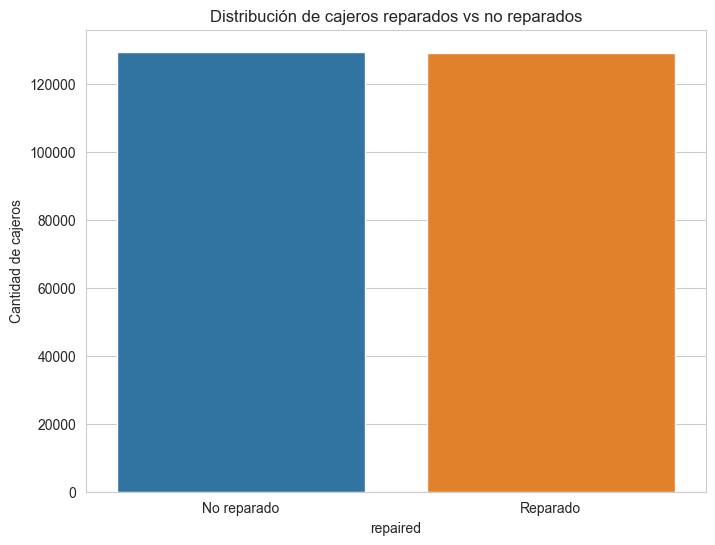

```python
import matplotlib.pyplot as plt
import seaborn as sns

# Establece el estilo de Seaborn
sns.set_style("whitegrid")

# Muestra la distribución de cajeros reparados vs no reparados
plt.figure(figsize=(8, 6))
sns.countplot(data=df_client_reparations, x='repaired')
plt.title('Distribución de cajeros reparados vs no reparados')
plt.ylabel('Cantidad de cajeros')
plt.xticks([0, 1], ['No reparado', 'Reparado'])
plt.show()
```

Se observa que las cantidades de cajeros reparados y no reparados son muy parecidas. Este equilibrio de clases ayudaría a evitar sesgos hacia la clase mayoritaria a la hora de construir un modelo clasificatorio, por ejemplo. En cuanto a la evaluación del rendimiento del modelo, esta situación también facilitaría la interpretación de resultados, siendo suficiente el uso de métricas de evaluación estándar como la precisión (accuracy). Por otro lado, cuando trabajamos con un conjunto de datos equilibrado, el modelo tiene la oportunidad de aprender adecuadamente tanto de los ejemplos positivos como de los negativos, lo que puede mejorar su capacidad predictiva.

#### Distribución de cajeros por provincias

Ahora, combinaremos los dataframes df_client_reparations y df_provinces_xlsx para poder mostrar los nombres de cada provincia al representar la distribución de cajeros por provincias.

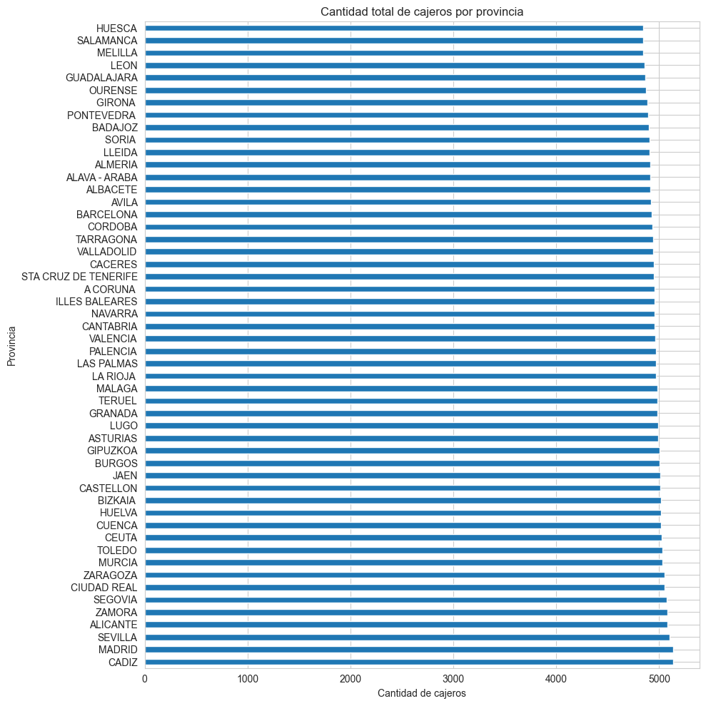

```python
# Combina df_client_reparations y df_provinces_xlsx
merged_df = pd.merge(df_client_reparations, df_provinces_xlsx, on='province_code', how='left')

# Cantidad total de cajeros por provincia
total_atms_per_province = merged_df['province_name'].value_counts()

# Grafica la cantidad total de cajeros por provincia
plt.figure(figsize=(10, 10))
total_atms_per_province.plot(kind='barh')
plt.title('Cantidad total de cajeros por provincia')
plt.ylabel('Provincia')
plt.xlabel('Cantidad de cajeros')
plt.tight_layout()
plt.show()
```

```python
print('Número de cajeros por provincia (mínimo):', total_atms_per_province.min())
print('Número de cajeros por provincia (máximo):', total_atms_per_province.max())
```

```
Número de cajeros por provincia (mínimo): 4842
Número de cajeros por provincia (máximo): 5136
```

De entrada, llama la atención que el número de cajeros que hay instalado en cada provincia es exageradamente alto (alrededor de unas 5000 máquinas/provincia); habría que plantearse seriamente si es necesario tener un parque de cajeros tan grande. Después, al comparar unas provincias con otras y observar los valores mínimo y máximo, resulta llamativo que el número de cajeros sea tan parecido en todas las provincias y que las pequeñas diferencias en esas cantidades otorguen un mayor número de cajeros a la provincia de Segovia que a la de Barcelona, por ejemplo. No parece que la cantidad de cajeros instalados en cada provincia sea proporcional al número de potenciales usuarios.

#### Proporción de cajeros reparados/no reparados en cada provincia

Veamos ahora como se distribuye la variable "repaired" en cada provincia.

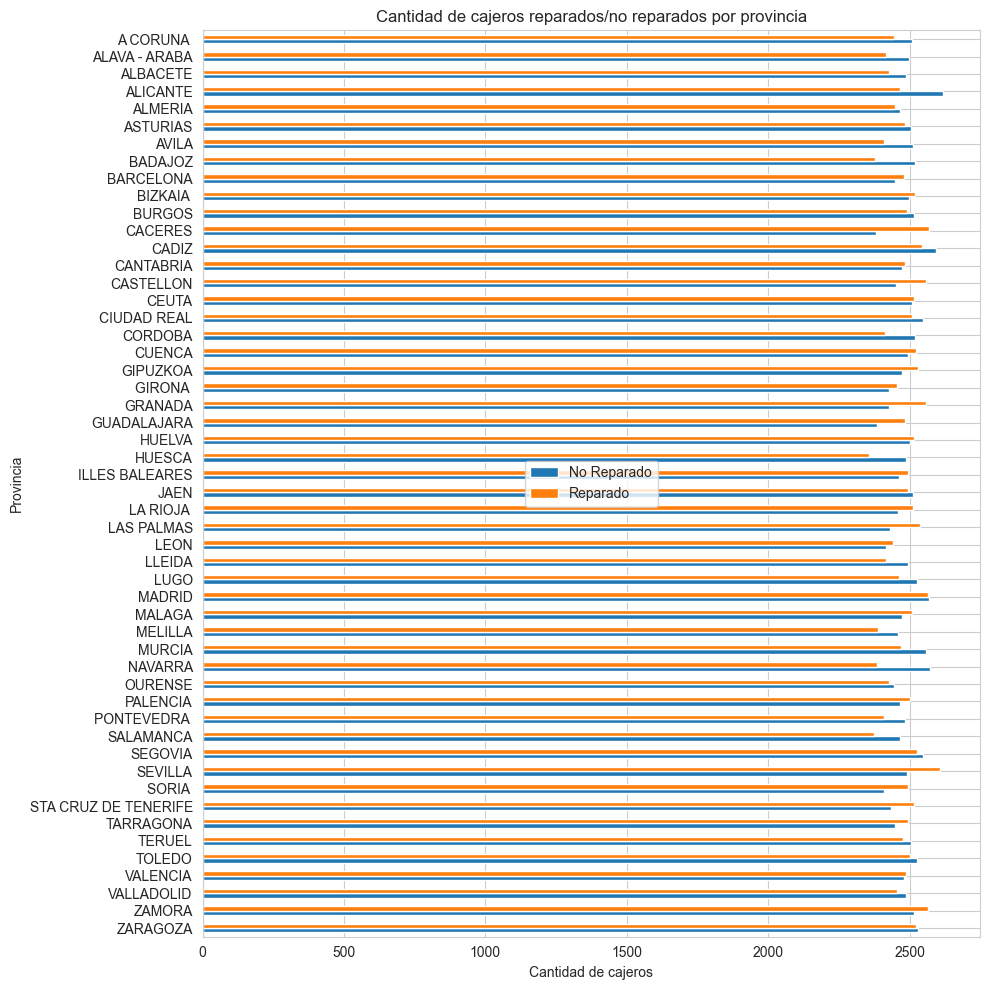

```python
# Agrupa por provincia y estado de reparación para contar cajeros
grouped_df = df_client_reparations.groupby(['province_code', 'repaired']).size().unstack()

# Ordena el dataframe por nombres de provincias
grouped_df = grouped_df.merge(df_provinces_xlsx[['province_code', 'province_name']],
                              left_index=True, right_on='province_code').set_index('province_name').sort_index(ascending=False).drop(columns=['province_code'])

# Grafica la cantidad de cajeros reparados y no reparados por provincia (barras agrupadas)
plt.figure(figsize=(10, 10))
grouped_df.plot(kind='barh', ax=plt.gca())
plt.title('Cantidad de cajeros reparados/no reparados por provincia')
plt.xlabel('Cantidad de cajeros')
plt.ylabel('Provincia')
plt.legend(labels=['No Reparado', 'Reparado'], loc='center')
plt.tight_layout()
plt.show()
```

Las mayores diferencias entre cajeros reparados y no reparados las encontramos en provincias como Alicante, Cáceres o Navarra, aunque resulta evidente que no son sustanciales. De hecho, salta a la vista que **la proporción entre los cajeros reparados y no reparados en cada provincia es muy parecida en todas ellas**. Vamos a comprobarlo.

```python
import numpy as np

# Agrupa el dataframe por provincia y calcula la media de cajeros reparados
prov_summary = df_client_reparations.groupby('province_code').agg({
    'repaired': lambda x: round((x.mean() * 100), 2)
}).reset_index()

prov_summary.columns = ['province_code', 'perc_repaired']

print('Porcentaje de cajeros reparados por provincia (mediana): ',
    np.median(prov_summary['perc_repaired']),
    '\nPorcentaje cajeros reparados por provincia (IQR): ',
    np.subtract(*np.percentile(prov_summary['perc_repaired'], [75, 25])))
```

```
Porcentaje de cajeros reparados por provincia (mediana):  49.88
Porcentaje cajeros reparados por provincia (IQR):  0.9825000000000017
```

En el último gráfico, se ha observado que los porcentajes de cajeros reparados son muy parecidos en todas las provincias (muy próximos al 50%). Precisamente, un rango intercuartílico (IQR) de 0,9825 indica una baja variabilidad: la mayoría de los valores del vector de porcentajes están muy cerca unos de otros (los datos están bastante concentrados en torno a la mediana).

Esto también significa que la variable binaria "repaired" posee una distribución equilibrada entre sus dos posibles clases (el valor positivo 1:"sí" y el valor negativo 0:"no"). Esta situación de equilibrio en la distribución de clases puede tener implicaciones importantes a la hora de elaborar un modelo predictivo en el que "repaired" sea la variable a predecir. Por un lado, un modelo entrenado en un conjunto de datos equilibrado podría obtener una precisión razonable al predecir ambas clases, ya que la igualdad en la distribución evitará que el modelo pueda sesgarse hacia una clase específica. Por otro lado, una baja variabilidad en los datos podría dificultar la detección de patrones durante la creación del modelo.

### DataFrame df_access_log

Ahora, mostraremos las distribuciones de los distintos atributos del dataframe df_access_log.

#### Distribución de los códigos de respuesta HTTP

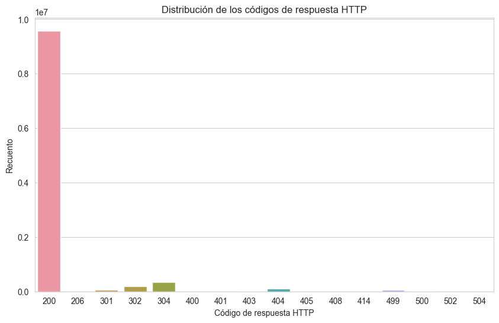

```python
# Muestra la distribución de los códigos de respuesta obtenidos
plt.figure(figsize=(10, 6))
sns.countplot(data=df_access_log, x='response_code')
plt.title('Distribución de los códigos de respuesta HTTP')
plt.xlabel('Código de respuesta HTTP')
plt.ylabel('Recuento')
plt.show()
```

Se observa que la mayoría de las peticiones realizadas al servidor HTTP obtienen el código de respuesta 200 (éxito). La diferencia con el resto de respuestas obtenidas es muy significativa.

#### Distribución de los métodos HTTP

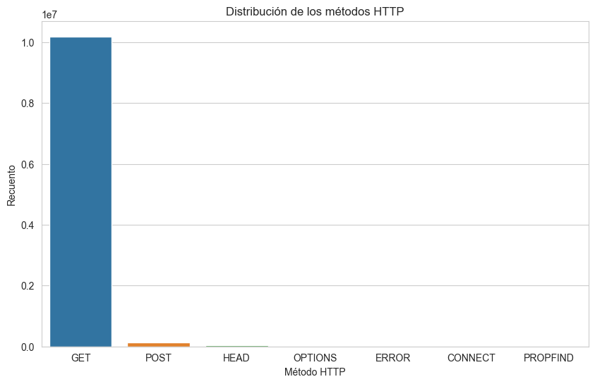

```python
# Muestra la distribución de los métodos HTTP
plt.figure(figsize=(10, 6))
sns.countplot(data=df_access_log, x='http_method')
plt.title('Distribución de los métodos HTTP')
plt.xlabel('Método HTTP')
plt.ylabel('Recuento')
plt.show()
```

También se aprecia que el método GET es el utilizado en la gran mayoría de las solicitudes realizadas al servidor HTTP.

#### Distribución del tamaño en bytes de las respuestas obtenidas.

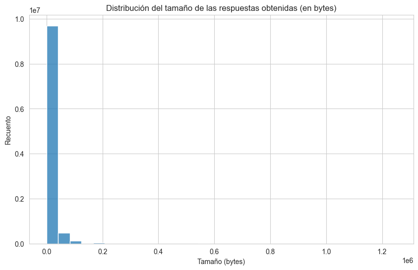

```python
# Muestra la distribución del tamaño de las solicitudes
plt.figure(figsize=(10, 6))
sns.histplot(df_access_log['size'], bins=30)
plt.title('Distribución del tamaño de las respuestas obtenidas (en bytes)')
plt.xlabel('Tamaño (bytes)')
plt.ylabel('Recuento')
plt.show()
```

```python
print(f"El tamaño medio de las solicitudes realizadas al servidor HTTP es de {round(df_access_log['size'].mean(), 2)} bytes.\nEl mínimo es de {round(df_access_log['size'].min(), 2)} y el máximo es de {round(df_access_log['size'].max(), 2)} bytes.")
```

```
El tamaño medio de las solicitudes realizadas al servidor HTTP es de 12433.38 bytes.
El mínimo es de 0 y el máximo es de 1249490 bytes.
```

El máximo de 1249490 bytes indica que existen valores atípicos y el mínimo de 0 resulta llamativo. Vamos a comprobar si existen clientes cuya suma de la columna size sea cero.

#### Clientes que no están descargando información del servidor HTTP

Para identificar estas máquinas, agruparemos los datos por client_ip y después calcularemos la suma de la columna size para cada grupo. Por último, filtraremos los grupos donde la suma sea cero.

```python
# Agrupa por "client_ip" y calcula la suma de la columna "size" para cada grupo
grouped_df = df_access_log.groupby('client_ip')['size'].sum().reset_index()
# Filtra los clientes donde la suma de "size" sea 0
clients_with_zero_size = grouped_df[grouped_df['size'] == 0]

clients_with_zero_size
```

|  | client_ip | size |
| --- | --- | --- |
| 269 | 103.216.160.87 | 0 |
| 291 | 103.255.239.98 | 0 |
| 316 | 103.28.133.39 | 0 |
| 327 | 103.42.1.159 | 0 |
| 1112 | 104.248.18.146 | 0 |
| ... | ... | ... |
| 257600 | 95.64.78.145 | 0 |
| 257643 | 95.64.82.212 | 0 |
| 257717 | 95.64.9.123 | 0 |
| 257833 | 95.80.130.68 | 0 |
| 258070 | 95.81.89.244 | 0 |

2474 rows × 2 columns

Hemos encontrado 2474 cajeros donde la suma de la columna size es igual a cero. Esto significa que **hay cajeros que están interactuando con el servidor HTTP pero no están descargando información**. Ahora, filtraremos los registros en el dataframe original (df_access_log) que correspondan a estos clientes y luego analizaremos las columnas response_code y http_method para ver si hay algún patrón o anomalía que pueda explicar esa suma de valores de size igual a cero.

```python
# Filtra los registros que correspondan a clientes con suma de size igual a cero en df_access_log
df_filtered = df_access_log[df_access_log['client_ip'].isin(clients_with_zero_size['client_ip'])]

# Analiza las columnas "response_code" y "http_method" para estos clientes
response_code_analysis = df_filtered['response_code'].value_counts().reset_index()
response_code_analysis.columns = ['response_code', 'count']
http_method_analysis = df_filtered['http_method'].value_counts().reset_index()
http_method_analysis.columns = ['http_method', 'count']

response_code_analysis, http_method_analysis
```

```
(   response_code  count
 0            200   1975
 1            499   1471
 2            302    692
 3            304    389
 4            301    130
 5            404    114
 6            408      5
 7            400      1,
   http_method  count
 0         GET   4463
 1        HEAD    314)
```

Se trata de 4777 registros. En su mayoría, el método HTTP que se usó fue GET, aunque existen 314 ocasiones en las que se usó el método HEAD. Este último método se utiliza para recuperar los encabezados de un recurso sin necesidad de descargar el contenido del mismo. Por tanto, su uso podría explicar algunas de las instancias donde size es igual a cero (solo se recuperan los encabezados del recurso, no el cuerpo).

Por otro lado, La presencia de un gran número de códigos de respuesta 499 y algunos 408 indica que hay conexiones que se cierran (por parte del cliente) antes de que se complete la transferencia de datos. Esto explicaría que se obtenga un size igual a cero y podría deberse al hecho de abortar la acción que estuviera en curso.

Sin embargo, el código de respuesta más común es 200, con 1975 ocurrencias. Este código generalmente indica una solicitud exitosa, lo cual no cuadra con un tamaño de respuesta igual a cero. Se debe informar de estas anomalías a nuestro cliente para que estudie estos casos convenientemente.

Ahora, vamos a observar cómo se distribuyen los cajeros reparados y no reparados dentro de este subconjunto de clientes cuya suma del tamaño de respuesta es igual a cero.

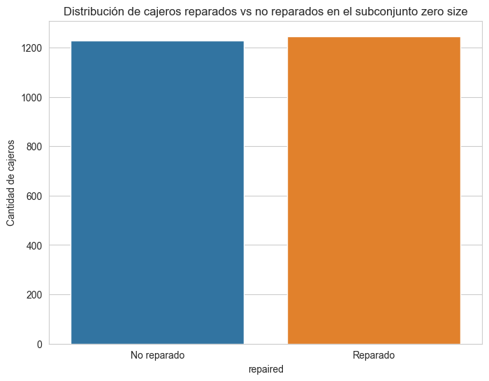

```python
# Filtra los registros que correspondan a clientes con suma de size igual a cero en df_client_reparations
client_reparations_zero_size = df_client_reparations[df_client_reparations['client_ip'].isin(clients_with_zero_size['client_ip'])]

# Muestra la distribución de cajeros reparados vs no reparados en el subconjunto zero size
plt.figure(figsize=(8, 6))
sns.countplot(data=client_reparations_zero_size, x='repaired')
plt.title('Distribución de cajeros reparados vs no reparados en el subconjunto zero size')
plt.ylabel('Cantidad de cajeros')
plt.xticks([0, 1], ['No reparado', 'Reparado'])
plt.show()
```

Se observa que la distribución es equitativa, por lo que esta circunstancia no está influyendo, a priori, en el hecho de que la máquina sea reparada o no.

Veamos también cómo se distribuyen este grupo de cajeros por provincias.

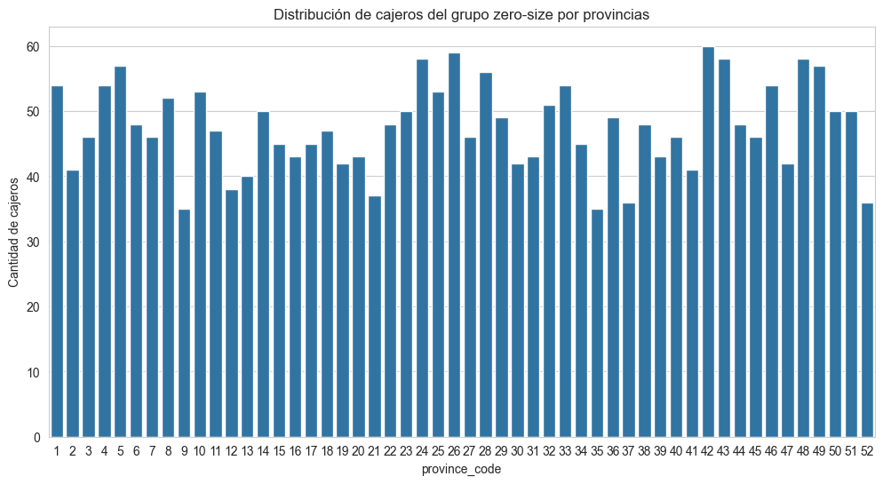

```python
# Muestra la distribución de cajeros del grupo zero-size en el subconjunto zero size
plt.figure(figsize=(12, 6))
default_blue = sns.color_palette()[0]
sns.countplot(data=client_reparations_zero_size, x='province_code', color=default_blue)
plt.title('Distribución de cajeros del grupo zero-size por provincias')
plt.ylabel('Cantidad de cajeros')
plt.show()
```

#### Distribución temporal de las solicitudes HTTP

Ahora, continuamos con nuestro análisis. En esta ocasión, vamos a mostrar cómo se distribuyen en el tiempo las solicitudes al servidor HTTP.

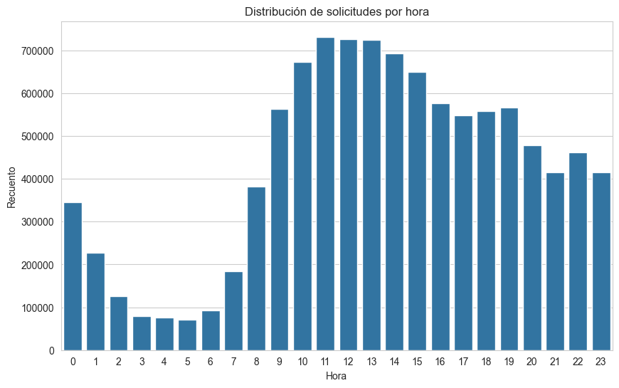

```python
# Convierte la columna de marca de tiempo al formato de fecha y hora
df_access_log['timestamp'] = pd.to_datetime(df_access_log['timestamp'])

# Extrae la hora
df_access_log['hour'] = df_access_log['timestamp'].dt.hour

# Muestra la distribución de solicitudes por hora
plt.figure(figsize=(10, 6))
sns.countplot(data=df_access_log, x='hour', color=default_blue)
plt.title('Distribución de solicitudes por hora')
plt.xlabel('Hora')
plt.ylabel('Recuento')
plt.show()
```

En el gráfico superior se observa que la mayor cantidad de solicitudes HTTP se realizan entre las 8 y las 1h, siendo la madrugada (como cabía esperar a priori) el tramo horario en que se procuce menos tráfico.

### DataFrame df_provinces_xlsx

A continuación, vamos a extraer información del dataframe df_provinces_xlsx.

#### Número de técnicos por provincia

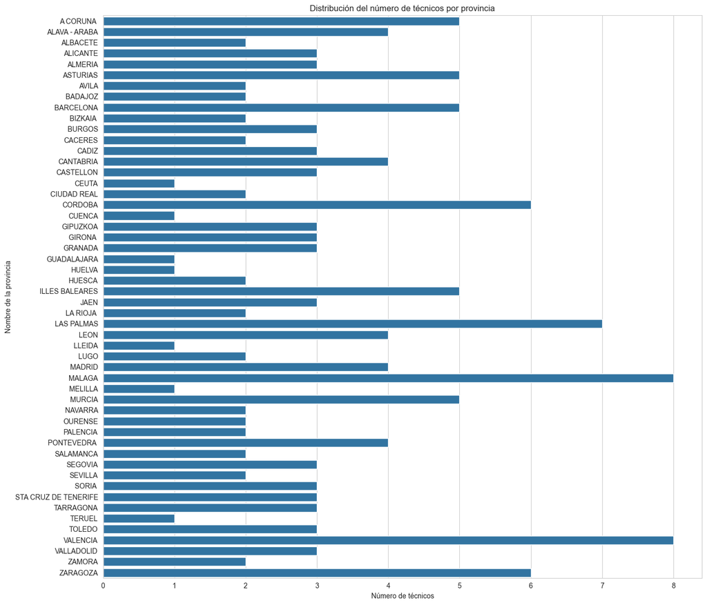

```python
# Muestra la distribución del número de técnicos por provincia
fig, axs = plt.subplots(1, 1, figsize=(14, 12))
sns.barplot(data=df_provinces_xlsx, y='province_name', x='techs_num_per_prov', ax=axs, color=default_blue)
axs.set_title('Distribución del número de técnicos por provincia')
axs.set_ylabel('Nombre de la provincia')
axs.set_xlabel('Número de técnicos')
plt.tight_layout()
plt.show()
```

```python
print(f"El número medio de técnicos por provincia es de {round(df_provinces_xlsx['techs_num_per_prov'].mean())}.\nEl mínimo es de {df_provinces_xlsx['techs_num_per_prov'].min()} y el máximo es de {df_provinces_xlsx['techs_num_per_prov'].max()} técnicos.")
```

```
El número medio de técnicos por provincia es de 3.
El mínimo es de 1 y el máximo es de 8 técnicos.
```

Se observa que las provincias de Málaga y Valencia son las que cuentan con un mayor número de técnicos. En el extremo opuesto tenemos a Ceuta, Cuenca, Guadalajara, Huelva, Lleida, Melilla y Teruel, en las que presta servicio un único técnico. La media es de tres técnicos por provincia.

#### Promedio cajeros/técnico por provincia

Ahora, vamos a comprobar si la cantidad de técnicos por provincia está proporcionada al número de cajeros que existen en ella.

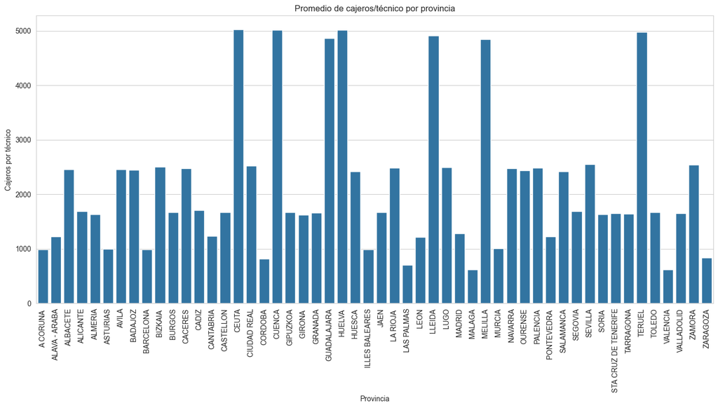

```python
# Cuenta el número de cajeros por provincia en el dataframe df_client_reparations
atms_per_province = df_client_reparations.groupby('province_code').size().reset_index(name='num_atms')
# Combina con el dataframe df_provinces_xlsx
combined_df = pd.merge(df_provinces_xlsx, atms_per_province, on='province_code')
# Calcula la proporción
combined_df['atms_per_tech'] = combined_df['num_atms'] / combined_df['techs_num_per_prov']

# Muestra el promedio de cajeros que mantiene cada técnico en las distintas provincias (etiquetas rotadas)
plt.figure(figsize=(14, 8))
sns.barplot(data=combined_df, x='province_name', y='atms_per_tech', color=default_blue)
plt.title('Promedio de cajeros/técnico por provincia')
plt.xlabel('Provincia')
plt.ylabel('Cajeros por técnico')
plt.xticks(rotation=90)
plt.tight_layout()
plt.show()
```

```python
print(f"El número medio de cajeros que debe mantener cada técnico es de {round(combined_df['atms_per_tech'].mean(), 2)}.\nEl mínimo es de {combined_df['atms_per_tech'].min()} y el máximo es de {combined_df['atms_per_tech'].max()} cajeros/técnico.")
```

```
El número medio de cajeros que debe mantener cada técnico es de 2146.13.
El mínimo es de 620.75 y el máximo es de 5026.0 cajeros/técnico.
```

En el gráfico superior se observa que un técnico que opere en las provincias de Ceuta, Cuenca, Guadalajara, Huelva, Lleida, Melilla o Teruel mantiene un promedio de unos cinco mil cajeros, mientras que un técnico de Córdoba, Las Palmas, Málaga o Valencia debe mantener un número de cajeros muy inferior (menos de 1000 máquinas). Si obviamos el hecho de que es imposible que un técnico pueda atender tal cantidad de cajeros y aceptamos que los equipos están bien dimensionados en general, podemos deducir que los grupos de técnicos de las provincia de Valencia o Málaga podrían estar sobredimensionados. Sin embargo, en Ceuta, Cuenca o Huelva parece ocurrir lo contrario. Debería analizarse esta desproporción y determinar en qué manera está afectando o no al servicio para contemplar un posible reajuste en la plantilla del personal técnico.

### DataFrame df_status_db

Ahora, continuaremos el estudio con el dataframe df_status_db y analizaremos qué eventos son los que más se producen, en qué provincias, etc.

#### Frecuencia de cada tipo de evento

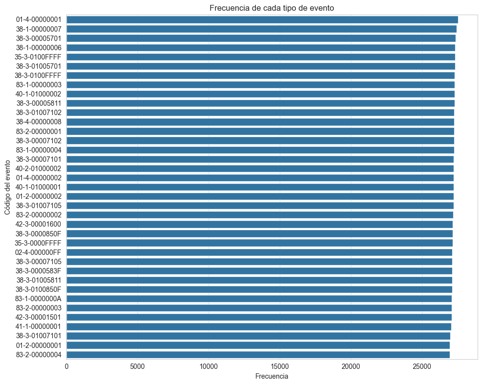

```python
# Calcular la frecuencia de cada tipo de evento
event_frequency = df_status_db['event_code'].value_counts().sort_values(ascending=False)

# Crear un gráfico de barras para mostrar la frecuencia de cada tipo de evento
fig, ax = plt.subplots(figsize=(10, 8))
sns.countplot(data=df_status_db, y='event_code', ax=ax, order=event_frequency.index, color=default_blue)
ax.set_title('Frecuencia de cada tipo de evento')
ax.set_xlabel('Frecuencia')
ax.set_ylabel('Código del evento')
plt.tight_layout()
plt.show()
```

Resulta curioso que las frecuencias de los distintos tipos de eventos sean todas tan parecidas. De hecho, no hay mucha diferencia entre las frecuencias mínima y máxima, como puede observarse a continuación. Esta falta de variabilidad podría dificultar la construcción de un modelo predictivo.

```python
# Contar la frecuencia de cada código de evento
event_frequencies = df_status_db['event_code'].value_counts().reset_index()
event_frequencies.columns = ['event_code', 'frequency']

# Calcular el mínimo, promedio y máximo
min_frequency = event_frequencies['frequency'].min()
avg_frequency = round(event_frequencies['frequency'].mean(), 2)
max_frequency = event_frequencies['frequency'].max()

print(f"El número medio de eventos de cada tipo es {avg_frequency}.\nEl mínimo es de {min_frequency} y el máximo es de {max_frequency} eventos de cada tipo.")
```

```
El número medio de eventos de cada tipo es 27203.95.
El mínimo es de 26949 y el máximo es de 27525 eventos de cada tipo.
```

También se observa que el evento que más se repite es el 01-4-00000001.

#### Top5 eventos más frecuentes

A continuación, se muestra un listado con los cinco eventos que más se repiten y sus descripciones.

```python
# Obtiene los códigos de los cinco eventos más frecuentes
top5_event_codes = event_frequency.nlargest(5).reset_index()['event_code'].tolist()

# Filtra las descripciones de estos eventos
top5_event_descriptions = df_manual_status_pdf[df_manual_status_pdf['event_code'].isin(top5_event_codes)]
# Reordena el DataFrame filtrado según el orden en top5_event_codes
top5_event_descriptions = top5_event_descriptions.set_index('event_code').loc[top5_event_codes].reset_index()

# Muestra las descripciones
print(top5_event_descriptions)
```

```
      event_code                                event_description
0  01-4-00000001                  Error de sistema en el arranque
1  38-1-00000007  El service provider ha arrancado correctamente.
2  38-3-00005701                                    Media Removal
3  38-1-00000006              El error anterior ha sido recupeado
4  35-3-0100FFFF             (TSRPR) Error hardware indeterminado
```

El primer y último evento de este listado corresponden a errores que deberían ser analizados con detenimiento. El primero apunta a un error de sistema en el arranque y el último a un error de hardware indeterminado en la unidad de recibos TSRPR. Sería interesante conocer qué está causando estos errores para poner en marcha una campaña de actuación sobre los componentes afectados y corregir la situación. En este caso, se trata de errores que están impactando a nivel global en una gran cantidad de máquinas, por lo que podrían deberse a un defecto de fabricación en el hardware (en el caso de la impresora de recibos) o un problema de diseño en el software (en el caso del error de sistema en el arranque).

En el próximo apartado, dentro del proceso de ingeniería de características, podríamos determinar cuáles de los eventos que producen los cajeros son errores y cuáles no. Esto también nos permitiría poner en marcha campañas locales encaminadas a corregir los errores que se produzcan con más frecuencia en cada provincia. En ese caso, ya no se trataría de problemas globales sino locales y podrían ser debidos a causas ambientales (temperatura, humedad...) o a un mantenimiento deficiente por parte de un equipo técnico concreto al que se debería formar adecuadamente en las labores de mantenimiento que se detecte que no se están haciendo correctamente.

## Ingeniería de características. Creación de nuevas variables.

En este apartado, vamos a crear nuevos atributos a partir de los existentes con un doble objetivo: por un lado, añadir información que nos permita realizar un análisis exploratorio más profundo; por otro, estas nuevas características podrían contribuir a la mejora del rendimiento del modelo predictivo que pretendemos construir. Para ello, crearemos copias de estos tres dataframes: df_client_reparations, df_provinces_xlsx y df_manual_status_pdf. Las copias se llamarán clients_plus, provinces_plus y status_manual_plus, respectivamente, y se irán enriqueciendo poco a poco con nuevas columnas en las próximas celdas de código.

```python
# Recuperar dataframes guardados. Copias a partir de los datos limpios
import pandas as pd
pd.set_option('display.max_columns', None)

df_access_log = pd.read_csv('clean_data/access_log.csv')
df_status_db = pd.read_csv('clean_data/status_db.csv')

clients_plus = pd.read_csv('clean_data/client_reparations.csv')
provinces_plus = pd.read_csv('clean_data/provinces.csv')
status_manual_plus = pd.read_csv('clean_data/status_manual.csv')
status_db_plus = df_status_db.copy()
```

### Nuevas variables basadas en el agrupamiento geográfico

#### Información geoespacial de las provincias de España

En primer lugar, vamos a añadir información geoespacial al dataframe provinces_plus. De esta forma, podremos dibujar posteriormente el mapa de España, sobre el que trazaremos las líneas correspondientes a los límites provinciales. Para ello, usaremos una de las principales bibliotecas para trabajar con datos geoespaciales en Python: **geopandas**. En cuanto a las formas poligonales correspondientes a cada provincia, las hemos obtenido del [Centro de Descargas del CNIG (IGN)](https://centrodedescargas.cnig.es/CentroDescargas/catalogo.do?Serie=CAANE) en formato **ESRI Shapefile** y vamos a procesarlas con ayuda de la biblioteca **shapely**. En este archivo shp también se especifica la comunidad autónoma a la que pertenece cada provincia.

```python
import geopandas as gpd
from shapely.geometry import Polygon

# Carga el shapefile
provinces_map = gpd.read_file('shape_files/Second-level Administrative Divisions Spain 2015/ESP_adm2.shp')
provinces_map
# Filtra el dataframe provinces_map, conservando solo las columnas 'ID_1', 'CCA_2' y 'geometry'
provinces_map = provinces_map[['ID_1', 'CCA_2', 'geometry']]
# Elimina estos registros:
# el Condado de Treviño (enclave burgalés en la provincia de Álava),
# Petilla de Aragón (enclave navarro en la provincia de Zaragoza),
# Sajuela y El Ternero (enclaves burgaleses en la provincia de La Rioja)
provinces_map = provinces_map.drop([10, 48, 51])

# Renombra las columnas ID_1 a community_code y CCA_2 a province_code
provinces_map = provinces_map.rename(columns={'ID_1':'community_code', 'CCA_2': 'province_code'})

# Extrae los centroides de los polígonos de las provincias
provinces_map['centroid'] = provinces_map['geometry'].centroid
# Extrae las coordenadas de los centroides y los asignamos a las nuevas columnas
provinces_map['lon_prov'] = provinces_map['centroid'].x
provinces_map['lat_prov'] = provinces_map['centroid'].y

# Elimina la columna 'centroid'
provinces_map = provinces_map.drop(columns=['centroid'])

# Convierte los códigos provincia (province_code) a entero (01 -> 1)
provinces_map['province_code'] = pd.to_numeric(provinces_map['province_code'])

# Combina provinces_map y provinces_plus por 'province_code'
provinces_plus = pd.merge(provinces_map, provinces_plus, how='right', on='province_code')

# Reordena las columnas del dataframe
provinces_plus = provinces_plus[['province_code', 'province_name', 'community_code', 'geometry', 'lat_prov', 'lon_prov', 'techs_num_per_prov']]

# Cambia el tipo de 'province_code' a entero
provinces_plus['province_code'] = provinces_plus['province_code'].astype(int)

# Establece el CRS original
provinces_plus.crs = "EPSG:4326"
# Cambia la proyección del GeoDataFrame a EPSG:3395 (Mercator)
provinces_plus = provinces_plus.to_crs(epsg=3395)

provinces_plus
```

|  | province_code | province_name | community_code | geometry | lat_prov | lon_prov | techs_num_per_prov |
| --- | --- | --- | --- | --- | --- | --- | --- |
| 0 | 15 | A CORUNA | 12 | MULTIPOLYGON (((-1003560.641 5205439.072, -100... | 43.125689 | -8.464641 | 5 |
| 1 | 1 | ALAVA - ARABA | 16 | POLYGON ((-335312.682 5313224.264, -334708.537... | 42.835064 | -2.720437 | 4 |
| 2 | 2 | ALBACETE | 4 | POLYGON ((-165697.390 4754282.676, -165581.726... | 38.825522 | -1.980333 | 2 |
| 3 | 3 | ALICANTE | 10 | MULTIPOLYGON (((-50882.245 4575943.131, -50882... | 38.478788 | -0.568252 | 3 |
| 4 | 4 | ALMERIA | 1 | MULTIPOLYGON (((-337313.527 4267649.609, -3373... | 37.195992 | -2.344777 | 3 |
| 5 | 33 | ASTURIAS | 17 | MULTIPOLYGON (((-509271.202 5343708.669, -5092... | 43.292319 | -5.992997 | 5 |
| 6 | 5 | AVILA | 5 | POLYGON ((-557420.426 5008128.174, -557080.918... | 40.571045 | -4.945356 | 2 |
| 7 | 6 | BADAJOZ | 11 | POLYGON ((-519794.458 4755528.239, -520091.235... | 38.709735 | -6.141636 | 2 |
| 8 | 8 | BARCELONA | 6 | MULTIPOLYGON (((241888.002 5034329.855, 241888... | 41.731104 | 1.983586 | 5 |
| 9 | 48 | BIZKAIA | 16 | MULTIPOLYGON (((-277695.830 5338833.078, -2776... | 43.241462 | -2.849766 | 2 |
| 10 | 9 | BURGOS | 5 | MULTIPOLYGON (((-472548.890 5242861.434, -4732... | 42.368714 | -3.585727 | 3 |
| 11 | 10 | CACERES | 11 | POLYGON ((-693648.674 4909167.425, -692830.479... | 39.711895 | -6.160477 | 2 |
| 12 | 11 | CADIZ | 1 | MULTIPOLYGON (((-692360.816 4327841.955, -6923... | 36.554192 | -5.759945 | 3 |
| 13 | 39 | CANTABRIA | 3 | MULTIPOLYGON (((-365534.795 5313208.592, -3656... | 43.196968 | -4.031487 | 4 |
| 14 | 12 | CASTELLON | 10 | MULTIPOLYGON (((74754.047 4820535.494, 74754.0... | 40.241405 | -0.146640 | 3 |
| 15 | 51 | CEUTA | 7 | MULTIPOLYGON (((-478751.065 4162828.387, -4787... | 35.893297 | -5.341597 | 1 |
| 16 | 13 | CIUDAD REAL | 4 | MULTIPOLYGON (((-530749.954 4756162.852, -5305... | 38.925658 | -3.827965 | 2 |
| 17 | 14 | CORDOBA | 1 | MULTIPOLYGON (((-562000.703 4502162.623, -5617... | 37.992690 | -4.809142 | 6 |
| 18 | 16 | CUENCA | 4 | POLYGON ((-236073.586 4933160.331, -235010.580... | 39.896096 | -2.195505 | 1 |
| 19 | 20 | GIPUZKOA | 16 | POLYGON ((-199493.876 5342690.718, -199493.876... | 43.143581 | -2.194577 | 3 |
| 20 | 17 | GIRONA | 6 | MULTIPOLYGON (((354877.190 5111985.631, 354877... | 42.127631 | 2.673845 | 3 |
| 21 | 18 | GRANADA | 1 | POLYGON ((-283997.293 4564958.748, -283573.811... | 37.312509 | -3.267768 | 3 |
| 22 | 19 | GUADALAJARA | 4 | MULTIPOLYGON (((-374498.257 4930830.049, -3747... | 40.813493 | -2.623720 | 1 |
| 23 | 21 | HUELVA | 1 | MULTIPOLYGON (((-761033.382 4429427.918, -7610... | 37.578828 | -6.828427 | 1 |
| 24 | 22 | HUESCA | 2 | POLYGON ((-83023.969 5270984.737, -82831.941 5... | 42.202849 | -0.073028 | 2 |
| 25 | 7 | ILLES BALEARES | 13 | MULTIPOLYGON (((158738.369 4663065.878, 158738... | 39.572706 | 2.910202 | 5 |
| 26 | 23 | JAEN | 1 | POLYGON ((-303680.359 4625389.875, -301647.771... | 38.016552 | -3.441539 | 3 |
| 27 | 26 | LA RIOJA | 15 | POLYGON ((-334481.668 5229024.331, -333409.002... | 42.274860 | -2.516893 | 2 |
| 28 | 35 | LAS PALMAS | 14 | MULTIPOLYGON (((-1710284.984 3228029.921, -171... | 28.367759 | -14.544932 | 7 |
| 29 | 24 | LEON | 5 | POLYGON ((-539819.155 5309707.359, -540082.969... | 42.619921 | -5.839721 | 4 |
| 30 | 25 | LLEIDA | 6 | MULTIPOLYGON (((190547.360 5116908.718, 190947... | 42.043707 | 1.047649 | 1 |
| 31 | 27 | LUGO | 12 | MULTIPOLYGON (((-827892.426 5389752.080, -8278... | 43.011719 | -7.445992 | 2 |
| 32 | 28 | MADRID | 8 | MULTIPOLYGON (((-473826.503 4935032.210, -4739... | 40.495201 | -3.717006 | 4 |
| 33 | 29 | MALAGA | 1 | MULTIPOLYGON (((-491676.460 4373507.648, -4916... | 36.813976 | -4.725770 | 8 |
| 34 | 52 | MELILLA | 7 | MULTIPOLYGON (((-271665.877 4164221.746, -2716... | 35.288565 | -2.913185 | 1 |
| 35 | 30 | MURCIA | 18 | MULTIPOLYGON (((-172189.096 4470436.450, -1721... | 38.002016 | -1.485118 | 5 |
| 36 | 31 | NAVARRA | 9 | POLYGON ((-184262.471 5330340.449, -183062.012... | 42.667549 | -1.647658 | 2 |
| 37 | 32 | OURENSE | 12 | POLYGON ((-882523.244 5219116.485, -881346.220... | 42.196371 | -7.592306 | 2 |
| 38 | 34 | PALENCIA | 5 | MULTIPOLYGON (((-447977.146 5144484.876, -4488... | 42.371755 | -4.535664 | 2 |
| 39 | 36 | PONTEVEDRA | 12 | MULTIPOLYGON (((-986615.508 5154440.124, -9866... | 42.435264 | -8.461421 | 4 |
| 40 | 37 | SALAMANCA | 5 | POLYGON ((-721063.557 5026650.862, -719705.102... | 40.804945 | -6.065299 | 2 |
| 41 | 40 | SEGOVIA | 5 | POLYGON ((-432663.783 5063453.956, -432554.144... | 41.171073 | -4.054292 | 3 |
| 42 | 41 | SEVILLA | 1 | POLYGON ((-637093.129 4580226.880, -636147.009... | 37.435707 | -5.682605 | 2 |
| 43 | 42 | SORIA | 5 | POLYGON ((-261392.847 5154300.318, -260926.767... | 41.620757 | -2.588668 | 3 |
| 44 | 38 | STA CRUZ DE TENERIFE | 14 | MULTIPOLYGON (((-1995726.645 3210066.784, -199... | 28.303038 | -17.059261 | 3 |
| 45 | 43 | TARRAGONA | 6 | MULTIPOLYGON (((81216.917 4952132.316, 81216.9... | 41.087598 | 0.817982 | 3 |
| 46 | 44 | TERUEL | 2 | POLYGON ((-62213.013 5036506.712, -61294.515 5... | 40.661299 | -0.815463 | 1 |
| 47 | 45 | TOLEDO | 4 | POLYGON ((-485067.577 4877746.659, -483695.001... | 39.793768 | -4.147936 | 3 |
| 48 | 46 | VALENCIA | 10 | MULTIPOLYGON (((-36503.555 4757008.335, -36503... | 39.370326 | -0.800909 | 8 |
| 49 | 47 | VALLADOLID | 5 | MULTIPOLYGON (((-607195.157 5138451.836, -6054... | 41.634139 | -4.847080 | 3 |
| 50 | 49 | ZAMORA | 5 | POLYGON ((-753167.534 5169095.310, -752402.898... | 41.727148 | -5.980454 | 2 |
| 51 | 50 | ZARAGOZA | 2 | POLYGON ((-99834.993 5242818.806, -100945.964 ... | 41.620426 | -1.064602 | 6 |

#### Comunidades autónomas en España

También añadiremos la información relativa a las comunidades autónomas, ya que en la organización territorial de las empresas de mantenimiento, suele nombrarse un coordinador para cada comunidad. Esta persona es la responsable de asignar y supervisar el trabajo de los equipos técnicos que operan en las provincias de su comunidad. Adicionalmente, por encima de los coordinadores, existe un jefe de departamento que necesita conocer la información agrupada por comunidades autónomas para poder valorar la calidad del trabajo de cada coordinador.

A la hora de confeccionar los mapas por comunidades autónomas necesitaremos conocer sus formas poligonales. Al igual que hicimos con las provincias, también las hemos obtenido en formato ESRI Shapefile del [Centro de Descargas del CNIG (IGN)](https://centrodedescargas.cnig.es/CentroDescargas/catalogo.do?Serie=CAANE).

```python
# Carga el shapefile
communities = gpd.read_file('shape_files/First-level Administrative Divisions Spain 2015/ESP_adm1.shp')

# Renombra la columna ID_1 a community_code
communities = communities.rename(columns={'ID_1': 'community_code'})
# Renombra la columna NAME_1 a community_name
communities = communities.rename(columns={'NAME_1': 'community_name'})

# Identifica el CRS actual
print("CRS actual:", communities.crs)
# Transforma a un CRS proyectado
communities = communities.to_crs(epsg=3395)
# Calcula los centroides en el nuevo CRS
communities['centroid'] = communities['geometry'].centroid
# Extrae las coordenadas de los centroides
communities['lon_comm'] = communities['centroid'].x
communities['lat_comm'] = communities['centroid'].y

# Elimina las columnas innecesarias
communities = communities.drop(columns=['ID_0', 'ISO', 'centroid', 'NAME_0', 'CCA_1', 'HASC_1', 'CCN_1', 'TYPE_1', 'ENGTYPE_1', 'NL_NAME_1', 'VARNAME_1'])

communities
```

```
CRS actual: EPSG:4326
```

|  | community_code | community_name | geometry | lon_comm | lat_comm |
| --- | --- | --- | --- | --- | --- |
| 0 | 1 | Andalucía | MULTIPOLYGON (((-337313.527 4267649.609, -3373... | -5.090586e+05 | 4.478763e+06 |
| 1 | 2 | Aragón | POLYGON ((-83023.969 5270984.737, -82831.941 5... | -7.322572e+04 | 5.062768e+06 |
| 2 | 3 | Cantabria | MULTIPOLYGON (((-365534.795 5313208.592, -3656... | -4.487472e+05 | 5.312841e+06 |
| 3 | 4 | Castilla-La Mancha | MULTIPOLYGON (((-374498.257 4930830.049, -3747... | -3.343624e+05 | 4.779797e+06 |
| 4 | 5 | Castilla y León | MULTIPOLYGON (((-315086.701 5251347.834, -3146... | -5.321647e+05 | 5.097763e+06 |
| 5 | 6 | Cataluña | MULTIPOLYGON (((81216.917 4952132.316, 81216.9... | 1.704231e+05 | 5.103141e+06 |
| 6 | 7 | Ceuta y Melilla | MULTIPOLYGON (((-478751.065 4162828.387, -4787... | -5.191091e+05 | 4.237877e+06 |
| 7 | 8 | Comunidad de Madrid | MULTIPOLYGON (((-473826.503 4935032.210, -4739... | -4.137867e+05 | 4.910648e+06 |
| 8 | 9 | Comunidad Foral de Navarra | POLYGON ((-184262.471 5330340.449, -183062.012... | -1.833987e+05 | 5.232906e+06 |
| 9 | 10 | Comunidad Valenciana | MULTIPOLYGON (((-50882.245 4575943.131, -50882... | -6.155023e+04 | 4.753770e+06 |
| 10 | 11 | Extremadura | POLYGON ((-693648.674 4909167.425, -692830.479... | -6.846576e+05 | 4.723247e+06 |
| 11 | 12 | Galicia | MULTIPOLYGON (((-986615.508 5154440.124, -9866... | -8.806964e+05 | 5.246847e+06 |
| 12 | 13 | Islas Baleares | MULTIPOLYGON (((158738.369 4663065.878, 158738... | 3.242639e+05 | 4.777102e+06 |
| 13 | 14 | Islas Canarias | MULTIPOLYGON (((-1995726.645 3210066.784, -199... | -1.743774e+06 | 3.272231e+06 |
| 14 | 15 | La Rioja | POLYGON ((-334481.668 5229024.331, -333409.002... | -2.802540e+05 | 5.173608e+06 |
| 15 | 16 | País Vasco | MULTIPOLYGON (((-277695.830 5338833.078, -2776... | -2.913064e+05 | 5.289602e+06 |
| 16 | 17 | Principado de Asturias | MULTIPOLYGON (((-509271.202 5343708.669, -5092... | -6.671220e+05 | 5.327357e+06 |
| 17 | 18 | Región de Murcia | MULTIPOLYGON (((-172189.096 4470436.450, -1721... | -1.653078e+05 | 4.553673e+06 |

Añadimos la columna community_code al dataframe clients_plus para poder agrupar y realizar cálculos por comunidades autónomas cómodamente.

```python
# Realizar el merge seleccionando solo la columna 'community_code' de provinces_plus
clients_plus = pd.merge(clients_plus, provinces_plus[['province_code', 'community_code']], on='province_code', how='left')
# Reordena las columnas del dataframe
clients_plus = clients_plus[['client_ip', 'province_code', 'community_code', 'repaired']]
clients_plus
```

|  | client_ip | province_code | community_code | repaired |
| --- | --- | --- | --- | --- |
| 0 | 5.123.144.95 | 30 | 18 | 1 |
| 1 | 5.122.76.187 | 18 | 1 | 1 |
| 2 | 5.215.249.99 | 1 | 16 | 1 |
| 3 | 31.56.102.211 | 42 | 5 | 1 |
| 4 | 5.123.166.223 | 31 | 9 | 0 |
| ... | ... | ... | ... | ... |
| 258440 | 5.116.105.239 | 24 | 5 | 1 |
| 258441 | 95.80.131.30 | 34 | 5 | 0 |
| 258442 | 2.177.65.234 | 17 | 6 | 1 |
| 258443 | 5.119.39.232 | 2 | 4 | 0 |
| 258444 | 5.125.96.182 | 4 | 1 | 0 |

258445 rows × 4 columns

#### Número de técnicos por comunidad autónoma

Ahora, vamos a calcular el número de técnicos que presta servicio en cada comunidad autónoma a partir de la suma de los técnicos que operan en cada una de las provincia que componen una misma comunidad.

```python
# Agrupa el dataframe provinces_plus por community_code y suma techs_num_per_prov
grouped_provinces = provinces_plus.groupby('community_code')['techs_num_per_prov'].sum().reset_index()
# Renombra la columna para evitar conflictos al unirla con communities
grouped_provinces.rename(columns={'techs_num_per_prov': 'techs_num_per_comm'}, inplace=True)

# Une el dataframe communities con el dataframe agrupado
communities = pd.merge(communities, grouped_provinces, on='community_code', how='left')
communities
```

|  | community_code | community_name | geometry | lon_comm | lat_comm | techs_num_per_comm |
| --- | --- | --- | --- | --- | --- | --- |
| 0 | 1 | Andalucía | MULTIPOLYGON (((-337313.527 4267649.609, -3373... | -5.090586e+05 | 4.478763e+06 | 29 |
| 1 | 2 | Aragón | POLYGON ((-83023.969 5270984.737, -82831.941 5... | -7.322572e+04 | 5.062768e+06 | 9 |
| 2 | 3 | Cantabria | MULTIPOLYGON (((-365534.795 5313208.592, -3656... | -4.487472e+05 | 5.312841e+06 | 4 |
| 3 | 4 | Castilla-La Mancha | MULTIPOLYGON (((-374498.257 4930830.049, -3747... | -3.343624e+05 | 4.779797e+06 | 9 |
| 4 | 5 | Castilla y León | MULTIPOLYGON (((-315086.701 5251347.834, -3146... | -5.321647e+05 | 5.097763e+06 | 24 |
| 5 | 6 | Cataluña | MULTIPOLYGON (((81216.917 4952132.316, 81216.9... | 1.704231e+05 | 5.103141e+06 | 12 |
| 6 | 7 | Ceuta y Melilla | MULTIPOLYGON (((-478751.065 4162828.387, -4787... | -5.191091e+05 | 4.237877e+06 | 2 |
| 7 | 8 | Comunidad de Madrid | MULTIPOLYGON (((-473826.503 4935032.210, -4739... | -4.137867e+05 | 4.910648e+06 | 4 |
| 8 | 9 | Comunidad Foral de Navarra | POLYGON ((-184262.471 5330340.449, -183062.012... | -1.833987e+05 | 5.232906e+06 | 2 |
| 9 | 10 | Comunidad Valenciana | MULTIPOLYGON (((-50882.245 4575943.131, -50882... | -6.155023e+04 | 4.753770e+06 | 14 |
| 10 | 11 | Extremadura | POLYGON ((-693648.674 4909167.425, -692830.479... | -6.846576e+05 | 4.723247e+06 | 4 |
| 11 | 12 | Galicia | MULTIPOLYGON (((-986615.508 5154440.124, -9866... | -8.806964e+05 | 5.246847e+06 | 13 |
| 12 | 13 | Islas Baleares | MULTIPOLYGON (((158738.369 4663065.878, 158738... | 3.242639e+05 | 4.777102e+06 | 5 |
| 13 | 14 | Islas Canarias | MULTIPOLYGON (((-1995726.645 3210066.784, -199... | -1.743774e+06 | 3.272231e+06 | 10 |
| 14 | 15 | La Rioja | POLYGON ((-334481.668 5229024.331, -333409.002... | -2.802540e+05 | 5.173608e+06 | 2 |
| 15 | 16 | País Vasco | MULTIPOLYGON (((-277695.830 5338833.078, -2776... | -2.913064e+05 | 5.289602e+06 | 9 |
| 16 | 17 | Principado de Asturias | MULTIPOLYGON (((-509271.202 5343708.669, -5092... | -6.671220e+05 | 5.327357e+06 | 5 |
| 17 | 18 | Región de Murcia | MULTIPOLYGON (((-172189.096 4470436.450, -1721... | -1.653078e+05 | 4.553673e+06 | 5 |

#### Número de cajeros por provincia

Vamos a calcular el número de cajeros que hay en cada provincia.

```python
# Cuenta el número de cajeros automáticos por provincia
atms_count = clients_plus.groupby("province_code").size().reset_index(name="atms_num_per_prov")

# Combina el resultado con el dataframe provinces_plus
provinces_plus = pd.merge(provinces_plus, atms_count, on="province_code", how="left")
```

#### Relación entre el número de cajeros y técnicos por provincia

```python
# Calcula la razón cajeros-técnico por provincia
provinces_plus['atms_to_tech_ratio_per_prov'] = (provinces_plus['atms_num_per_prov'] / provinces_plus['techs_num_per_prov']).astype(int)

# Muestra la estructura del dataframe
print(provinces_plus.info())
provinces_plus
```

```
<class 'geopandas.geodataframe.GeoDataFrame'>
RangeIndex: 52 entries, 0 to 51
Data columns (total 9 columns):
 #   Column                       Non-Null Count  Dtype
---  ------                       --------------  -----
 0   province_code                52 non-null     int32
 1   province_name                52 non-null     object
 2   community_code               52 non-null     int64
 3   geometry                     52 non-null     geometry
 4   lat_prov                     52 non-null     float64
 5   lon_prov                     52 non-null     float64
 6   techs_num_per_prov           52 non-null     int64
 7   atms_num_per_prov            52 non-null     int64
 8   atms_to_tech_ratio_per_prov  52 non-null     int32
dtypes: float64(2), geometry(1), int32(2), int64(3), object(1)
memory usage: 3.4+ KB
None
```

|  | province_code | province_name | community_code | geometry | lat_prov | lon_prov | techs_num_per_prov | atms_num_per_prov | atms_to_tech_ratio_per_prov |
| --- | --- | --- | --- | --- | --- | --- | --- | --- | --- |
| 0 | 15 | A CORUNA | 12 | MULTIPOLYGON (((-1003560.641 5205439.072, -100... | 43.125689 | -8.464641 | 5 | 4955 | 991 |
| 1 | 1 | ALAVA - ARABA | 16 | POLYGON ((-335312.682 5313224.264, -334708.537... | 42.835064 | -2.720437 | 4 | 4914 | 1228 |
| 2 | 2 | ALBACETE | 4 | POLYGON ((-165697.390 4754282.676, -165581.726... | 38.825522 | -1.980333 | 2 | 4916 | 2458 |
| 3 | 3 | ALICANTE | 10 | MULTIPOLYGON (((-50882.245 4575943.131, -50882... | 38.478788 | -0.568252 | 3 | 5084 | 1694 |
| 4 | 4 | ALMERIA | 1 | MULTIPOLYGON (((-337313.527 4267649.609, -3373... | 37.195992 | -2.344777 | 3 | 4914 | 1638 |
| 5 | 33 | ASTURIAS | 17 | MULTIPOLYGON (((-509271.202 5343708.669, -5092... | 43.292319 | -5.992997 | 5 | 4991 | 998 |
| 6 | 5 | AVILA | 5 | POLYGON ((-557420.426 5008128.174, -557080.918... | 40.571045 | -4.945356 | 2 | 4923 | 2461 |
| 7 | 6 | BADAJOZ | 11 | POLYGON ((-519794.458 4755528.239, -520091.235... | 38.709735 | -6.141636 | 2 | 4899 | 2449 |
| 8 | 8 | BARCELONA | 6 | MULTIPOLYGON (((241888.002 5034329.855, 241888... | 41.731104 | 1.983586 | 5 | 4930 | 986 |
| 9 | 48 | BIZKAIA | 16 | MULTIPOLYGON (((-277695.830 5338833.078, -2776... | 43.241462 | -2.849766 | 2 | 5016 | 2508 |
| 10 | 9 | BURGOS | 5 | MULTIPOLYGON (((-472548.890 5242861.434, -4732... | 42.368714 | -3.585727 | 3 | 5007 | 1669 |
| 11 | 10 | CACERES | 11 | POLYGON ((-693648.674 4909167.425, -692830.479... | 39.711895 | -6.160477 | 2 | 4949 | 2474 |
| 12 | 11 | CADIZ | 1 | MULTIPOLYGON (((-692360.816 4327841.955, -6923... | 36.554192 | -5.759945 | 3 | 5136 | 1712 |
| 13 | 39 | CANTABRIA | 3 | MULTIPOLYGON (((-365534.795 5313208.592, -3656... | 43.196968 | -4.031487 | 4 | 4959 | 1239 |
| 14 | 12 | CASTELLON | 10 | MULTIPOLYGON (((74754.047 4820535.494, 74754.0... | 40.241405 | -0.146640 | 3 | 5009 | 1669 |
| 15 | 51 | CEUTA | 7 | MULTIPOLYGON (((-478751.065 4162828.387, -4787... | 35.893297 | -5.341597 | 1 | 5026 | 5026 |
| 16 | 13 | CIUDAD REAL | 4 | MULTIPOLYGON (((-530749.954 4756162.852, -5305... | 38.925658 | -3.827965 | 2 | 5054 | 2527 |
| 17 | 14 | CORDOBA | 1 | MULTIPOLYGON (((-562000.703 4502162.623, -5617... | 37.992690 | -4.809142 | 6 | 4933 | 822 |
| 18 | 16 | CUENCA | 4 | POLYGON ((-236073.586 4933160.331, -235010.580... | 39.896096 | -2.195505 | 1 | 5019 | 5019 |
| 19 | 20 | GIPUZKOA | 16 | POLYGON ((-199493.876 5342690.718, -199493.876... | 43.143581 | -2.194577 | 3 | 5003 | 1667 |
| 20 | 17 | GIRONA | 6 | MULTIPOLYGON (((354877.190 5111985.631, 354877... | 42.127631 | 2.673845 | 3 | 4883 | 1627 |
| 21 | 18 | GRANADA | 1 | POLYGON ((-283997.293 4564958.748, -283573.811... | 37.312509 | -3.267768 | 3 | 4986 | 1662 |
| 22 | 19 | GUADALAJARA | 4 | MULTIPOLYGON (((-374498.257 4930830.049, -3747... | 40.813493 | -2.623720 | 1 | 4869 | 4869 |
| 23 | 21 | HUELVA | 1 | MULTIPOLYGON (((-761033.382 4429427.918, -7610... | 37.578828 | -6.828427 | 1 | 5017 | 5017 |
| 24 | 22 | HUESCA | 2 | POLYGON ((-83023.969 5270984.737, -82831.941 5... | 42.202849 | -0.073028 | 2 | 4842 | 2421 |
| 25 | 7 | ILLES BALEARES | 13 | MULTIPOLYGON (((158738.369 4663065.878, 158738... | 39.572706 | 2.910202 | 5 | 4956 | 991 |
| 26 | 23 | JAEN | 1 | POLYGON ((-303680.359 4625389.875, -301647.771... | 38.016552 | -3.441539 | 3 | 5009 | 1669 |
| 27 | 26 | LA RIOJA | 15 | POLYGON ((-334481.668 5229024.331, -333409.002... | 42.274860 | -2.516893 | 2 | 4971 | 2485 |
| 28 | 35 | LAS PALMAS | 14 | MULTIPOLYGON (((-1710284.984 3228029.921, -171... | 28.367759 | -14.544932 | 7 | 4968 | 709 |
| 29 | 24 | LEON | 5 | POLYGON ((-539819.155 5309707.359, -540082.969... | 42.619921 | -5.839721 | 4 | 4859 | 1214 |
| 30 | 25 | LLEIDA | 6 | MULTIPOLYGON (((190547.360 5116908.718, 190947... | 42.043707 | 1.047649 | 1 | 4910 | 4910 |
| 31 | 27 | LUGO | 12 | MULTIPOLYGON (((-827892.426 5389752.080, -8278... | 43.011719 | -7.445992 | 2 | 4990 | 2495 |
| 32 | 28 | MADRID | 8 | MULTIPOLYGON (((-473826.503 4935032.210, -4739... | 40.495201 | -3.717006 | 4 | 5133 | 1283 |
| 33 | 29 | MALAGA | 1 | MULTIPOLYGON (((-491676.460 4373507.648, -4916... | 36.813976 | -4.725770 | 8 | 4981 | 622 |
| 34 | 52 | MELILLA | 7 | MULTIPOLYGON (((-271665.877 4164221.746, -2716... | 35.288565 | -2.913185 | 1 | 4848 | 4848 |
| 35 | 30 | MURCIA | 18 | MULTIPOLYGON (((-172189.096 4470436.450, -1721... | 38.002016 | -1.485118 | 5 | 5029 | 1005 |
| 36 | 31 | NAVARRA | 9 | POLYGON ((-184262.471 5330340.449, -183062.012... | 42.667549 | -1.647658 | 2 | 4958 | 2479 |
| 37 | 32 | OURENSE | 12 | POLYGON ((-882523.244 5219116.485, -881346.220... | 42.196371 | -7.592306 | 2 | 4873 | 2436 |
| 38 | 34 | PALENCIA | 5 | MULTIPOLYGON (((-447977.146 5144484.876, -4488... | 42.371755 | -4.535664 | 2 | 4968 | 2484 |
| 39 | 36 | PONTEVEDRA | 12 | MULTIPOLYGON (((-986615.508 5154440.124, -9866... | 42.435264 | -8.461421 | 4 | 4894 | 1223 |
| 40 | 37 | SALAMANCA | 5 | POLYGON ((-721063.557 5026650.862, -719705.102... | 40.804945 | -6.065299 | 2 | 4842 | 2421 |
| 41 | 40 | SEGOVIA | 5 | POLYGON ((-432663.783 5063453.956, -432554.144... | 41.171073 | -4.054292 | 3 | 5073 | 1691 |
| 42 | 41 | SEVILLA | 1 | POLYGON ((-637093.129 4580226.880, -636147.009... | 37.435707 | -5.682605 | 2 | 5099 | 2549 |
| 43 | 42 | SORIA | 5 | POLYGON ((-261392.847 5154300.318, -260926.767... | 41.620757 | -2.588668 | 3 | 4904 | 1634 |
| 44 | 38 | STA CRUZ DE TENERIFE | 14 | MULTIPOLYGON (((-1995726.645 3210066.784, -199... | 28.303038 | -17.059261 | 3 | 4950 | 1650 |
| 45 | 43 | TARRAGONA | 6 | MULTIPOLYGON (((81216.917 4952132.316, 81216.9... | 41.087598 | 0.817982 | 3 | 4942 | 1647 |
| 46 | 44 | TERUEL | 2 | POLYGON ((-62213.013 5036506.712, -61294.515 5... | 40.661299 | -0.815463 | 1 | 4982 | 4982 |
| 47 | 45 | TOLEDO | 4 | POLYGON ((-485067.577 4877746.659, -483695.001... | 39.793768 | -4.147936 | 3 | 5029 | 1676 |
| 48 | 46 | VALENCIA | 10 | MULTIPOLYGON (((-36503.555 4757008.335, -36503... | 39.370326 | -0.800909 | 8 | 4966 | 620 |
| 49 | 47 | VALLADOLID | 5 | MULTIPOLYGON (((-607195.157 5138451.836, -6054... | 41.634139 | -4.847080 | 3 | 4945 | 1648 |
| 50 | 49 | ZAMORA | 5 | POLYGON ((-753167.534 5169095.310, -752402.898... | 41.727148 | -5.980454 | 2 | 5082 | 2541 |
| 51 | 50 | ZARAGOZA | 2 | POLYGON ((-99834.993 5242818.806, -100945.964 ... | 41.620426 | -1.064602 | 6 | 5050 | 841 |

#### Número de cajeros por comunidad autónoma

Vamos a calcular el número de cajeros que hay en cada comunidad autónoma.

```python
# Agrupa el dataframe provinces_plus por community_code y sumamos atms_num_per_prov
grouped_provinces_atm = provinces_plus.groupby('community_code')['atms_num_per_prov'].sum().reset_index()
# Renombra la columna para evitar conflictos al unirla con communities
grouped_provinces_atm.rename(columns={'atms_num_per_prov': 'atms_num_per_comm'}, inplace=True)

# Une el dataframe communities con el dataframe agrupado de cajeros
communities = pd.merge(communities, grouped_provinces_atm, on='community_code', how='left')
```

#### Relación entre el número de cajeros y técnicos por comunidad autónoma

```python
# Calcula la razón cajeros-técnico por comunidad autónoma
communities['atms_to_tech_ratio_per_comm'] = (communities['atms_num_per_comm'] / communities['techs_num_per_comm']).astype(int)
communities
```

|  | community_code | community_name | geometry | lon_comm | lat_comm | techs_num_per_comm | atms_num_per_comm | atms_to_tech_ratio_per_comm |
| --- | --- | --- | --- | --- | --- | --- | --- | --- |
| 0 | 1 | Andalucía | MULTIPOLYGON (((-337313.527 4267649.609, -3373... | -5.090586e+05 | 4.478763e+06 | 29 | 40075 | 1381 |
| 1 | 2 | Aragón | POLYGON ((-83023.969 5270984.737, -82831.941 5... | -7.322572e+04 | 5.062768e+06 | 9 | 14874 | 1652 |
| 2 | 3 | Cantabria | MULTIPOLYGON (((-365534.795 5313208.592, -3656... | -4.487472e+05 | 5.312841e+06 | 4 | 4959 | 1239 |
| 3 | 4 | Castilla-La Mancha | MULTIPOLYGON (((-374498.257 4930830.049, -3747... | -3.343624e+05 | 4.779797e+06 | 9 | 24887 | 2765 |
| 4 | 5 | Castilla y León | MULTIPOLYGON (((-315086.701 5251347.834, -3146... | -5.321647e+05 | 5.097763e+06 | 24 | 44603 | 1858 |
| 5 | 6 | Cataluña | MULTIPOLYGON (((81216.917 4952132.316, 81216.9... | 1.704231e+05 | 5.103141e+06 | 12 | 19665 | 1638 |
| 6 | 7 | Ceuta y Melilla | MULTIPOLYGON (((-478751.065 4162828.387, -4787... | -5.191091e+05 | 4.237877e+06 | 2 | 9874 | 4937 |
| 7 | 8 | Comunidad de Madrid | MULTIPOLYGON (((-473826.503 4935032.210, -4739... | -4.137867e+05 | 4.910648e+06 | 4 | 5133 | 1283 |
| 8 | 9 | Comunidad Foral de Navarra | POLYGON ((-184262.471 5330340.449, -183062.012... | -1.833987e+05 | 5.232906e+06 | 2 | 4958 | 2479 |
| 9 | 10 | Comunidad Valenciana | MULTIPOLYGON (((-50882.245 4575943.131, -50882... | -6.155023e+04 | 4.753770e+06 | 14 | 15059 | 1075 |
| 10 | 11 | Extremadura | POLYGON ((-693648.674 4909167.425, -692830.479... | -6.846576e+05 | 4.723247e+06 | 4 | 9848 | 2462 |
| 11 | 12 | Galicia | MULTIPOLYGON (((-986615.508 5154440.124, -9866... | -8.806964e+05 | 5.246847e+06 | 13 | 19712 | 1516 |
| 12 | 13 | Islas Baleares | MULTIPOLYGON (((158738.369 4663065.878, 158738... | 3.242639e+05 | 4.777102e+06 | 5 | 4956 | 991 |
| 13 | 14 | Islas Canarias | MULTIPOLYGON (((-1995726.645 3210066.784, -199... | -1.743774e+06 | 3.272231e+06 | 10 | 9918 | 991 |
| 14 | 15 | La Rioja | POLYGON ((-334481.668 5229024.331, -333409.002... | -2.802540e+05 | 5.173608e+06 | 2 | 4971 | 2485 |
| 15 | 16 | País Vasco | MULTIPOLYGON (((-277695.830 5338833.078, -2776... | -2.913064e+05 | 5.289602e+06 | 9 | 14933 | 1659 |
| 16 | 17 | Principado de Asturias | MULTIPOLYGON (((-509271.202 5343708.669, -5092... | -6.671220e+05 | 5.327357e+06 | 5 | 4991 | 998 |
| 17 | 18 | Región de Murcia | MULTIPOLYGON (((-172189.096 4470436.450, -1721... | -1.653078e+05 | 4.553673e+06 | 5 | 5029 | 1005 |

### Nuevas variables en clients_plus extraídas de df_access_log

En este apartado, utilizaremos la información contenida en el dataframe df_access_log para añadir nuevos atributos al dataframe clients_plus.

#### Verifica que todos los cajeros estén interactuando con el servidor HTTP

En primer lugar, vamos a asegurarnos de que todos los cajeros estén interactuando con el servidor HTTP. Para ello, comprobaremos que todos los valores de la columna client_ip del dataframe clients_plus estén presentes en la columna del mismo nombre en df_access_log.

```python
clients_plus['client_ip'].isin(df_access_log['client_ip']).all()
```

```
True
```

Efectivamente, todos los cajeros están interactuando con el servidor HTTP.

Ahora, vamos a definir una función que nos facilite la tarea de calcular el valor más frecuente de una columna (por cajero, por provincia y por comunidad autónoma).

```python
def calculate_most_frequent_value(df, field_name):
    """
    Función para calcular el valor más frecuente en una columna de un dataframe
    (por máquina, provincia y comunidad autónoma).

    Parámetros:
    df (pandas.core.frame.DataFrame): el dataframe en cuestión.
    field_name (str): nombre del campo (columna) sobre el que se van a realizar los cálculos.

    Devuelve:
    pandas.core.frame.DataFrame: DataFrame con dos columnas que relaciona cada IP con su valor más frecuente.
    pandas.core.frame.DataFrame: DataFrame con dos columnas que relaciona cada provincia con su valor más frecuente.
    pandas.core.frame.DataFrame: DataFrame con dos columnas que relaciona cada comunidad autónoma con su valor más frecuente.
    """
    # Calcula la moda por máquina
    most_frequent_per_machine = df.groupby('client_ip')[field_name].apply(lambda x: x.mode()[0]).reset_index(name=f'most_frequent_{field_name}_per_atm')

    # Combina con el dataframe df_client para obtener los códigos de provincia y comunidad autónoma
    most_frequent_plus = most_frequent_per_machine.merge(clients_plus[['client_ip', 'province_code', 'community_code']], on='client_ip')
    # Calcula la moda por provincia
    most_frequent_per_province = most_frequent_plus.groupby('province_code')[f'most_frequent_{field_name}_per_atm'].apply(lambda x: x.mode()[0]).reset_index(name=f'most_frequent_{field_name}_per_prov')
    # Calcula la moda por comunidad autónoma
    most_frequent_per_community = most_frequent_plus.groupby('community_code')[f'most_frequent_{field_name}_per_atm'].apply(lambda x: x.mode()[0]).reset_index(name=f'most_frequent_{field_name}_per_comm')

    return most_frequent_per_machine, most_frequent_per_province, most_frequent_per_community
```

#### Hora de mayor actividad (cajeros/servidor HTTP)

A continuación, vamos a calcular la hora de mayor actividad entre los cajeros y el servidor HTTP; lo haremos por máquina, por provincia y por comunidad autónoma.

```python
# Convierte la columna timestamp a formato datetime
df_access_log['timestamp'] = pd.to_datetime(df_access_log['timestamp'])
# Extrae la hora desde el campo timestamp
df_access_log['hour'] = df_access_log['timestamp'].dt.hour
# También se extrae el minuto desde el campo timestamp
# (esta nueva característica no la usamos aún, sino que se utilizará para el nuevo modelo)
df_access_log['minute'] = df_access_log['timestamp'].dt.minute
# También se extrae el día desde el campo timestamp (tampoco lo usamos aún)
df_access_log['day'] = df_access_log['timestamp'].dt.day
```

```python
# Calcula la hora más activa en cada máquina, provincia y comunidad autónoma
most_active_hour_per_atm, most_active_hour_per_province, most_active_hour_per_community = calculate_most_frequent_value(df_access_log, 'hour')

# Combina las nuevas características con el dataframe client_plus
clients_plus = clients_plus.merge(most_active_hour_per_atm, on='client_ip')
provinces_plus = provinces_plus.merge(most_active_hour_per_province, on='province_code')
communities = communities.merge(most_active_hour_per_community, on='community_code')
```

```python
clients_plus
```

|  | client_ip | province_code | community_code | repaired | most_frequent_hour_per_atm |
| --- | --- | --- | --- | --- | --- |
| 0 | 5.123.144.95 | 30 | 18 | 1 | 23 |
| 1 | 5.122.76.187 | 18 | 1 | 1 | 9 |
| 2 | 5.215.249.99 | 1 | 16 | 1 | 9 |
| 3 | 31.56.102.211 | 42 | 5 | 1 | 17 |
| 4 | 5.123.166.223 | 31 | 9 | 0 | 21 |
| ... | ... | ... | ... | ... | ... |
| 258440 | 5.116.105.239 | 24 | 5 | 1 | 12 |
| 258441 | 95.80.131.30 | 34 | 5 | 0 | 0 |
| 258442 | 2.177.65.234 | 17 | 6 | 1 | 15 |
| 258443 | 5.119.39.232 | 2 | 4 | 0 | 2 |
| 258444 | 5.125.96.182 | 4 | 1 | 0 | 18 |

258445 rows × 5 columns

```python
clients_plus['most_frequent_hour_per_atm'].unique()
```

```
array([23,  9, 17, 21, 10, 20, 15, 22, 16, 19, 18, 14, 12,  1,  4, 13,  8,
       11,  0,  6,  5,  3,  2,  7])
```

```python
provinces_plus['most_frequent_hour_per_prov'].unique()
```

```
array([19, 14, 18, 13, 12, 15, 22, 20])
```

```python
communities['most_frequent_hour_per_comm'].unique()
```

```
array([19, 13, 22])
```

Se ha comprobado que el recuento por provincias o comunidades autónomas aporta información al estudio (se obtienen distintos valores).

#### Valor response_code más frecuente

```python
# Calcula el response_code más frecuente
most_frequent_response_code_per_atm, most_frequent_response_code_per_province, most_frequent_response_code_per_community = calculate_most_frequent_value(df_access_log, 'response_code')

# Combina las nuevas características con el dataframe client_plus
clients_plus = clients_plus.merge(most_frequent_response_code_per_atm, on='client_ip')
provinces_plus = provinces_plus.merge(most_frequent_response_code_per_province, on='province_code')
communities = communities.merge(most_frequent_response_code_per_community, on='community_code')
```

```python
clients_plus['most_frequent_response_code_per_atm'].unique()
```

```
array([200, 302, 404, 502, 499, 301, 304, 403, 500, 400, 408, 504],
      dtype=int64)
```

```python
provinces_plus['most_frequent_response_code_per_prov'].unique()
```

```
array([200], dtype=int64)
```

```python
communities['most_frequent_response_code_per_comm'].unique()
```

```
array([200], dtype=int64)
```

Se observa que cuando hacemos el recuento por provincias o comunidades autónomas, el código de estado 200 es el que se recibe con más frecuencia en todos los casos. Esto es lo que cabía esperar, ya que esta respuesta indica que la solicitud del cliente se ha procesado con éxito, pero no tiene sentido para nuestro estudio añadir columnas con todos sus valores iguales. En consecuencia, eliminamos la columna 'most_frequent_response_code_per_prov' en provinces_plus y 'most_frequent_response_code_per_comm' en communities.

```python
provinces_plus = provinces_plus.drop(columns=['most_frequent_response_code_per_prov'])
communities = communities.drop(columns=['most_frequent_response_code_per_comm'])
```

#### Valor http_method más frecuente

```python
# Calcula el http_method más frecuente
most_frequent_http_method_per_atm, most_frequent_http_method_per_province, most_frequent_http_method_per_community = calculate_most_frequent_value(df_access_log, 'http_method')

# Combina las nuevas características con el dataframe client_plus
clients_plus = clients_plus.merge(most_frequent_http_method_per_atm, on='client_ip')
provinces_plus = provinces_plus.merge(most_frequent_http_method_per_province, on='province_code')
communities = communities.merge(most_frequent_http_method_per_community, on='community_code')
```

```python
clients_plus['most_frequent_http_method_per_atm'].unique()
```

```
array(['GET', 'POST', 'HEAD', 'ERROR', 'CONNECT'], dtype=object)
```

```python
provinces_plus['most_frequent_http_method_per_prov'].unique()
```

```
array(['GET'], dtype=object)
```

```python
communities['most_frequent_http_method_per_comm'].unique()
```

```
array(['GET'], dtype=object)
```

Como ya ocurrió anteriormente con los códigos de respuesta, al hacer el recuento del método HTTP más utilizado por provincias o comunidades autónomas, el método GET es el más frecuente en todos los casos. En consecuencia, eliminamos la columna 'most_frequent_http_method_per_prov' en provinces_plus y 'most_frequent_http_method_per_comm' en communities.

```python
provinces_plus = provinces_plus.drop(columns=['most_frequent_http_method_per_prov'])
communities = communities.drop(columns=['most_frequent_http_method_per_comm'])
```

#### Volumen de tráfico entre cada máquina/provincia/comunidad y el servidor HTTP.

```python
# Agrupa por client_ip y suma el tamaño de los paquetes de la columna size
traffic_volume = df_access_log.groupby('client_ip')['size'].sum().reset_index()

# Renombra la columna para que tenga sentido en el contexto del dataframe clients_plus
traffic_volume.rename(columns={'size': 'traffic_volume'}, inplace=True)

# Combina con el dataframe clients_plus utilizando client_ip como clave
clients_plus = pd.merge(clients_plus, traffic_volume, on='client_ip', how='left')

# Rellena los valores nulos con 0, si es necesario
clients_plus['traffic_volume'].fillna(0, inplace=True)
```

```python
clients_plus
```

|  | client_ip | province_code | community_code | repaired | most_frequent_hour_per_atm | most_frequent_response_code_per_atm | most_frequent_http_method_per_atm | traffic_volume |
| --- | --- | --- | --- | --- | --- | --- | --- | --- |
| 0 | 5.123.144.95 | 30 | 18 | 1 | 23 | 200 | GET | 3975 |
| 1 | 5.122.76.187 | 18 | 1 | 1 | 9 | 200 | GET | 199104 |
| 2 | 5.215.249.99 | 1 | 16 | 1 | 9 | 200 | GET | 16217 |
| 3 | 31.56.102.211 | 42 | 5 | 1 | 17 | 200 | GET | 4328 |
| 4 | 5.123.166.223 | 31 | 9 | 0 | 21 | 200 | GET | 105857 |
| ... | ... | ... | ... | ... | ... | ... | ... | ... |
| 258440 | 5.116.105.239 | 24 | 5 | 1 | 12 | 200 | GET | 133 |
| 258441 | 95.80.131.30 | 34 | 5 | 0 | 0 | 200 | GET | 2021 |
| 258442 | 2.177.65.234 | 17 | 6 | 1 | 15 | 200 | GET | 528103 |
| 258443 | 5.119.39.232 | 2 | 4 | 0 | 2 | 200 | GET | 10371 |
| 258444 | 5.125.96.182 | 4 | 1 | 0 | 18 | 200 | GET | 10527 |

258445 rows × 8 columns

```python
# Agrupa clients_plus por province_code y suma el tamaño de los paquetes de la columna traffic_volume
traffic_volume = clients_plus.groupby('province_code')['traffic_volume'].sum().reset_index()

# Renombra la columna para que tenga sentido en el contexto del dataframe provinces_plus
traffic_volume.rename(columns={'traffic_volume': 'traffic_volume_per_prov'}, inplace=True)

# Combina con el dataframe provinces_plus utilizando province_code como clave
provinces_plus = pd.merge(provinces_plus, traffic_volume, on='province_code', how='left')

# Rellena los valores nulos con 0, si es necesario
provinces_plus['traffic_volume_per_prov'].fillna(0, inplace=True)
```

```python
provinces_plus
```

|  | province_code | province_name | community_code | geometry | lat_prov | lon_prov | techs_num_per_prov | atms_num_per_prov | atms_to_tech_ratio_per_prov | most_frequent_hour_per_prov | traffic_volume_per_prov |
| --- | --- | --- | --- | --- | --- | --- | --- | --- | --- | --- | --- |
| 0 | 15 | A CORUNA | 12 | MULTIPOLYGON (((-1003560.641 5205439.072, -100... | 43.125689 | -8.464641 | 5 | 4955 | 991 | 19 | 2105322970 |
| 1 | 1 | ALAVA - ARABA | 16 | POLYGON ((-335312.682 5313224.264, -334708.537... | 42.835064 | -2.720437 | 4 | 4914 | 1228 | 19 | 1890154231 |
| 2 | 2 | ALBACETE | 4 | POLYGON ((-165697.390 4754282.676, -165581.726... | 38.825522 | -1.980333 | 2 | 4916 | 2458 | 14 | 2243818812 |
| 3 | 3 | ALICANTE | 10 | MULTIPOLYGON (((-50882.245 4575943.131, -50882... | 38.478788 | -0.568252 | 3 | 5084 | 1694 | 18 | 2063259561 |
| 4 | 4 | ALMERIA | 1 | MULTIPOLYGON (((-337313.527 4267649.609, -3373... | 37.195992 | -2.344777 | 3 | 4914 | 1638 | 13 | 2100512304 |
| 5 | 33 | ASTURIAS | 17 | MULTIPOLYGON (((-509271.202 5343708.669, -5092... | 43.292319 | -5.992997 | 5 | 4991 | 998 | 19 | 1965973776 |
| 6 | 5 | AVILA | 5 | POLYGON ((-557420.426 5008128.174, -557080.918... | 40.571045 | -4.945356 | 2 | 4923 | 2461 | 14 | 2173175302 |
| 7 | 6 | BADAJOZ | 11 | POLYGON ((-519794.458 4755528.239, -520091.235... | 38.709735 | -6.141636 | 2 | 4899 | 2449 | 19 | 2022616921 |
| 8 | 8 | BARCELONA | 6 | MULTIPOLYGON (((241888.002 5034329.855, 241888... | 41.731104 | 1.983586 | 5 | 4930 | 986 | 19 | 2074448580 |
| 9 | 48 | BIZKAIA | 16 | MULTIPOLYGON (((-277695.830 5338833.078, -2776... | 43.241462 | -2.849766 | 2 | 5016 | 2508 | 19 | 1961768869 |
| 10 | 9 | BURGOS | 5 | MULTIPOLYGON (((-472548.890 5242861.434, -4732... | 42.368714 | -3.585727 | 3 | 5007 | 1669 | 19 | 5873206889 |
| 11 | 10 | CACERES | 11 | POLYGON ((-693648.674 4909167.425, -692830.479... | 39.711895 | -6.160477 | 2 | 4949 | 2474 | 12 | 2094538291 |
| 12 | 11 | CADIZ | 1 | MULTIPOLYGON (((-692360.816 4327841.955, -6923... | 36.554192 | -5.759945 | 3 | 5136 | 1712 | 15 | 3079903346 |
| 13 | 39 | CANTABRIA | 3 | MULTIPOLYGON (((-365534.795 5313208.592, -3656... | 43.196968 | -4.031487 | 4 | 4959 | 1239 | 13 | 1948732026 |
| 14 | 12 | CASTELLON | 10 | MULTIPOLYGON (((74754.047 4820535.494, 74754.0... | 40.241405 | -0.146640 | 3 | 5009 | 1669 | 22 | 2014526131 |
| 15 | 51 | CEUTA | 7 | MULTIPOLYGON (((-478751.065 4162828.387, -4787... | 35.893297 | -5.341597 | 1 | 5026 | 5026 | 13 | 2041796246 |
| 16 | 13 | CIUDAD REAL | 4 | MULTIPOLYGON (((-530749.954 4756162.852, -5305... | 38.925658 | -3.827965 | 2 | 5054 | 2527 | 19 | 2901318551 |
| 17 | 14 | CORDOBA | 1 | MULTIPOLYGON (((-562000.703 4502162.623, -5617... | 37.992690 | -4.809142 | 6 | 4933 | 822 | 19 | 3674507138 |
| 18 | 16 | CUENCA | 4 | POLYGON ((-236073.586 4933160.331, -235010.580... | 39.896096 | -2.195505 | 1 | 5019 | 5019 | 20 | 2049688334 |
| 19 | 20 | GIPUZKOA | 16 | POLYGON ((-199493.876 5342690.718, -199493.876... | 43.143581 | -2.194577 | 3 | 5003 | 1667 | 14 | 1950704816 |
| 20 | 17 | GIRONA | 6 | MULTIPOLYGON (((354877.190 5111985.631, 354877... | 42.127631 | 2.673845 | 3 | 4883 | 1627 | 12 | 1870700528 |
| 21 | 18 | GRANADA | 1 | POLYGON ((-283997.293 4564958.748, -283573.811... | 37.312509 | -3.267768 | 3 | 4986 | 1662 | 14 | 3325578048 |
| 22 | 19 | GUADALAJARA | 4 | MULTIPOLYGON (((-374498.257 4930830.049, -3747... | 40.813493 | -2.623720 | 1 | 4869 | 4869 | 19 | 1970533556 |
| 23 | 21 | HUELVA | 1 | MULTIPOLYGON (((-761033.382 4429427.918, -7610... | 37.578828 | -6.828427 | 1 | 5017 | 5017 | 18 | 1942385847 |
| 24 | 22 | HUESCA | 2 | POLYGON ((-83023.969 5270984.737, -82831.941 5... | 42.202849 | -0.073028 | 2 | 4842 | 2421 | 19 | 1987703625 |
| 25 | 7 | ILLES BALEARES | 13 | MULTIPOLYGON (((158738.369 4663065.878, 158738... | 39.572706 | 2.910202 | 5 | 4956 | 991 | 19 | 1890897434 |
| 26 | 23 | JAEN | 1 | POLYGON ((-303680.359 4625389.875, -301647.771... | 38.016552 | -3.441539 | 3 | 5009 | 1669 | 19 | 2444779925 |
| 27 | 26 | LA RIOJA | 15 | POLYGON ((-334481.668 5229024.331, -333409.002... | 42.274860 | -2.516893 | 2 | 4971 | 2485 | 19 | 1880662457 |
| 28 | 35 | LAS PALMAS | 14 | MULTIPOLYGON (((-1710284.984 3228029.921, -171... | 28.367759 | -14.544932 | 7 | 4968 | 709 | 19 | 1858435075 |
| 29 | 24 | LEON | 5 | POLYGON ((-539819.155 5309707.359, -540082.969... | 42.619921 | -5.839721 | 4 | 4859 | 1214 | 19 | 2653633729 |
| 30 | 25 | LLEIDA | 6 | MULTIPOLYGON (((190547.360 5116908.718, 190947... | 42.043707 | 1.047649 | 1 | 4910 | 4910 | 22 | 1834657976 |
| 31 | 27 | LUGO | 12 | MULTIPOLYGON (((-827892.426 5389752.080, -8278... | 43.011719 | -7.445992 | 2 | 4990 | 2495 | 20 | 4616183794 |
| 32 | 28 | MADRID | 8 | MULTIPOLYGON (((-473826.503 4935032.210, -4739... | 40.495201 | -3.717006 | 4 | 5133 | 1283 | 13 | 4139528687 |
| 33 | 29 | MALAGA | 1 | MULTIPOLYGON (((-491676.460 4373507.648, -4916... | 36.813976 | -4.725770 | 8 | 4981 | 622 | 19 | 1886664242 |
| 34 | 52 | MELILLA | 7 | MULTIPOLYGON (((-271665.877 4164221.746, -2716... | 35.288565 | -2.913185 | 1 | 4848 | 4848 | 19 | 2071936803 |
| 35 | 30 | MURCIA | 18 | MULTIPOLYGON (((-172189.096 4470436.450, -1721... | 38.002016 | -1.485118 | 5 | 5029 | 1005 | 19 | 2504580098 |
| 36 | 31 | NAVARRA | 9 | POLYGON ((-184262.471 5330340.449, -183062.012... | 42.667549 | -1.647658 | 2 | 4958 | 2479 | 19 | 1888795418 |
| 37 | 32 | OURENSE | 12 | POLYGON ((-882523.244 5219116.485, -881346.220... | 42.196371 | -7.592306 | 2 | 4873 | 2436 | 19 | 2629235662 |
| 38 | 34 | PALENCIA | 5 | MULTIPOLYGON (((-447977.146 5144484.876, -4488... | 42.371755 | -4.535664 | 2 | 4968 | 2484 | 19 | 1946122247 |
| 39 | 36 | PONTEVEDRA | 12 | MULTIPOLYGON (((-986615.508 5154440.124, -9866... | 42.435264 | -8.461421 | 4 | 4894 | 1223 | 19 | 1982479807 |
| 40 | 37 | SALAMANCA | 5 | POLYGON ((-721063.557 5026650.862, -719705.102... | 40.804945 | -6.065299 | 2 | 4842 | 2421 | 19 | 2116944077 |
| 41 | 40 | SEGOVIA | 5 | POLYGON ((-432663.783 5063453.956, -432554.144... | 41.171073 | -4.054292 | 3 | 5073 | 1691 | 19 | 9734422448 |
| 42 | 41 | SEVILLA | 1 | POLYGON ((-637093.129 4580226.880, -636147.009... | 37.435707 | -5.682605 | 2 | 5099 | 2549 | 20 | 2312805784 |
| 43 | 42 | SORIA | 5 | POLYGON ((-261392.847 5154300.318, -260926.767... | 41.620757 | -2.588668 | 3 | 4904 | 1634 | 19 | 1799950402 |
| 44 | 38 | STA CRUZ DE TENERIFE | 14 | MULTIPOLYGON (((-1995726.645 3210066.784, -199... | 28.303038 | -17.059261 | 3 | 4950 | 1650 | 18 | 1941799542 |
| 45 | 43 | TARRAGONA | 6 | MULTIPOLYGON (((81216.917 4952132.316, 81216.9... | 41.087598 | 0.817982 | 3 | 4942 | 1647 | 18 | 2366209734 |
| 46 | 44 | TERUEL | 2 | POLYGON ((-62213.013 5036506.712, -61294.515 5... | 40.661299 | -0.815463 | 1 | 4982 | 4982 | 13 | 2127832711 |
| 47 | 45 | TOLEDO | 4 | POLYGON ((-485067.577 4877746.659, -483695.001... | 39.793768 | -4.147936 | 3 | 5029 | 1676 | 13 | 2001225894 |
| 48 | 46 | VALENCIA | 10 | MULTIPOLYGON (((-36503.555 4757008.335, -36503... | 39.370326 | -0.800909 | 8 | 4966 | 620 | 14 | 2763318912 |
| 49 | 47 | VALLADOLID | 5 | MULTIPOLYGON (((-607195.157 5138451.836, -6054... | 41.634139 | -4.847080 | 3 | 4945 | 1648 | 22 | 2023541438 |
| 50 | 49 | ZAMORA | 5 | POLYGON ((-753167.534 5169095.310, -752402.898... | 41.727148 | -5.980454 | 2 | 5082 | 2541 | 19 | 1922645675 |
| 51 | 50 | ZARAGOZA | 2 | POLYGON ((-99834.993 5242818.806, -100945.964 ... | 41.620426 | -1.064602 | 6 | 5050 | 841 | 14 | 2204870941 |

```python
# Agrupa clients_plus por community_code y suma el tamaño de los paquetes de la columna traffic_volume
traffic_volume = clients_plus.groupby('community_code')['traffic_volume'].sum().reset_index()

# Renombra la columna para que tenga sentido en el contexto del dataframe communities
traffic_volume.rename(columns={'traffic_volume': 'traffic_volume_per_comm'}, inplace=True)

# Combina con el dataframe communities utilizando community_code como clave
communities = pd.merge(communities, traffic_volume, on='community_code', how='left')

# Rellena los valores nulos con 0, si es necesario
communities['traffic_volume_per_comm'].fillna(0, inplace=True)
```

```python
communities
```

|  | community_code | community_name | geometry | lon_comm | lat_comm | techs_num_per_comm | atms_num_per_comm | atms_to_tech_ratio_per_comm | most_frequent_hour_per_comm | traffic_volume_per_comm |
| --- | --- | --- | --- | --- | --- | --- | --- | --- | --- | --- |
| 0 | 1 | Andalucía | MULTIPOLYGON (((-337313.527 4267649.609, -3373... | -5.090586e+05 | 4.478763e+06 | 29 | 40075 | 1381 | 19 | 20767136634 |
| 1 | 2 | Aragón | POLYGON ((-83023.969 5270984.737, -82831.941 5... | -7.322572e+04 | 5.062768e+06 | 9 | 14874 | 1652 | 13 | 6320407277 |
| 2 | 3 | Cantabria | MULTIPOLYGON (((-365534.795 5313208.592, -3656... | -4.487472e+05 | 5.312841e+06 | 4 | 4959 | 1239 | 13 | 1948732026 |
| 3 | 4 | Castilla-La Mancha | MULTIPOLYGON (((-374498.257 4930830.049, -3747... | -3.343624e+05 | 4.779797e+06 | 9 | 24887 | 2765 | 19 | 11166585147 |
| 4 | 5 | Castilla y León | MULTIPOLYGON (((-315086.701 5251347.834, -3146... | -5.321647e+05 | 5.097763e+06 | 24 | 44603 | 1858 | 19 | 30243642207 |
| 5 | 6 | Cataluña | MULTIPOLYGON (((81216.917 4952132.316, 81216.9... | 1.704231e+05 | 5.103141e+06 | 12 | 19665 | 1638 | 19 | 8146016818 |
| 6 | 7 | Ceuta y Melilla | MULTIPOLYGON (((-478751.065 4162828.387, -4787... | -5.191091e+05 | 4.237877e+06 | 2 | 9874 | 4937 | 19 | 4113733049 |
| 7 | 8 | Comunidad de Madrid | MULTIPOLYGON (((-473826.503 4935032.210, -4739... | -4.137867e+05 | 4.910648e+06 | 4 | 5133 | 1283 | 13 | 4139528687 |
| 8 | 9 | Comunidad Foral de Navarra | POLYGON ((-184262.471 5330340.449, -183062.012... | -1.833987e+05 | 5.232906e+06 | 2 | 4958 | 2479 | 19 | 1888795418 |
| 9 | 10 | Comunidad Valenciana | MULTIPOLYGON (((-50882.245 4575943.131, -50882... | -6.155023e+04 | 4.753770e+06 | 14 | 15059 | 1075 | 22 | 6841104604 |
| 10 | 11 | Extremadura | POLYGON ((-693648.674 4909167.425, -692830.479... | -6.846576e+05 | 4.723247e+06 | 4 | 9848 | 2462 | 19 | 4117155212 |
| 11 | 12 | Galicia | MULTIPOLYGON (((-986615.508 5154440.124, -9866... | -8.806964e+05 | 5.246847e+06 | 13 | 19712 | 1516 | 19 | 11333222233 |
| 12 | 13 | Islas Baleares | MULTIPOLYGON (((158738.369 4663065.878, 158738... | 3.242639e+05 | 4.777102e+06 | 5 | 4956 | 991 | 19 | 1890897434 |
| 13 | 14 | Islas Canarias | MULTIPOLYGON (((-1995726.645 3210066.784, -199... | -1.743774e+06 | 3.272231e+06 | 10 | 9918 | 991 | 19 | 3800234617 |
| 14 | 15 | La Rioja | POLYGON ((-334481.668 5229024.331, -333409.002... | -2.802540e+05 | 5.173608e+06 | 2 | 4971 | 2485 | 19 | 1880662457 |
| 15 | 16 | País Vasco | MULTIPOLYGON (((-277695.830 5338833.078, -2776... | -2.913064e+05 | 5.289602e+06 | 9 | 14933 | 1659 | 19 | 5802627916 |
| 16 | 17 | Principado de Asturias | MULTIPOLYGON (((-509271.202 5343708.669, -5092... | -6.671220e+05 | 5.327357e+06 | 5 | 4991 | 998 | 19 | 1965973776 |
| 17 | 18 | Región de Murcia | MULTIPOLYGON (((-172189.096 4470436.450, -1721... | -1.653078e+05 | 4.553673e+06 | 5 | 5029 | 1005 | 19 | 2504580098 |

### Nuevas variables en status_manual_plus

#### Codificación columna event_code

Ahora, vamos a aplicar un tipo de codificación a la columna event_code que nos permita transformar en numérica esa variable categórica y, de forma simultánea, añadir nuevas características al dataframe status_manual_plus. Para hacerlo, tendremos en cuenta que cada código de evento está compuesto por tres campos separados por guiones y que cada uno de estos tres campos tiene un significado (que actualmente desconocemos) dentro del sistema de codificación elaborado por el fabricante de la máquina.

```python
# Separa la columna 'event_code' en tres columnas
status_manual_plus[['event_code_1', 'event_code_2', 'event_code_3']] = status_manual_plus['event_code'].str.split('-', expand=True)

# Convierte las columnas 'event_code_1' y 'event_code_2' a tipo entero
status_manual_plus['event_code_1'] = status_manual_plus['event_code_1'].astype(int)
status_manual_plus['event_code_2'] = status_manual_plus['event_code_2'].astype(int)

# Convierte la tercera columna de hexadecimal a decimal (entero)
status_manual_plus['event_code_3'] = status_manual_plus['event_code_3'].apply(lambda x: int(x, 16))

status_manual_plus
```

|  | event_code | event_description | event_code_1 | event_code_2 | event_code_3 |
| --- | --- | --- | --- | --- | --- |
| 0 | 40-1-01000001 | Versión del NEW Service Provider | 40 | 1 | 16777217 |
| 1 | 41-1-00000001 | (40C-SNBC) El Service provider ha arrancado. V... | 41 | 1 | 1 |
| 2 | 38-1-00000007 | El service provider ha arrancado correctamente. | 38 | 1 | 7 |
| 3 | 40-1-01000002 | El dispositivo se ha iniciado correctamente | 40 | 1 | 16777218 |
| 4 | 40-2-01000002 | Detector de colisiones deshabilitado | 40 | 2 | 16777218 |
| 5 | 01-2-00000002 | El sistema se ha detenido | 1 | 2 | 2 |
| 6 | 01-2-00000001 | El sistema ha arrancado | 1 | 2 | 1 |
| 7 | 01-4-00000002 | Se inició el servicio de Registro de eventos | 1 | 4 | 2 |
| 8 | 02-4-000000FF | Error en el arranque de un servicio | 2 | 4 | 255 |
| 9 | 38-4-00000008 | Error accediendo a la información de registro | 38 | 4 | 8 |
| 10 | 38-3-0100FFFF | (PPRX200) Read error or check error. | 38 | 3 | 16842751 |
| 11 | 83-2-00000001 | Aplicación: solicitada acción inmediata | 83 | 2 | 1 |
| 12 | 83-1-00000004 | StabMon: finalización de proceso por IPL | 83 | 1 | 4 |
| 13 | 83-2-00000003 | StabMon: antes de IPL | 83 | 2 | 3 |
| 14 | 83-2-00000004 | StabMon: después de IPL | 83 | 2 | 4 |
| 15 | 42-3-00001600 | <Host Interface>unjust data classification of ... | 42 | 3 | 5632 |
| 16 | 83-1-00000003 | StabMon: finalización controlada de proceso po... | 83 | 1 | 3 |
| 17 | 38-3-00007102 | Mechanical / Hardware Error: MS Homeward Time ... | 38 | 3 | 28930 |
| 18 | 38-3-01007102 | Time limit of MS head moving (Return). | 38 | 3 | 16806146 |
| 19 | 38-1-00000006 | El error anterior ha sido recupeado | 38 | 1 | 6 |
| 20 | 42-3-00001501 | Sent error | 42 | 3 | 5377 |
| 21 | 01-4-00000001 | Error de sistema en el arranque | 1 | 4 | 1 |
| 22 | 83-1-0000000A | EmergencyExit: finalización OK | 83 | 1 | 10 |
| 23 | 38-3-00007101 | Mechanical / Hardware Error: MS Outward Time over | 38 | 3 | 28929 |
| 24 | 38-3-01007101 | Time limit of MS head moving (Outward). When M... | 38 | 3 | 16806145 |
| 25 | 38-3-00005811 | Paper Jam (Media Feeding Area): Insertion Port... | 38 | 3 | 22545 |
| 26 | 38-3-01005811 | Inserter Jam. MRS does not detect arrival of a... | 38 | 3 | 16799761 |
| 27 | 38-3-0000583F | Paper Jam (Media Feeding Area): MS Position Ja... | 38 | 3 | 22591 |
| 28 | 38-3-00007105 | Mechanical / Hardware Error: MS Sensor Failure... | 38 | 3 | 28933 |
| 29 | 38-3-01007105 | MS sensor error (Not detecting). Both Homeposi... | 38 | 3 | 16806149 |
| 30 | 83-2-00000002 | StabMon: timeout en el watchdog | 83 | 2 | 2 |
| 31 | 35-3-0000FFFF | (A4T) Error hardware indeterminado | 35 | 3 | 65535 |
| 32 | 35-3-0100FFFF | (TSRPR) Error hardware indeterminado | 35 | 3 | 16842751 |
| 33 | 38-3-0000850F | Scanning Error: Media Length Error | 38 | 3 | 34063 |
| 34 | 38-3-0100850F | Scanner Passbook Length Error detection. As a ... | 38 | 3 | 16811279 |
| 35 | 38-3-00005701 | Media Removal | 38 | 3 | 22273 |
| 36 | 38-3-01005701 | Pulling out of a passbook. A passbook at the i... | 38 | 3 | 16799489 |

#### Clasificación eventos (hardware, software, error)

Se ha observado que los eventos que componen el dataframe status_manual_plus se pueden clasificar de varias formas distintas. En principio, vamos a distinguir si se trata de un evento de hardware o software y si es un error o no. Ahora, añadiremos también esa información al dataframe status_db_plus.

```python
# Define los vectores de eventos de hardware y de error
hardw_events_vector = [0, 1, 0, 1, 0, 0, 0, 0, 0, 0,
                       1, 0, 0, 0, 0, 0, 0, 1, 1, 1,
                       0, 0, 1, 1, 1, 1, 1, 1, 1, 1,
                       0, 1, 1, 1, 1, 1, 1]
errors_vector = [0, 0, 0, 0, 0, 1, 0, 0, 1, 1,
                 1, 0, 0, 0, 0, 1, 0, 1, 1, 0,
                 1, 1, 0, 1, 1, 1, 1, 1, 1, 1,
                 1, 1, 1, 1, 1, 0, 0]

# Añade las nuevas columnas "error" y "hardw_event" al dataframe df_manual_status_pdf
status_manual_plus['error'] = errors_vector
status_manual_plus['hardw_event'] = hardw_events_vector

status_manual_plus
```

|  | event_code | event_description | event_code_1 | event_code_2 | event_code_3 | error | hardw_event |
| --- | --- | --- | --- | --- | --- | --- | --- |
| 0 | 40-1-01000001 | Versión del NEW Service Provider | 40 | 1 | 16777217 | 0 | 0 |
| 1 | 41-1-00000001 | (40C-SNBC) El Service provider ha arrancado. V... | 41 | 1 | 1 | 0 | 1 |
| 2 | 38-1-00000007 | El service provider ha arrancado correctamente. | 38 | 1 | 7 | 0 | 0 |
| 3 | 40-1-01000002 | El dispositivo se ha iniciado correctamente | 40 | 1 | 16777218 | 0 | 1 |
| 4 | 40-2-01000002 | Detector de colisiones deshabilitado | 40 | 2 | 16777218 | 0 | 0 |
| 5 | 01-2-00000002 | El sistema se ha detenido | 1 | 2 | 2 | 1 | 0 |
| 6 | 01-2-00000001 | El sistema ha arrancado | 1 | 2 | 1 | 0 | 0 |
| 7 | 01-4-00000002 | Se inició el servicio de Registro de eventos | 1 | 4 | 2 | 0 | 0 |
| 8 | 02-4-000000FF | Error en el arranque de un servicio | 2 | 4 | 255 | 1 | 0 |
| 9 | 38-4-00000008 | Error accediendo a la información de registro | 38 | 4 | 8 | 1 | 0 |
| 10 | 38-3-0100FFFF | (PPRX200) Read error or check error. | 38 | 3 | 16842751 | 1 | 1 |
| 11 | 83-2-00000001 | Aplicación: solicitada acción inmediata | 83 | 2 | 1 | 0 | 0 |
| 12 | 83-1-00000004 | StabMon: finalización de proceso por IPL | 83 | 1 | 4 | 0 | 0 |
| 13 | 83-2-00000003 | StabMon: antes de IPL | 83 | 2 | 3 | 0 | 0 |
| 14 | 83-2-00000004 | StabMon: después de IPL | 83 | 2 | 4 | 0 | 0 |
| 15 | 42-3-00001600 | <Host Interface>unjust data classification of ... | 42 | 3 | 5632 | 1 | 0 |
| 16 | 83-1-00000003 | StabMon: finalización controlada de proceso po... | 83 | 1 | 3 | 0 | 0 |
| 17 | 38-3-00007102 | Mechanical / Hardware Error: MS Homeward Time ... | 38 | 3 | 28930 | 1 | 1 |
| 18 | 38-3-01007102 | Time limit of MS head moving (Return). | 38 | 3 | 16806146 | 1 | 1 |
| 19 | 38-1-00000006 | El error anterior ha sido recupeado | 38 | 1 | 6 | 0 | 1 |
| 20 | 42-3-00001501 | Sent error | 42 | 3 | 5377 | 1 | 0 |
| 21 | 01-4-00000001 | Error de sistema en el arranque | 1 | 4 | 1 | 1 | 0 |
| 22 | 83-1-0000000A | EmergencyExit: finalización OK | 83 | 1 | 10 | 0 | 1 |
| 23 | 38-3-00007101 | Mechanical / Hardware Error: MS Outward Time over | 38 | 3 | 28929 | 1 | 1 |
| 24 | 38-3-01007101 | Time limit of MS head moving (Outward). When M... | 38 | 3 | 16806145 | 1 | 1 |
| 25 | 38-3-00005811 | Paper Jam (Media Feeding Area): Insertion Port... | 38 | 3 | 22545 | 1 | 1 |
| 26 | 38-3-01005811 | Inserter Jam. MRS does not detect arrival of a... | 38 | 3 | 16799761 | 1 | 1 |
| 27 | 38-3-0000583F | Paper Jam (Media Feeding Area): MS Position Ja... | 38 | 3 | 22591 | 1 | 1 |
| 28 | 38-3-00007105 | Mechanical / Hardware Error: MS Sensor Failure... | 38 | 3 | 28933 | 1 | 1 |
| 29 | 38-3-01007105 | MS sensor error (Not detecting). Both Homeposi... | 38 | 3 | 16806149 | 1 | 1 |
| 30 | 83-2-00000002 | StabMon: timeout en el watchdog | 83 | 2 | 2 | 1 | 0 |
| 31 | 35-3-0000FFFF | (A4T) Error hardware indeterminado | 35 | 3 | 65535 | 1 | 1 |
| 32 | 35-3-0100FFFF | (TSRPR) Error hardware indeterminado | 35 | 3 | 16842751 | 1 | 1 |
| 33 | 38-3-0000850F | Scanning Error: Media Length Error | 38 | 3 | 34063 | 1 | 1 |
| 34 | 38-3-0100850F | Scanner Passbook Length Error detection. As a ... | 38 | 3 | 16811279 | 1 | 1 |
| 35 | 38-3-00005701 | Media Removal | 38 | 3 | 22273 | 0 | 1 |
| 36 | 38-3-01005701 | Pulling out of a passbook. A passbook at the i... | 38 | 3 | 16799489 | 0 | 1 |

### Nuevas variables en clients_plus extraídas de status_db_plus

Ahora, vamos a combinar los dataframes status_db_plus y status_manual_plus. Después, realizaremos cálculos sobre el dataframe combinado para añadir nuevas características a client_plus.

```python
# Combina status_db_plus y status_manual_plus
status_db_plus = status_db_plus.merge(status_manual_plus, on='event_code')

# Reordena las columnas del dataframe
status_db_plus = status_db_plus[['client_ip', 'event_code_1', 'event_code_2', 'event_code_3',
                                 'event_code', 'event_description', 'error', 'hardw_event']]

# Imprime la estructura del dataframe
print(status_db_plus.info())
status_db_plus
```

```
<class 'pandas.core.frame.DataFrame'>
RangeIndex: 1006546 entries, 0 to 1006545
Data columns (total 8 columns):
 #   Column             Non-Null Count    Dtype
---  ------             --------------    -----
 0   client_ip          1006546 non-null  object
 1   event_code_1       1006546 non-null  int32
 2   event_code_2       1006546 non-null  int32
 3   event_code_3       1006546 non-null  int64
 4   event_code         1006546 non-null  object
 5   event_description  1006546 non-null  object
 6   error              1006546 non-null  int64
 7   hardw_event        1006546 non-null  int64
dtypes: int32(2), int64(3), object(3)
memory usage: 53.8+ MB
None
```

|  | client_ip | event_code_1 | event_code_2 | event_code_3 | event_code | event_description | error | hardw_event |
| --- | --- | --- | --- | --- | --- | --- | --- | --- |
| 0 | 90.253.94.20 | 38 | 3 | 28930 | 38-3-00007102 | Mechanical / Hardware Error: MS Homeward Time ... | 1 | 1 |
| 1 | 78.39.28.66 | 38 | 3 | 28930 | 38-3-00007102 | Mechanical / Hardware Error: MS Homeward Time ... | 1 | 1 |
| 2 | 91.185.128.69 | 38 | 3 | 28930 | 38-3-00007102 | Mechanical / Hardware Error: MS Homeward Time ... | 1 | 1 |
| 3 | 91.185.128.69 | 38 | 3 | 28930 | 38-3-00007102 | Mechanical / Hardware Error: MS Homeward Time ... | 1 | 1 |
| 4 | 204.18.119.106 | 38 | 3 | 28930 | 38-3-00007102 | Mechanical / Hardware Error: MS Homeward Time ... | 1 | 1 |
| ... | ... | ... | ... | ... | ... | ... | ... | ... |
| 1006541 | 89.198.155.104 | 83 | 2 | 2 | 83-2-00000002 | StabMon: timeout en el watchdog | 1 | 0 |
| 1006542 | 113.203.44.163 | 83 | 2 | 2 | 83-2-00000002 | StabMon: timeout en el watchdog | 1 | 0 |
| 1006543 | 31.59.33.66 | 83 | 2 | 2 | 83-2-00000002 | StabMon: timeout en el watchdog | 1 | 0 |
| 1006544 | 5.211.148.46 | 83 | 2 | 2 | 83-2-00000002 | StabMon: timeout en el watchdog | 1 | 0 |
| 1006545 | 89.36.54.63 | 83 | 2 | 2 | 83-2-00000002 | StabMon: timeout en el watchdog | 1 | 0 |

1006546 rows × 8 columns

#### Verifica que todos los cajeros estén generando eventos

A continuación, vamos a comprobar si existen cajeros que no estén generando eventos.

```python
clients_plus['client_ip'].isin(status_db_plus['client_ip']).all()
```

```
False
```

Se observa que no todos los cajeros están generando eventos (a pesar de que todos interactúan con el servidor HTTP). Ahora, vamos a crear una nueva columna en clients_plus que indique si la máquina está generando eventos o no.

```python
# Crea una nueva columna en clients_plus que contiene 1 si la IP está en status_db_plus, y 0 en caso contrario
clients_plus['generates_events'] = clients_plus['client_ip'].isin(status_db_plus['client_ip']).astype(int)
```

```python
clients_plus.info()
```

```
<class 'pandas.core.frame.DataFrame'>
RangeIndex: 258445 entries, 0 to 258444
Data columns (total 9 columns):
 #   Column                               Non-Null Count   Dtype
---  ------                               --------------   -----
 0   client_ip                            258445 non-null  object
 1   province_code                        258445 non-null  int64
 2   community_code                       258445 non-null  int64
 3   repaired                             258445 non-null  int64
 4   most_frequent_hour_per_atm           258445 non-null  int32
 5   most_frequent_response_code_per_atm  258445 non-null  int64
 6   most_frequent_http_method_per_atm    258445 non-null  object
 7   traffic_volume                       258445 non-null  int64
 8   generates_events                     258445 non-null  int32
dtypes: int32(2), int64(5), object(2)
memory usage: 15.8+ MB
```

#### Contabilizar número de eventos, eventos_hw y errores

Ahora, vamos a contabilizar el número de eventos, eventos hardware y errores (por cajero, provincia y comunidad autónoma). En este proceso, tendremos en cuenta que hay cajeros que no están generando eventos; por tanto, en esos registros se asignará un cero en las columnas que corresponda.

```python
# Crea un dataframe agrupado por 'client_ip' y suma los valores en las columnas 'error' y 'hardw_event',
# además de contar el número total de registros para cada 'client_ip'
grouped_df = status_db_plus.groupby('client_ip').agg({'error': 'sum', 'hardw_event': 'sum', 'event_code': 'count'}).reset_index()
# Renombra las columnas
grouped_df.rename(columns={'error': 'total_errors', 'hardw_event': 'total_hw_events', 'event_code': 'total_events'}, inplace=True)

# Combina clients_plus con el dataframe grouped_df por la columna client_ip
clients_plus = clients_plus.merge(grouped_df, on='client_ip', how='left')

# Filtrar las filas donde 'total_events' es NaN
filtered_df = clients_plus[clients_plus['total_events'].isna()]
print(f'Número de cajeros que no están generando eventos (suma de valores NaN en la columna total_events): {len(filtered_df)}')
# Crear una tabla de frecuencias para la columna 'repaired'
frequency_table = filtered_df['repaired'].value_counts()
print(f'Tabla de frecuencias del estado de reparación de las máquinas que no están generando eventos:\n{frequency_table}')

# Reemplaza valores NaN por ceros y transforma columnas a tipo int32
clients_plus['total_events'] = clients_plus['total_events'].fillna(0).astype('int32')
clients_plus['total_hw_events'] = clients_plus['total_hw_events'].fillna(0).astype('int32')
clients_plus['total_errors'] = clients_plus['total_errors'].fillna(0).astype('int32')

# Agrupar por province_code y sumar los eventos
events_per_province = clients_plus.groupby('province_code')['total_events'].sum().reset_index()
# Cambiar el nombre de la columna a 'total_events_per_province'
events_per_province.columns = ['province_code', 'total_events_per_prov']
# Combinar provinces_plus con el dataframe events_per_province por la columna province_code
provinces_plus = provinces_plus.merge(events_per_province, on='province_code', how='left')

# Agrupar por province_code y sumar los eventos de hardware
hw_events_per_province = clients_plus.groupby('province_code')['total_hw_events'].sum().reset_index()
# Cambiar el nombre de la columna a 'total_hw_events_per_province'
hw_events_per_province.columns = ['province_code', 'total_hw_events_per_prov']
# Combinar provinces_plus con el dataframe hw_events_per_province por la columna province_code
provinces_plus = provinces_plus.merge(hw_events_per_province, on='province_code', how='left')

# Agrupar por province_code y sumar los errores
errors_per_province = clients_plus.groupby('province_code')['total_errors'].sum().reset_index()
# Cambiar el nombre de la columna a 'total_errors_per_province'
errors_per_province.columns = ['province_code', 'total_errors_per_prov']
# Combinar provinces_plus con el dataframe errors_per_province por la columna province_code
provinces_plus = provinces_plus.merge(errors_per_province, on='province_code', how='left')

# Agrupar por community_code y sumar los eventos
events_per_community = provinces_plus.groupby('community_code')['total_events_per_prov'].sum().reset_index()
# Cambiar el nombre de la columna a 'total_events_per_community'
events_per_community.columns = ['community_code', 'total_events_per_comm']
# Combinar communities con el dataframe events_per_community por la columna community_code
communities = communities.merge(events_per_community, on='community_code', how='left')

# Agrupar por community_code y sumar los eventos de hardware
hw_events_per_community = provinces_plus.groupby('community_code')['total_hw_events_per_prov'].sum().reset_index()
# Cambiar el nombre de la columna a 'total_hw_events_per_community'
hw_events_per_community.columns = ['community_code', 'total_hw_events_per_comm']
# Combinar communities con el dataframe hw_events_per_community por la columna community_code
communities = communities.merge(hw_events_per_community, on='community_code', how='left')

# Agrupar por community_code y sumar los errores
errors_per_community = provinces_plus.groupby('community_code')['total_errors_per_prov'].sum().reset_index()
# Cambiar el nombre de la columna a 'total_errors_per_community'
errors_per_community.columns = ['community_code', 'total_errors_per_comm']
# Combinar communities con el dataframe errors_per_community por la columna community_code
communities = communities.merge(errors_per_community, on='community_code', how='left')
```

```
Número de cajeros que no están generando eventos (suma de valores NaN en la columna total_events): 5465
Tabla de frecuencias del estado de reparación de las máquinas que no están generando eventos:
repaired
0    2755
1    2710
Name: count, dtype: int64
```

Observamos que hay 5465 cajeros que no están generando eventos. En este conjunto, encontramos prácticamente el mismo número de máquinas que no han sido reparadas y que si lo han sido 2755 / 2710.

```python
clients_plus.info()
```

```
<class 'pandas.core.frame.DataFrame'>
RangeIndex: 258445 entries, 0 to 258444
Data columns (total 12 columns):
 #   Column                               Non-Null Count   Dtype
---  ------                               --------------   -----
 0   client_ip                            258445 non-null  object
 1   province_code                        258445 non-null  int64
 2   community_code                       258445 non-null  int64
 3   repaired                             258445 non-null  int64
 4   most_frequent_hour_per_atm           258445 non-null  int32
 5   most_frequent_response_code_per_atm  258445 non-null  int64
 6   most_frequent_http_method_per_atm    258445 non-null  object
 7   traffic_volume                       258445 non-null  int64
 8   generates_events                     258445 non-null  int32
 9   total_errors                         258445 non-null  int32
 10  total_hw_events                      258445 non-null  int32
 11  total_events                         258445 non-null  int32
dtypes: int32(5), int64(5), object(2)
memory usage: 18.7+ MB
```

```python
provinces_plus.info()
```

```
<class 'geopandas.geodataframe.GeoDataFrame'>
RangeIndex: 52 entries, 0 to 51
Data columns (total 14 columns):
 #   Column                       Non-Null Count  Dtype
---  ------                       --------------  -----
 0   province_code                52 non-null     int32
 1   province_name                52 non-null     object
 2   community_code               52 non-null     int64
 3   geometry                     52 non-null     geometry
 4   lat_prov                     52 non-null     float64
 5   lon_prov                     52 non-null     float64
 6   techs_num_per_prov           52 non-null     int64
 7   atms_num_per_prov            52 non-null     int64
 8   atms_to_tech_ratio_per_prov  52 non-null     int32
 9   most_frequent_hour_per_prov  52 non-null     int32
 10  traffic_volume_per_prov      52 non-null     int64
 11  total_events_per_prov        52 non-null     int32
 12  total_hw_events_per_prov     52 non-null     int32
 13  total_errors_per_prov        52 non-null     int32
dtypes: float64(2), geometry(1), int32(6), int64(4), object(1)
memory usage: 4.6+ KB
```

```python
communities.info()
```

```
<class 'geopandas.geodataframe.GeoDataFrame'>
RangeIndex: 18 entries, 0 to 17
Data columns (total 13 columns):
 #   Column                       Non-Null Count  Dtype
---  ------                       --------------  -----
 0   community_code               18 non-null     int64
 1   community_name               18 non-null     object
 2   geometry                     18 non-null     geometry
 3   lon_comm                     18 non-null     float64
 4   lat_comm                     18 non-null     float64
 5   techs_num_per_comm           18 non-null     int64
 6   atms_num_per_comm            18 non-null     int64
 7   atms_to_tech_ratio_per_comm  18 non-null     int32
 8   most_frequent_hour_per_comm  18 non-null     int32
 9   traffic_volume_per_comm      18 non-null     int64
 10  total_events_per_comm        18 non-null     int32
 11  total_hw_events_per_comm     18 non-null     int32
 12  total_errors_per_comm        18 non-null     int32
dtypes: float64(2), geometry(1), int32(5), int64(4), object(1)
memory usage: 1.6+ KB
```

#### Valores event_code más frecuentes (1, 2 y 3)

Ahora, vamos a calcular los event_code_1 más frecuentes (por máquina y por provincia) y usaremos esta información para crear sendas columnas en los dataframes clients_plus y provinces_plus. El valor de este nuevo campos será cero para las máquinas que no estén generando eventos.

```python
# Calcula el event_code_1 más frecuente
most_frequent_event_code_1_per_atm, most_frequent_event_code_1_per_province, most_frequent_event_code_1_per_community = calculate_most_frequent_value(status_db_plus, 'event_code_1')

# Combina las nuevas características con los dataframes client_plus, provinces_plus y communities
clients_plus = clients_plus.merge(most_frequent_event_code_1_per_atm, on='client_ip', how='left')
provinces_plus = provinces_plus.merge(most_frequent_event_code_1_per_province, on='province_code')
communities = communities.merge(most_frequent_event_code_1_per_community, on='community_code')

# Si hay NaN en la columna most_frequent_event_code_1, los reemplaza por ceros. Convierte el tipo a entero.
clients_plus['most_frequent_event_code_1_per_atm'] = clients_plus['most_frequent_event_code_1_per_atm'].fillna(0).astype(int)
```

```python
clients_plus['most_frequent_event_code_1_per_atm'].unique()
```

```
array([ 1, 35, 38, 40, 83,  0,  2, 42, 41])
```

```python
provinces_plus['most_frequent_event_code_1_per_prov'].unique()
```

```
array([38])
```

```python
communities['most_frequent_event_code_1_per_comm'].unique()
```

```
array([38])
```

Como ya ocurrió anteriormente con otros atributos, al hacer el recuento del código de tipo 1 más utilizado por provincias o comunidades autónomas, el código 38 es el más frecuente en todos los casos. En consecuencia, eliminamos la columna 'most_frequent_event_code_1_per_prov' en provinces_plus y 'most_frequent_event_code_1_per_comm' en communities, ya que no tiene sentido añadir columnas con todos sus valores iguales.

```python
provinces_plus = provinces_plus.drop(columns=['most_frequent_event_code_1_per_prov'])
communities = communities.drop(columns=['most_frequent_event_code_1_per_comm'])
```

Ahora vamos a calcular los event_code_2 más frecuentes (por máquina y por provincia).

```python
# Calcula el event_code_2 más frecuente
most_frequent_event_code_2_per_atm, most_frequent_event_code_2_per_province, most_frequent_event_code_2_per_community = calculate_most_frequent_value(status_db_plus, 'event_code_2')

# Combina las nuevas características con los dataframes client_plus, provinces_plus y communities
clients_plus = clients_plus.merge(most_frequent_event_code_2_per_atm, on='client_ip', how='left')
provinces_plus = provinces_plus.merge(most_frequent_event_code_2_per_province, on='province_code')
communities = communities.merge(most_frequent_event_code_2_per_community, on='community_code')

# Si hay NaN en la columna most_frequent_event_code_2, los reemplaza por ceros. Convierte el tipo a entero.
clients_plus['most_frequent_event_code_2_per_atm'] = clients_plus['most_frequent_event_code_2_per_atm'].fillna(0).astype(int)
```

```python
clients_plus['most_frequent_event_code_2_per_atm'].unique()
```

```
array([1, 3, 2, 0, 4])
```

```python
provinces_plus['most_frequent_event_code_2_per_prov'].unique()
```

```
array([3])
```

```python
communities['most_frequent_event_code_2_per_comm'].unique()
```

```
array([3])
```

Al hacer el recuento del código de tipo 2 más utilizado por provincias o comunidades autónomas, el código 3 es el más frecuente en todos los casos. En consecuencia, eliminamos la columna 'most_frequent_event_code_2_per_prov' en provinces_plus y 'most_frequent_event_code_2_per_comm' en communities.

```python
provinces_plus = provinces_plus.drop(columns=['most_frequent_event_code_2_per_prov'])
communities = communities.drop(columns=['most_frequent_event_code_2_per_comm'])
```

Ahora vamos a calcular los event_code_3 más frecuentes (por máquina y por provincia).

```python
# Calcula el event_code_3 más frecuente
most_frequent_event_code_3_per_atm, most_frequent_event_code_3_per_province, most_frequent_event_code_3_per_community = calculate_most_frequent_value(status_db_plus, 'event_code_3')

# Combina las nuevas características con los dataframes client_plus, provinces_plus y communities
clients_plus = clients_plus.merge(most_frequent_event_code_3_per_atm, on='client_ip', how='left')
provinces_plus = provinces_plus.merge(most_frequent_event_code_3_per_province, on='province_code')
communities = communities.merge(most_frequent_event_code_3_per_community, on='community_code')

# Si hay NaN en la columna most_frequent_event_code_3, los reempláza por ceros. Convierte el tipo a entero.
clients_plus['most_frequent_event_code_3_per_atm'] = clients_plus['most_frequent_event_code_3_per_atm'].fillna(0).astype(int)
```

```python
clients_plus['most_frequent_event_code_3_per_atm'].unique()
```

```
array([       1,        7, 16806149,        2,       10, 16811279,
          28929,        4,        0, 16777218,        3,        6,
            255,    65535,    28933,     5632,    22591,    22273,
       16806145,        8,    22545, 16842751,    34063,     5377,
       16777217, 16799489, 16806146,    28930, 16799761])
```

```python
provinces_plus['most_frequent_event_code_3_per_prov'].unique()
```

```
array([1], dtype=int64)
```

```python
communities['most_frequent_event_code_3_per_comm'].unique()
```

```
array([1], dtype=int64)
```

Al hacer el recuento del código de tipo 3 más utilizado por provincias o comunidades autónomas, el código 1 es el más frecuente en todos los casos. En consecuencia, eliminamos la columna 'most_frequent_event_code_3_per_prov' en provinces_plus y 'most_frequent_event_code_3_per_comm' en communities.

```python
provinces_plus = provinces_plus.drop(columns=['most_frequent_event_code_3_per_prov'])
communities = communities.drop(columns=['most_frequent_event_code_3_per_comm'])
```

#### Pivotar dataframe df_status_db

Ahora, vamos a realizar una transformación en el dataframe df_status_db que nos permita combinarlo posteriormente con df_access_log conservando toda la información que contiene el primero.

```python
# Crea un dataframe para contar la frecuencia de cada 'event_code' por cada 'client_ip'
event_count_df = df_status_db.groupby(['client_ip', 'event_code']).size().reset_index(name='event_count')
# Utiliza un pivot table para transformar el dataframe de conteo
events_df = event_count_df.pivot(index='client_ip', columns='event_code', values='event_count').fillna(0).astype('int32').reset_index()
events_df.columns.name = None

events_df.info()
events_df
```

```
<class 'pandas.core.frame.DataFrame'>
RangeIndex: 252980 entries, 0 to 252979
Data columns (total 38 columns):
 #   Column         Non-Null Count   Dtype
---  ------         --------------   -----
 0   client_ip      252980 non-null  object
 1   01-2-00000001  252980 non-null  int32
 2   01-2-00000002  252980 non-null  int32
 3   01-4-00000001  252980 non-null  int32
 4   01-4-00000002  252980 non-null  int32
 5   02-4-000000FF  252980 non-null  int32
 6   35-3-0000FFFF  252980 non-null  int32
 7   35-3-0100FFFF  252980 non-null  int32
 8   38-1-00000006  252980 non-null  int32
 9   38-1-00000007  252980 non-null  int32
```

[output cut: 30 more lines]

|  | client_ip | 01-2-00000001 | 01-2-00000002 | 01-4-00000001 | 01-4-00000002 | 02-4-000000FF | 35-3-0000FFFF | 35-3-0100FFFF | 38-1-00000006 | 38-1-00000007 | 38-3-00005701 | 38-3-00005811 | 38-3-0000583F | 38-3-00007101 | 38-3-00007102 | 38-3-00007105 | 38-3-0000850F | 38-3-01005701 | 38-3-01005811 | 38-3-01007101 | 38-3-01007102 | 38-3-01007105 | 38-3-0100850F | 38-3-0100FFFF | 38-4-00000008 | 40-1-01000001 | 40-1-01000002 | 40-2-01000002 | 41-1-00000001 | … |
| --- | --- | --- | --- | --- | --- | --- | --- | --- | --- | --- | --- | --- | --- | --- | --- | --- | --- | --- | --- | --- | --- | --- | --- | --- | --- | --- | --- | --- | --- | --- |
| 0 | 1.132.107.223 | 0 | 0 | 0 | 0 | 0 | 0 | 0 | 0 | 0 | 0 | 0 | 0 | 1 | 0 | 0 | 0 | 0 | 0 | 0 | 0 | 0 | 0 | 1 | 0 | 1 | 0 | 0 | 0 | … |
| 1 | 1.132.108.133 | 0 | 0 | 0 | 0 | 0 | 0 | 0 | 0 | 0 | 0 | 0 | 0 | 1 | 1 | 0 | 0 | 0 | 0 | 0 | 0 | 0 | 0 | 0 | 0 | 0 | 0 | 0 | 0 | … |
| 2 | 1.136.111.52 | 0 | 0 | 1 | 0 | 0 | 0 | 0 | 0 | 0 | 0 | 0 | 0 | 1 | 0 | 0 | 0 | 0 | 0 | 0 | 0 | 0 | 0 | 0 | 0 | 0 | 0 | 0 | 0 | … |
| 3 | 1.158.74.178 | 0 | 0 | 0 | 0 | 0 | 0 | 1 | 0 | 0 | 0 | 1 | 0 | 1 | 1 | 0 | 0 | 0 | 0 | 1 | 0 | 0 | 1 | 0 | 0 | 0 | 0 | 0 | 0 | … |
| 4 | 1.159.185.202 | 0 | 0 | 1 | 1 | 0 | 0 | 1 | 0 | 0 | 0 | 1 | 0 | 0 | 0 | 0 | 0 | 0 | 0 | 0 | 0 | 0 | 0 | 0 | 0 | 0 | 0 | 0 | 1 | … |
| ... | ... | ... | ... | ... | ... | ... | ... | ... | ... | ... | ... | ... | ... | ... | ... | ... | ... | ... | ... | ... | ... | ... | ... | ... | ... | ... | ... | ... | ... | … |
| 252975 | 99.246.134.169 | 0 | 0 | 0 | 0 | 0 | 0 | 0 | 0 | 0 | 0 | 0 | 0 | 0 | 0 | 0 | 0 | 0 | 0 | 0 | 0 | 0 | 0 | 0 | 0 | 0 | 0 | 1 | 0 | … |
| 252976 | 99.246.164.168 | 0 | 0 | 0 | 0 | 0 | 0 | 0 | 0 | 1 | 0 | 0 | 1 | 2 | 0 | 0 | 0 | 0 | 1 | 0 | 0 | 0 | 1 | 1 | 0 | 0 | 0 | 0 | 0 | … |
| 252977 | 99.246.247.185 | 0 | 0 | 0 | 0 | 0 | 0 | 0 | 0 | 1 | 0 | 0 | 0 | 0 | 0 | 0 | 0 | 0 | 0 | 0 | 0 | 0 | 0 | 0 | 1 | 1 | 0 | 0 | 0 | … |
| 252978 | 99.253.184.236 | 0 | 0 | 0 | 0 | 0 | 0 | 0 | 0 | 0 | 0 | 0 | 0 | 0 | 0 | 0 | 0 | 1 | 0 | 0 | 0 | 0 | 1 | 1 | 0 | 0 | 0 | 0 | 0 | … |
| 252979 | 99.99.188.195 | 0 | 0 | 0 | 0 | 0 | 0 | 0 | 0 | 0 | 0 | 0 | 0 | 0 | 0 | 0 | 0 | 0 | 0 | 0 | 0 | 0 | 0 | 0 | 0 | 0 | 0 | 0 | 1 | … |

252980 rows × 38 columns

Para finalizar este apartado, vamos a almacenar los dataframes enriquecidos mediante ingeriería de características, para poder recuperarlos en sesiones posteriores.

```python
# Guarda dataframes en archivos csv
clients_plus.to_csv('clean_data/clients_plus.csv', index=False)
provinces_plus.to_csv('clean_data/provinces_plus.csv', index=False)
communities.to_csv('clean_data/communities.csv', index=False)
status_db_plus.to_csv('clean_data/status_db_plus.csv', index=False)
status_manual_plus.to_csv('clean_data/status_manual_plus.csv', index=False)
events_df.to_csv('clean_data/events_df.csv', index=False)

# Libera memoria
%reset -f
```

## Segundo análisis exploratorio

```python
# Recupera dataframes guardados
import pandas as pd
import geopandas as gpd
from shapely import wkt

clients_plus = pd.read_csv('clean_data/clients_plus.csv')
provinces_plus = pd.read_csv('clean_data/provinces_plus.csv')
provinces_plus['geometry'] = provinces_plus['geometry'].apply(wkt.loads)
provinces_plus = gpd.GeoDataFrame(provinces_plus, geometry='geometry')
communities = pd.read_csv('clean_data/communities.csv')
communities['geometry'] = communities['geometry'].apply(wkt.loads)
communities = gpd.GeoDataFrame(communities, geometry='geometry')
```

### Promedio de cajeros que debe mantener cada técnico por provincia (mapa de calor)

En este segundo análisis exploratorio, una vez incorporada la información geoespacial, retomamos el asunto del promedio de cajeros que debe mantener cada técnico dependiendo de la provincia en la que esté contratado. En este momento, ya podemos utilizar gráficos en forma de mapa.

Nota: téngase en cuenta que todas las imágenes que se van a mostrar poseen una gran resolución. De esta forma, se podrá aplicar zoom cuando sea necesario para observar con precisión cualquier detalle en el mapa.

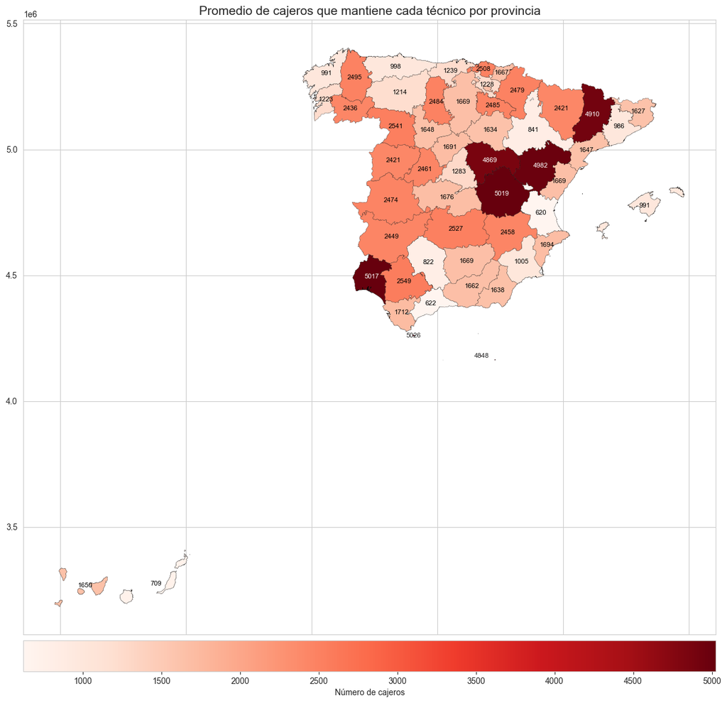

```python
import matplotlib.pyplot as plt
from mpl_toolkits.axes_grid1 import make_axes_locatable

fig, ax = plt.subplots(1, 1, figsize=(15, 15))

# Crea un divisor para el eje y añade un nuevo eje para la leyenda
divider = make_axes_locatable(ax)
cax = divider.append_axes("bottom", size="5%", pad=0.1)

# Dibuja el mapa
provinces_plus.plot(column='atms_to_tech_ratio_per_prov', cmap='Reds', linewidth=0.2, ax=ax,
                  edgecolor='black', legend=True, cax=cax, legend_kwds={'label': "Número de cajeros", 'orientation': "horizontal"})

# Otras configuraciones
color_change_threshold = (provinces_plus['atms_to_tech_ratio_per_prov'].max() + provinces_plus['atms_to_tech_ratio_per_prov'].min()) / 2
for x, y, label, color in zip(provinces_plus.geometry.centroid.x, provinces_plus.geometry.centroid.y,
                              provinces_plus['atms_to_tech_ratio_per_prov'], provinces_plus['atms_to_tech_ratio_per_prov']):
    text_color = 'white' if color > color_change_threshold else 'black'
    ax.text(x, y, str(label), fontsize=8, ha='center', va='center', color=text_color)

ax.set_title('Promedio de cajeros que mantiene cada técnico por provincia', fontdict={'fontsize': '15', 'fontweight' : '2'})

# Define una función para anotar manualmente las cantidades correspondientes a las ciudades autónomas
def annotate_cities(ax, geometry, label, text_offset=(0,0)):
    xy = (geometry.centroid.x + text_offset[0], geometry.centroid.y + text_offset[1])
    ax.annotate(label, xy=xy, xytext=(0,0), textcoords='offset points', fontsize=8, ha='center', va='center')

ceuta_row = provinces_plus[provinces_plus['province_name'] == 'CEUTA'].iloc[0]
melilla_row = provinces_plus[provinces_plus['province_name'] == 'MELILLA'].iloc[0]
annotate_cities(ax, ceuta_row['geometry'], ceuta_row['atms_to_tech_ratio_per_prov'])
annotate_cities(ax, melilla_row['geometry'], melilla_row['atms_to_tech_ratio_per_prov'])

plt.show()
```

Obsérvese que la intensidad del color rojo en el mapa superior es proporcional al promedio de cajeros que debe mantener cada miembro del equipo técnico en una provincia. De esta forma, se puede identificar fácilmente la sobrecarga de trabajo que padecen los técnicos de provincias como Lleida, Guadalajara, Teruel, Cuenca, Huelva o las ciudades autónomas de Ceuta y Melilla. Mientras que ellos deben mantener un promedio de unos 5000 cajeros, sus compañeros de Valencia o Málaga mantienen poco más de 600 máquinas.

### Promedio de cajeros que debe mantener cada técnico por comunidad autónoma (mapa de calor)

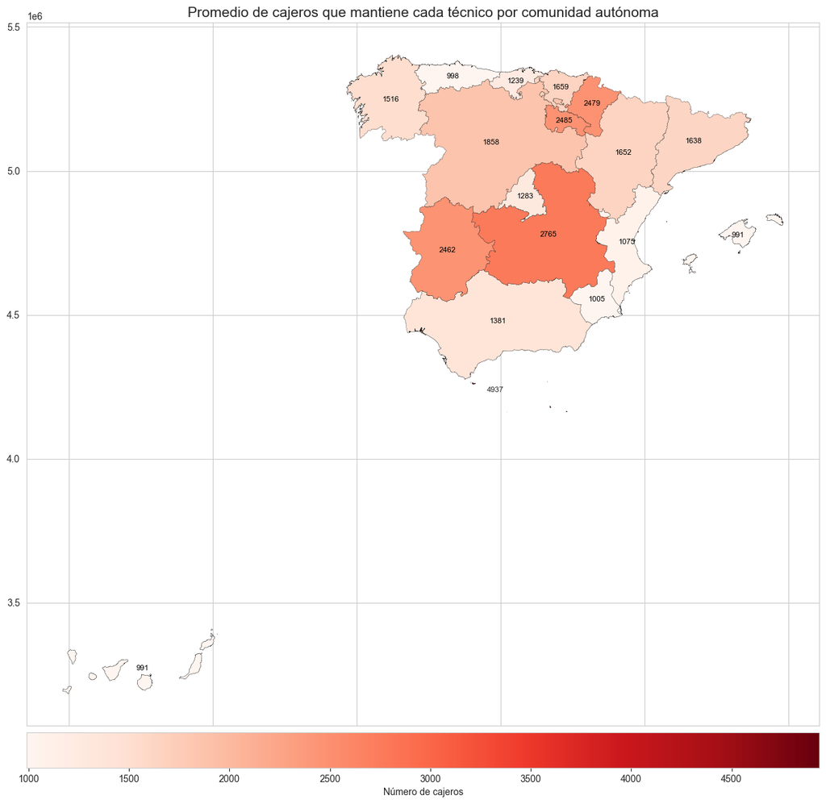

```python
fig, ax = plt.subplots(1, 1, figsize=(15, 15))

# Crea un divisor para el eje y añade un nuevo eje para la leyenda
divider = make_axes_locatable(ax)
cax = divider.append_axes("bottom", size="5%", pad=0.1)

# Dibuja el mapa
communities.plot(column='atms_to_tech_ratio_per_comm', cmap='Reds', linewidth=0.2, ax=ax,
                 edgecolor='black', legend=True, cax=cax, legend_kwds={'label': "Número de cajeros", 'orientation': "horizontal"})

# Otras configuraciones
color_change_threshold = (communities['atms_to_tech_ratio_per_comm'].max() + communities['atms_to_tech_ratio_per_comm'].min()) / 2
for x, y, label, color in zip(communities.geometry.centroid.x, communities.geometry.centroid.y,
                              communities['atms_to_tech_ratio_per_comm'], communities['atms_to_tech_ratio_per_comm']):
    text_color = 'white' if color > color_change_threshold else 'black'
    ax.text(x, y, str(label), fontsize=8, ha='center', va='center', color=text_color)

ax.set_title('Promedio de cajeros que mantiene cada técnico por comunidad autónoma', fontdict={'fontsize': '15', 'fontweight' : '2'})

autonomous_cities_row = communities[communities['community_name'] == 'Ceuta y Melilla'].iloc[0]
annotate_cities(ax, autonomous_cities_row['geometry'], autonomous_cities_row['atms_to_tech_ratio_per_comm'])

plt.show()
```

Al agrupar los datos por comunidades autónomas, la desproporción no parece tan grave. De hecho, es frecuente que los coordinadores desplacen a miembros de su equipo de unas provincias a otras dentro de su comunidad autónoma para hacer frente a las sobrecargas puntuales de trabajo en momentos concretos. En este sentido, podríamos ofrecer a nuestro cliente la posibilidad de proporcionarle métricas que le permitan dimensionar correctamente sus equipos si nos facilita más información.

### Tráfico entre el servidor HTTP y los cajeros de cada provincia (en Gb)

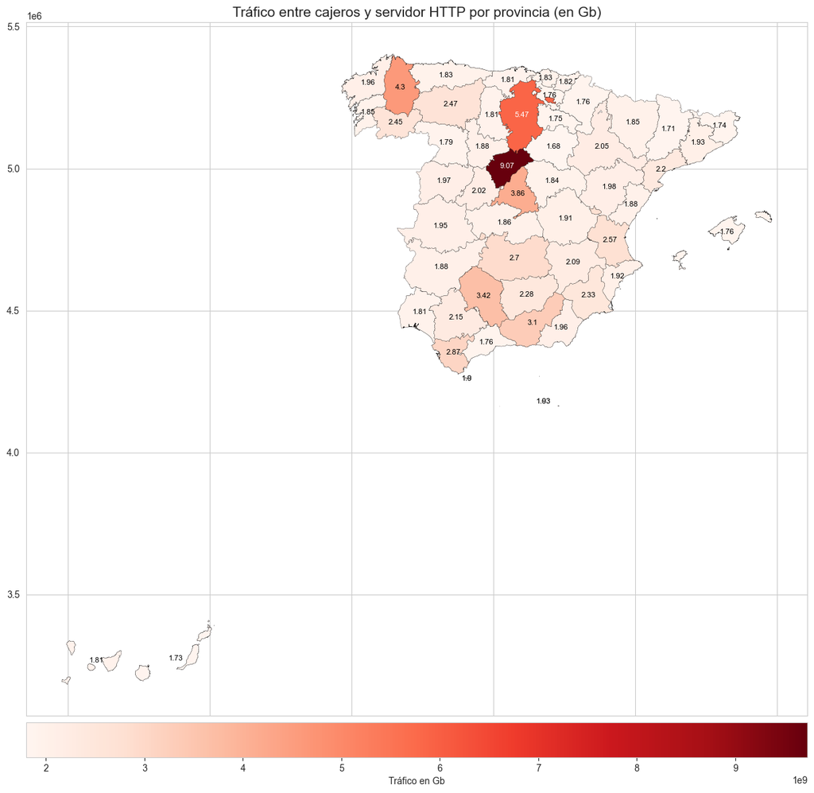

```python
# Convierte la columna de tráfico de bytes a gigabytes
provinces_plus['traffic_volume_per_prov_GB'] = round(provinces_plus['traffic_volume_per_prov'] / (1024 * 1024 * 1024), 2)

fig, ax = plt.subplots(1, 1, figsize=(15, 15))

# Crea un divisor para el eje y añade un nuevo eje para la leyenda
divider = make_axes_locatable(ax)
cax = divider.append_axes("bottom", size="5%", pad=0.1)

# Dibuja el mapa
provinces_plus.plot(column='traffic_volume_per_prov', cmap='Reds', linewidth=0.2, ax=ax,
                  edgecolor='black', legend=True, cax=cax, legend_kwds={'label': "Tráfico en Gb", 'orientation': "horizontal"})

# Otras configuraciones
color_change_threshold = (provinces_plus['traffic_volume_per_prov_GB'].max() + provinces_plus['traffic_volume_per_prov_GB'].min()) / 2
for x, y, label, color in zip(provinces_plus.geometry.centroid.x, provinces_plus.geometry.centroid.y,
                              provinces_plus['traffic_volume_per_prov_GB'], provinces_plus['traffic_volume_per_prov_GB']):
    text_color = 'white' if color > color_change_threshold else 'black'
    ax.text(x, y, str(label), fontsize=8, ha='center', va='center', color=text_color)

ax.set_title('Tráfico entre cajeros y servidor HTTP por provincia (en Gb)', fontdict={'fontsize': '15', 'fontweight' : '2'})

ceuta_row = provinces_plus[provinces_plus['province_name'] == 'CEUTA'].iloc[0]
melilla_row = provinces_plus[provinces_plus['province_name'] == 'MELILLA'].iloc[0]
annotate_cities(ax, ceuta_row['geometry'], ceuta_row['traffic_volume_per_prov_GB'])
annotate_cities(ax, melilla_row['geometry'], melilla_row['traffic_volume_per_prov_GB'])

plt.show()
```

En el mapa superior se observa que el tráfico entre el servidor HTTP y los cajeros ubicados en las provincias de Segovia, Burgos o Lugo es muy superior al que se produce en el resto de provincias. Deberíamos informar a nuestro cliente de este hecho para que averigüe qué está provocando este tráfico desmesurado en Segovia, por ejemplo.

### Número total de errores por provincia

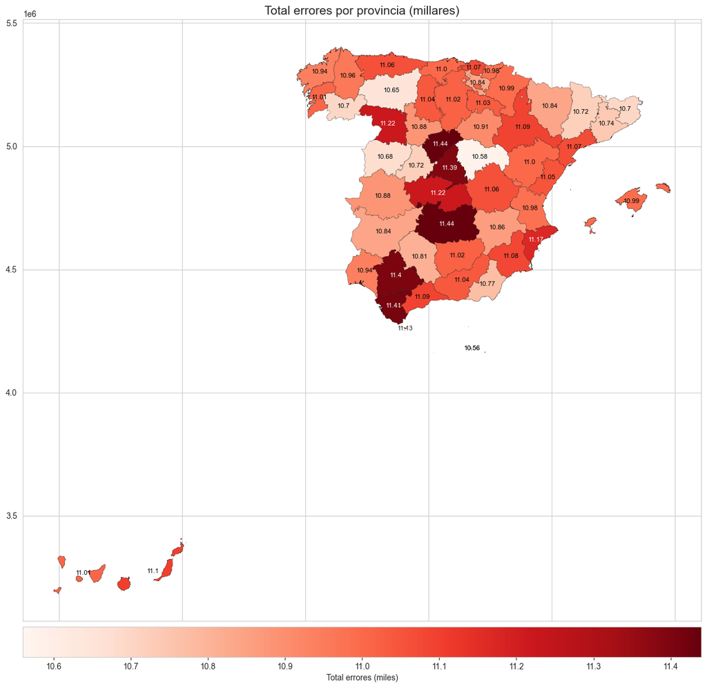

```python
# Convierte la columna de errores de unidades a miles (K)
provinces_plus['total_errors_per_prov_K'] = round(provinces_plus['total_errors_per_prov'] / (1000), 2)

fig, ax = plt.subplots(1, 1, figsize=(15, 15))

# Crea un divisor para el eje y añade un nuevo eje para la leyenda
divider = make_axes_locatable(ax)
cax = divider.append_axes("bottom", size="5%", pad=0.1)

# Dibuja el mapa
provinces_plus.plot(column='total_errors_per_prov_K', cmap='Reds', linewidth=0.2, ax=ax,
                  edgecolor='black', legend=True, cax=cax, legend_kwds={'label': "Total errores (miles)", 'orientation': "horizontal"})

# Otras configuraciones
color_change_threshold = (provinces_plus['total_errors_per_prov_K'].max() + provinces_plus['total_errors_per_prov_K'].min()) / 1.98
for x, y, label, color in zip(provinces_plus.geometry.centroid.x, provinces_plus.geometry.centroid.y,
                              provinces_plus['total_errors_per_prov_K'], provinces_plus['total_errors_per_prov_K']):
    text_color = 'white' if color > color_change_threshold else 'black'
    ax.text(x, y, str(label), fontsize=8, ha='center', va='center', color=text_color)

ax.set_title('Total errores por provincia (millares)', fontdict={'fontsize': '15', 'fontweight' : '2'})

ceuta_row = provinces_plus[provinces_plus['province_name'] == 'CEUTA'].iloc[0]
melilla_row = provinces_plus[provinces_plus['province_name'] == 'MELILLA'].iloc[0]
annotate_cities(ax, ceuta_row['geometry'], ceuta_row['total_errors_per_prov_K'])
annotate_cities(ax, melilla_row['geometry'], melilla_row['total_errors_per_prov_K'])

plt.show()
```

En el mapa superior se observa que las diferencias entre el número de errores que generan los cajeros de una u otra provincia no son significativos. Aunque los datos indican que Melilla es donde se han producido menos errores (10560) frente a Ciudad Real y Segovia que poseen los valores máximos (11440).

### Número total de eventos por provincia

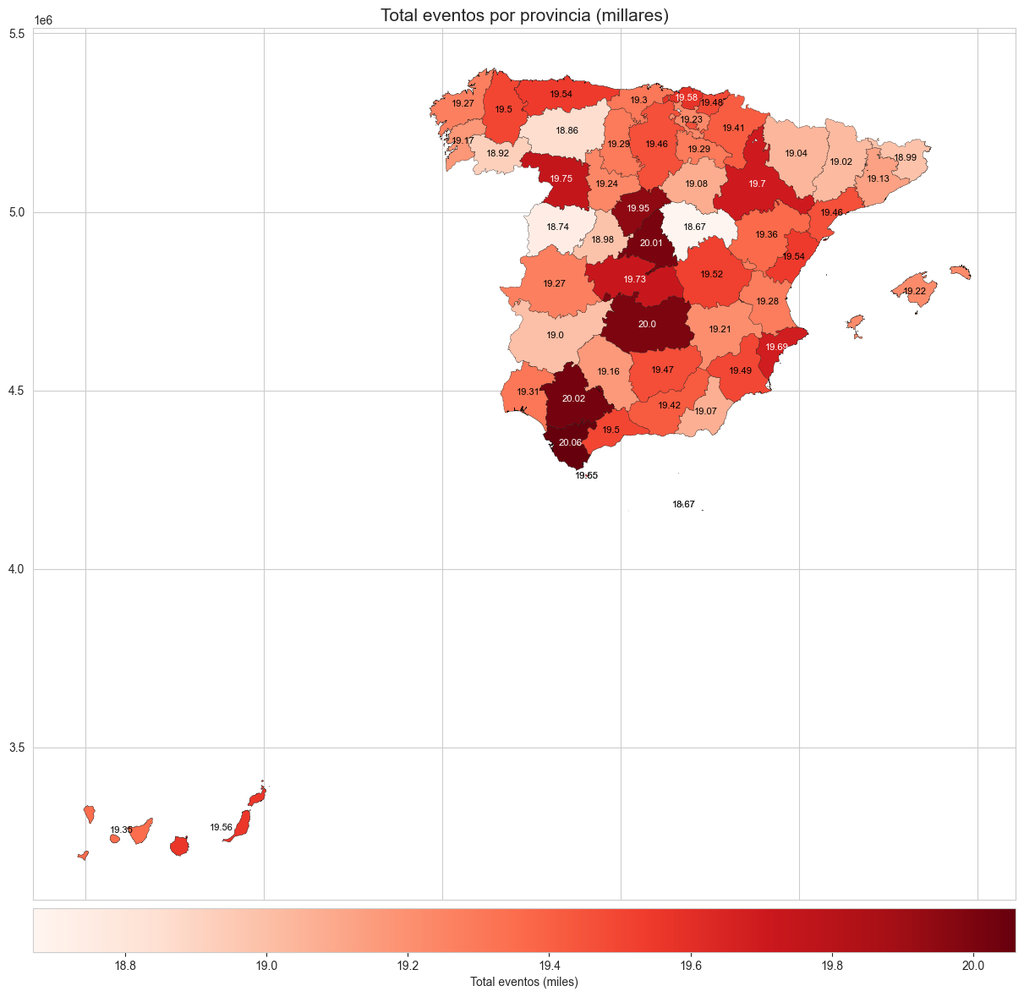

```python
# Convierte la columna de eventos de unidades a miles (K)
provinces_plus['total_events_per_prov_K'] = round(provinces_plus['total_events_per_prov'] / (1000), 2)

fig, ax = plt.subplots(1, 1, figsize=(15, 15))

# Crea un divisor para el eje y añade un nuevo eje para la leyenda
divider = make_axes_locatable(ax)
cax = divider.append_axes("bottom", size="5%", pad=0.1)

# Dibuja el mapa
provinces_plus.plot(column='total_events_per_prov_K', cmap='Reds', linewidth=0.2, ax=ax,
                  edgecolor='black', legend=True, cax=cax, legend_kwds={'label': "Total eventos (miles)", 'orientation': "horizontal"})

# Otras configuraciones
color_change_threshold = (provinces_plus['total_events_per_prov_K'].max() + provinces_plus['total_events_per_prov_K'].min()) / 1.98
for x, y, label, color in zip(provinces_plus.geometry.centroid.x, provinces_plus.geometry.centroid.y,
                              provinces_plus['total_events_per_prov_K'], provinces_plus['total_events_per_prov_K']):
    text_color = 'white' if color > color_change_threshold else 'black'
    ax.text(x, y, str(label), fontsize=8, ha='center', va='center', color=text_color)

ax.set_title('Total eventos por provincia (millares)', fontdict={'fontsize': '15', 'fontweight' : '2'})

ceuta_row = provinces_plus[provinces_plus['province_name'] == 'CEUTA'].iloc[0]
melilla_row = provinces_plus[provinces_plus['province_name'] == 'MELILLA'].iloc[0]
annotate_cities(ax, ceuta_row['geometry'], ceuta_row['total_events_per_prov_K'])
annotate_cities(ax, melilla_row['geometry'], melilla_row['total_events_per_prov_K'])

plt.show()
```

En cuanto al número total de eventos, tampoco existe una gran variabilidad entre provincias. El valor máximo lo encontramos en Cádiz, con 20060 eventos, frente al mínimo de Guadalajara y Melilla, que coinciden en el valor de 18670.

```python
# Libera memoria
%reset -f
```

## Modelo predictivo

Ha llegado la hora de construir el modelo predictivo. Para ello, vamos a realizar una serie de transformaciones previas a los datos que tenemos para adecuarlos a los algoritmos que vamos a utilizar. Comenzamos recuperando y combinando los distintos dataframes para obtener uno solo.

```python
# Recupera dataframes guardados
import pandas as pd
import geopandas as gpd
from shapely import wkt

clients_plus = pd.read_csv('clean_data/clients_plus.csv')
provinces_plus = pd.read_csv('clean_data/provinces_plus.csv')
provinces_plus['geometry'] = provinces_plus['geometry'].apply(wkt.loads)
provinces_plus = gpd.GeoDataFrame(provinces_plus, geometry='geometry')
communities = pd.read_csv('clean_data/communities.csv')
communities['geometry'] = communities['geometry'].apply(wkt.loads)
communities = gpd.GeoDataFrame(communities, geometry='geometry')
df_access_log = pd.read_csv('clean_data/access_log.csv')
events_df = pd.read_csv('clean_data/events_df.csv')
```

### Combinar dataframes

La combinación de dataframes podría hacerse de diversas formas. En este caso, se ha determinado que la manera que mejor resultados ofrece a la hora de elaborar el modelo predictivo es la siguiente: se combinan por un lado los dataframes clients_plus, provinces_plus y communities. Estos ya contienen la información agregada por máquina, provincia y comunidad que se ha extraído de acces.log y status.db. Después, se añade la información almacenada en el dataframe events_df y por último, se combina todo con el dataframe df_access_log.

De esta forma, obtenemos un único dataframe llamado model_df que contiene tanto la información original que aportó el cliente como la que se ha ido añadiendo mediante la ingeniería de características.

```python
# Crea un nuevo dataframe llamado model_df a partir de clients_plus
# eliminando la columna community_code (que ya está en provinces_plus)
model_df = clients_plus.drop(columns=['community_code'])
# Añade la información de provinces_plus
#model_df = model_df.merge(provinces_plus.drop(['traffic_volume_per_prov_GB', 'total_errors_per_prov_K', 'total_events_per_prov_K'], axis=1), on='province_code')
model_df = model_df.merge(provinces_plus, on='province_code')
# Añade la información de communities
model_df = model_df.merge(communities, on='community_code')

# Combina model_df y events_df
model_df = model_df.merge(events_df, on='client_ip', how='outer')
# Identifica las columnas de tipo float64
float_columns = model_df.select_dtypes(include=['float64']).columns
# Reemplaza los valores NaN con ceros y convierte a int32
model_df[float_columns] = model_df[float_columns].fillna(0).astype('int32')

# Combina df_access_log con el dataframe anterior
model_df = df_access_log.merge(model_df, on='client_ip')

model_df.info()
model_df
```

```
<class 'pandas.core.frame.DataFrame'>
RangeIndex: 10364923 entries, 0 to 10364922
Data columns (total 80 columns):
 #   Column                               Dtype
---  ------                               -----
 0   client_ip                            object
 1   timestamp                            object
 2   response_code                        int64
 3   size                                 int64
 4   http_method                          object
 5   province_code                        int64
 6   repaired                             int64
 7   most_frequent_hour_per_atm           int64
 8   most_frequent_response_code_per_atm  int64
 9   most_frequent_http_method_per_atm    object
```

[output cut: 72 more lines]

|  | client_ip | timestamp | response_code | size | http_method | province_code | repaired | most_frequent_hour_per_atm | most_frequent_response_code_per_atm | most_frequent_http_method_per_atm | traffic_volume | generates_events | total_errors | total_hw_events | total_events | most_frequent_event_code_1_per_atm | most_frequent_event_code_2_per_atm | most_frequent_event_code_3_per_atm | province_name | community_code | geometry_x | lat_prov | lon_prov | techs_num_per_prov | atms_num_per_prov | atms_to_tech_ratio_per_prov | most_frequent_hour_per_prov | traffic_volume_per_prov | total_events_per_prov | … |
| --- | --- | --- | --- | --- | --- | --- | --- | --- | --- | --- | --- | --- | --- | --- | --- | --- | --- | --- | --- | --- | --- | --- | --- | --- | --- | --- | --- | --- | --- | --- |
| 0 | 54.36.149.41 | 2019-01-22 03:56:14+03:30 | 200 | 30577 | GET | 14 | 1 | 9 | 200 | GET | 4054292 | 1 | 0 | 1 | 1 | 38 | 1 | 6 | CORDOBA | 1 | MULTIPOLYGON (((-562000.703 4502162.623, -5617... | 37 | -4 | 6 | 4933 | 822 | 19 | 3674507138 | 19161 | … |
| 1 | 54.36.149.41 | 2019-01-22 04:06:30+03:30 | 200 | 33274 | GET | 14 | 1 | 9 | 200 | GET | 4054292 | 1 | 0 | 1 | 1 | 38 | 1 | 6 | CORDOBA | 1 | MULTIPOLYGON (((-562000.703 4502162.623, -5617... | 37 | -4 | 6 | 4933 | 822 | 19 | 3674507138 | 19161 | … |
| 2 | 54.36.149.41 | 2019-01-22 04:08:40+03:30 | 200 | 25815 | GET | 14 | 1 | 9 | 200 | GET | 4054292 | 1 | 0 | 1 | 1 | 38 | 1 | 6 | CORDOBA | 1 | MULTIPOLYGON (((-562000.703 4502162.623, -5617... | 37 | -4 | 6 | 4933 | 822 | 19 | 3674507138 | 19161 | … |
| 3 | 54.36.149.41 | 2019-01-22 04:55:21+03:30 | 200 | 32852 | GET | 14 | 1 | 9 | 200 | GET | 4054292 | 1 | 0 | 1 | 1 | 38 | 1 | 6 | CORDOBA | 1 | MULTIPOLYGON (((-562000.703 4502162.623, -5617... | 37 | -4 | 6 | 4933 | 822 | 19 | 3674507138 | 19161 | … |
| 4 | 54.36.149.41 | 2019-01-22 06:55:15+03:30 | 200 | 30589 | GET | 14 | 1 | 9 | 200 | GET | 4054292 | 1 | 0 | 1 | 1 | 38 | 1 | 6 | CORDOBA | 1 | MULTIPOLYGON (((-562000.703 4502162.623, -5617... | 37 | -4 | 6 | 4933 | 822 | 19 | 3674507138 | 19161 | … |
| ... | ... | ... | ... | ... | ... | ... | ... | ... | ... | ... | ... | ... | ... | ... | ... | ... | ... | ... | ... | ... | ... | ... | ... | ... | ... | ... | ... | ... | ... | … |
| 10364918 | 151.241.254.118 | 2019-01-26 20:29:12+03:30 | 200 | 36415 | GET | 2 | 1 | 20 | 200 | GET | 631667 | 1 | 4 | 2 | 5 | 1 | 3 | 1 | ALBACETE | 4 | POLYGON ((-165697.390 4754282.676, -165581.726... | 38 | -1 | 2 | 4916 | 2458 | 14 | 2243818812 | 19208 | … |
| 10364919 | 151.241.254.118 | 2019-01-26 20:29:12+03:30 | 200 | 100979 | GET | 2 | 1 | 20 | 200 | GET | 631667 | 1 | 4 | 2 | 5 | 1 | 3 | 1 | ALBACETE | 4 | POLYGON ((-165697.390 4754282.676, -165581.726... | 38 | -1 | 2 | 4916 | 2458 | 14 | 2243818812 | 19208 | … |
| 10364920 | 151.241.254.118 | 2019-01-26 20:29:12+03:30 | 200 | 36435 | GET | 2 | 1 | 20 | 200 | GET | 631667 | 1 | 4 | 2 | 5 | 1 | 3 | 1 | ALBACETE | 4 | POLYGON ((-165697.390 4754282.676, -165581.726... | 38 | -1 | 2 | 4916 | 2458 | 14 | 2243818812 | 19208 | … |
| 10364921 | 5.112.12.77 | 2019-01-26 20:29:12+03:30 | 200 | 7064 | GET | 36 | 1 | 20 | 200 | GET | 7064 | 1 | 3 | 3 | 4 | 38 | 3 | 1 | PONTEVEDRA | 12 | MULTIPOLYGON (((-986615.508 5154440.124, -9866... | 42 | -8 | 4 | 4894 | 1223 | 19 | 1982479807 | 19168 | … |
| 10364922 | 45.79.177.249 | 2019-01-26 20:29:13+03:30 | 200 | 19343 | GET | 17 | 0 | 20 | 200 | GET | 19343 | 1 | 3 | 3 | 6 | 38 | 3 | 2 | GIRONA | 6 | MULTIPOLYGON (((354877.190 5111985.631, 354877... | 42 | 2 | 3 | 4883 | 1627 | 12 | 1870700528 | 18992 | … |

10364923 rows × 80 columns

### Codificación de variables categóricas

El dataframe que hemos obtenido contiene 10364923 registros y 80 columnas. Algunas de ellas son variables categóricas que no podemos pasar directamente a los algoritmos que vamos a utilizar. Por consiguiente, vamos a transformarlas a un formato numérico. Para ello, vamos a utilizar de manera preferente una codificación basada en conteos (siempre que no se produzcan colisiones entre etiquetas durante el proceso de codificación).

#### Codificación basada en conteos

Ahora, vamos a crear una función que nos permita realizar cómodamente la codificación de variables categóricas basada en conteos, comprobando que no se produzcan colisiones.

```python
def count_based_coding(df, column_name):
    """
    Función para realizar una codificación de variables categóricas basada en conteos.

    Parámetros:
    df (pandas.core.frame.DataFrame): el dataframe en cuestión.
    column_name (str): nombre de la columna que se pretende codificar.

    Devuelve: nada.
    """
    # Codificación numérica basada en conteos
    encoded = df[column_name].value_counts().reindex(df[column_name]).values
    # Crear un diccionario con las equivalencias entre los valores originales y los códigos creados
    equiv_dict = {k: v for k, v in zip(df[column_name], encoded)}

    # Identifica los elementos duplicados
    duplicated_values = len(equiv_dict) != len(set(equiv_dict.values()))

    print(f'Columna: {column_name}')
    if duplicated_values:
        print('¡¡¡Hay colisiones!!!\nNo se utiliza esta codificación.\n\n')
    else:
        print('No hay colisiones: se utiliza esta codificación basada en conteos.')
        model_df[column_name] = encoded
        print('Diccionario de equivalencias:')
        print(equiv_dict, '\n')
```

Una vez que disponemos de la función count_based_coding, vamos a utilizar este método para codificar algunas columnas.

```python
count_based_coding(model_df, 'client_ip')
count_based_coding(model_df, 'response_code')
count_based_coding(model_df, 'http_method')
count_based_coding(model_df, 'most_frequent_http_method_per_atm')
count_based_coding(model_df, 'province_name')
count_based_coding(model_df, 'community_name')
```

```
Columna: client_ip
¡¡¡Hay colisiones!!!
No se utiliza esta codificación.


Columna: response_code
No hay colisiones: se utiliza esta codificación basada en conteos.
Diccionario de equivalencias:
{200: 9579825, 302: 199835, 404: 105011, 301: 67552, 499: 50852, 500: 14266, 502: 798, 400: 358, 504: 103, 304: 340228, 403: 5634, 408: 112, 401: 323, 414: 17, 405: 6, 206: 3}

Columna: http_method
No hay colisiones: se utiliza esta codificación basada en conteos.
Diccionario de equivalencias:
{'GET': 10189791, 'POST': 139155, 'HEAD': 34501, 'OPTIONS': 1424, 'ERROR': 39, 'CONNECT': 10, 'PROPFIND': 3}

Columna: most_frequent_http_method_per_atm
No hay colisiones: se utiliza esta codificación basada en conteos.
Diccionario de equivalencias:
{'GET': 10347269, 'POST': 4142, 'HEAD': 13483, 'CONNECT': 11, 'ERROR': 18}

Columna: province_name
No hay colisiones: se utiliza esta codificación basada en conteos.
Diccionario de equivalencias:
{'CORDOBA': 213840, 'GIPUZKOA': 172886, 'PALENCIA': 169257, 'SEGOVIA': 548005, 'CACERES': 199300, 'BURGOS': 501053, 'HUESCA': 172305, 'CADIZ': 202574, 'HUELVA': 172636, 'MURCIA': 175693, 'ALMERIA': 192510, 'ALBACETE': 217993, 'TERUEL': 185743, 'OURENSE': 253070, 'LAS PALMAS': 165551, 'STA CRUZ DE TE…

Columna: community_name
No hay colisiones: se utiliza esta codificación basada en conteos.
Diccionario de equivalencias:
{'Andalucía': 1583920, 'País Vasco': 507288, 'Castilla y León': 2285532, 'Extremadura': 380341, 'Aragón': 537183, 'Región de Murcia': 175693, 'Castilla-La Mancha': 993329, 'Galicia': 784054, 'Islas Canarias': 340611, 'Cataluña': 671969, 'Islas Baleares': 165436, 'Ceuta y Melilla': 354587, 'Principad…
```

#### Codificación columna client_ip

Como se puede observar en los resultados que acabamos de obtener, no se puede utilizar la codificación basada en conteos con la columna "client_ip" porque se producen colisiones. Para codificarla, se podrían crear otras cuatro columnas a partir de ella. Las nuevas columnas contendrían cada uno de los octetos de la dirección IP y se llamarían ip_1, ip_2, ip_3 e ip_4. Esto permitiría analizar si existen patrones específicos dentro de las direcciones IP y modelarlos si así fuera.

Sin embargo, en este caso, se ha preferido evitar el uso de la columna "client_ip" (ni ninguna otra variable que se desprenda de ella) en el modelo, porque ya conocemos las direcciones IP que corresponden a máquinas reparadas y no reparadas (por la información original que aportó el cliente). Por tanto, el uso de esta variable podría conducir a la construcción de un modelo sobreajustado que simplemente aprenda qué direcciones IP han sido reparadas y cuáles no. En cambio, lo que pretendemos es que nuestro modelo sea capaz de predecir si una máquina será reparada o no en función de cualquiera de las otras características.

```python
# Divide la columna 'client_ip' en cuatro columnas separadas
# model_df[['ip_1', 'ip_2', 'ip_3', 'ip_4']] = model_df['client_ip'].str.split('.', expand=True)
# Convierte las nuevas columnas a tipo numérico
# model_df[['ip_1', 'ip_2', 'ip_3', 'ip_4']] = model_df[['ip_1', 'ip_2', 'ip_3', 'ip_4']].astype(int)
```

Asímismo, descartamos las columnas "timestamp", "geometry_x" y "geometry_y", que también podrían provocar un sobreajuste.

```python
# Elimina las columnas que no se van a usar en el modelo
model_df = model_df.drop(columns=['client_ip', 'timestamp', 'geometry_x', 'geometry_y'])
# Reordena las columnas para que "repaired" sea la última
model_df['repaired'] = model_df.pop('repaired')

pd.set_option('display.max_rows', 100)
print('model_df:')
# Descripción general de los datos
df_info = pd.DataFrame(model_df.dtypes, columns=['dtypes'])
df_info = df_info.reset_index()
df_info['name'] = df_info['index']
df_info = df_info[['name','dtypes']]
df_info['missing'] = model_df.isnull().sum().values
df_info['unique'] = model_df.nunique().values
df_info
```

```
model_df:
```

|  | name | dtypes | missing | unique |
| --- | --- | --- | --- | --- |
| 0 | response_code | int64 | 0 | 16 |
| 1 | size | int64 | 0 | 69707 |
| 2 | http_method | int64 | 0 | 7 |
| 3 | province_code | int64 | 0 | 52 |
| 4 | most_frequent_hour_per_atm | int64 | 0 | 24 |
| 5 | most_frequent_response_code_per_atm | int64 | 0 | 12 |
| 6 | most_frequent_http_method_per_atm | int64 | 0 | 5 |
| 7 | traffic_volume | int64 | 0 | 123383 |
| 8 | generates_events | int64 | 0 | 2 |
| 9 | total_errors | int64 | 0 | 13 |
| 10 | total_hw_events | int64 | 0 | 12 |
| 11 | total_events | int64 | 0 | 17 |
| 12 | most_frequent_event_code_1_per_atm | int64 | 0 | 9 |
| 13 | most_frequent_event_code_2_per_atm | int64 | 0 | 5 |
| 14 | most_frequent_event_code_3_per_atm | int64 | 0 | 29 |
| 15 | province_name | int64 | 0 | 52 |
| 16 | community_code | int64 | 0 | 18 |
| 17 | lat_prov | int32 | 0 | 10 |
| 18 | lon_prov | int32 | 0 | 13 |
| 19 | techs_num_per_prov | int64 | 0 | 8 |
| 20 | atms_num_per_prov | int64 | 0 | 47 |
| 21 | atms_to_tech_ratio_per_prov | int64 | 0 | 48 |
| 22 | most_frequent_hour_per_prov | int64 | 0 | 8 |
| 23 | traffic_volume_per_prov | int64 | 0 | 52 |
| 24 | total_events_per_prov | int64 | 0 | 52 |
| 25 | total_hw_events_per_prov | int64 | 0 | 51 |
| 26 | total_errors_per_prov | int64 | 0 | 50 |
| 27 | community_name | int64 | 0 | 18 |
| 28 | lon_comm | int32 | 0 | 18 |
| 29 | lat_comm | int32 | 0 | 18 |
| 30 | techs_num_per_comm | int64 | 0 | 10 |
| 31 | atms_num_per_comm | int64 | 0 | 18 |
| 32 | atms_to_tech_ratio_per_comm | int64 | 0 | 17 |
| 33 | most_frequent_hour_per_comm | int64 | 0 | 3 |
| 34 | traffic_volume_per_comm | int64 | 0 | 18 |
| 35 | total_events_per_comm | int64 | 0 | 18 |
| 36 | total_hw_events_per_comm | int64 | 0 | 18 |
| 37 | total_errors_per_comm | int64 | 0 | 17 |
| 38 | 01-2-00000001 | int32 | 0 | 5 |
| 39 | 01-2-00000002 | int32 | 0 | 5 |
| 40 | 01-4-00000001 | int32 | 0 | 4 |
| 41 | 01-4-00000002 | int32 | 0 | 5 |
| 42 | 02-4-000000FF | int32 | 0 | 4 |
| 43 | 35-3-0000FFFF | int32 | 0 | 5 |
| 44 | 35-3-0100FFFF | int32 | 0 | 6 |
| 45 | 38-1-00000006 | int32 | 0 | 4 |
| 46 | 38-1-00000007 | int32 | 0 | 4 |
| 47 | 38-3-00005701 | int32 | 0 | 5 |
| 48 | 38-3-00005811 | int32 | 0 | 5 |
| 49 | 38-3-0000583F | int32 | 0 | 5 |
| 50 | 38-3-00007101 | int32 | 0 | 6 |
| 51 | 38-3-00007102 | int32 | 0 | 4 |
| 52 | 38-3-00007105 | int32 | 0 | 5 |
| 53 | 38-3-0000850F | int32 | 0 | 5 |
| 54 | 38-3-01005701 | int32 | 0 | 5 |
| 55 | 38-3-01005811 | int32 | 0 | 4 |
| 56 | 38-3-01007101 | int32 | 0 | 5 |
| 57 | 38-3-01007102 | int32 | 0 | 4 |
| 58 | 38-3-01007105 | int32 | 0 | 5 |
| 59 | 38-3-0100850F | int32 | 0 | 4 |
| 60 | 38-3-0100FFFF | int32 | 0 | 4 |
| 61 | 38-4-00000008 | int32 | 0 | 5 |
| 62 | 40-1-01000001 | int32 | 0 | 4 |
| 63 | 40-1-01000002 | int32 | 0 | 4 |
| 64 | 40-2-01000002 | int32 | 0 | 5 |
| 65 | 41-1-00000001 | int32 | 0 | 5 |
| 66 | 42-3-00001501 | int32 | 0 | 5 |
| 67 | 42-3-00001600 | int32 | 0 | 5 |
| 68 | 83-1-00000003 | int32 | 0 | 4 |
| 69 | 83-1-00000004 | int32 | 0 | 5 |
| 70 | 83-1-0000000A | int32 | 0 | 5 |
| 71 | 83-2-00000001 | int32 | 0 | 5 |
| 72 | 83-2-00000002 | int32 | 0 | 5 |
| 73 | 83-2-00000003 | int32 | 0 | 5 |
| 74 | 83-2-00000004 | int32 | 0 | 5 |
| 75 | repaired | int64 | 0 | 2 |

En la salida obtenida, se observa que ahora disponemos de 76 columnas, todas ellas en formato numérico.

```python
model_df
```

|  | response_code | size | http_method | province_code | most_frequent_hour_per_atm | most_frequent_response_code_per_atm | most_frequent_http_method_per_atm | traffic_volume | generates_events | total_errors | total_hw_events | total_events | most_frequent_event_code_1_per_atm | most_frequent_event_code_2_per_atm | most_frequent_event_code_3_per_atm | province_name | community_code | lat_prov | lon_prov | techs_num_per_prov | atms_num_per_prov | atms_to_tech_ratio_per_prov | most_frequent_hour_per_prov | traffic_volume_per_prov | total_events_per_prov | total_hw_events_per_prov | total_errors_per_prov | community_name | lon_comm | … |
| --- | --- | --- | --- | --- | --- | --- | --- | --- | --- | --- | --- | --- | --- | --- | --- | --- | --- | --- | --- | --- | --- | --- | --- | --- | --- | --- | --- | --- | --- | --- |
| 0 | 9579825 | 30577 | 10189791 | 14 | 9 | 200 | 10347269 | 4054292 | 1 | 0 | 1 | 1 | 38 | 1 | 6 | 213840 | 1 | 37 | -4 | 6 | 4933 | 822 | 19 | 3674507138 | 19161 | 10278 | 10809 | 1583920 | -509058 | … |
| 1 | 9579825 | 33274 | 10189791 | 14 | 9 | 200 | 10347269 | 4054292 | 1 | 0 | 1 | 1 | 38 | 1 | 6 | 213840 | 1 | 37 | -4 | 6 | 4933 | 822 | 19 | 3674507138 | 19161 | 10278 | 10809 | 1583920 | -509058 | … |
| 2 | 9579825 | 25815 | 10189791 | 14 | 9 | 200 | 10347269 | 4054292 | 1 | 0 | 1 | 1 | 38 | 1 | 6 | 213840 | 1 | 37 | -4 | 6 | 4933 | 822 | 19 | 3674507138 | 19161 | 10278 | 10809 | 1583920 | -509058 | … |
| 3 | 9579825 | 32852 | 10189791 | 14 | 9 | 200 | 10347269 | 4054292 | 1 | 0 | 1 | 1 | 38 | 1 | 6 | 213840 | 1 | 37 | -4 | 6 | 4933 | 822 | 19 | 3674507138 | 19161 | 10278 | 10809 | 1583920 | -509058 | … |
| 4 | 9579825 | 30589 | 10189791 | 14 | 9 | 200 | 10347269 | 4054292 | 1 | 0 | 1 | 1 | 38 | 1 | 6 | 213840 | 1 | 37 | -4 | 6 | 4933 | 822 | 19 | 3674507138 | 19161 | 10278 | 10809 | 1583920 | -509058 | … |
| ... | ... | ... | ... | ... | ... | ... | ... | ... | ... | ... | ... | ... | ... | ... | ... | ... | ... | ... | ... | ... | ... | ... | ... | ... | ... | ... | ... | ... | ... | … |
| 10364918 | 9579825 | 36415 | 10189791 | 2 | 20 | 200 | 10347269 | 631667 | 1 | 4 | 2 | 5 | 1 | 3 | 1 | 217993 | 4 | 38 | -1 | 2 | 4916 | 2458 | 14 | 2243818812 | 19208 | 10320 | 10864 | 993329 | -334362 | … |
| 10364919 | 9579825 | 100979 | 10189791 | 2 | 20 | 200 | 10347269 | 631667 | 1 | 4 | 2 | 5 | 1 | 3 | 1 | 217993 | 4 | 38 | -1 | 2 | 4916 | 2458 | 14 | 2243818812 | 19208 | 10320 | 10864 | 993329 | -334362 | … |
| 10364920 | 9579825 | 36435 | 10189791 | 2 | 20 | 200 | 10347269 | 631667 | 1 | 4 | 2 | 5 | 1 | 3 | 1 | 217993 | 4 | 38 | -1 | 2 | 4916 | 2458 | 14 | 2243818812 | 19208 | 10320 | 10864 | 993329 | -334362 | … |
| 10364921 | 9579825 | 7064 | 10189791 | 36 | 20 | 200 | 10347269 | 7064 | 1 | 3 | 3 | 4 | 38 | 3 | 1 | 174873 | 12 | 42 | -8 | 4 | 4894 | 1223 | 19 | 1982479807 | 19168 | 10544 | 11013 | 784054 | -880696 | … |
| 10364922 | 9579825 | 19343 | 10189791 | 17 | 20 | 200 | 10347269 | 19343 | 1 | 3 | 3 | 6 | 38 | 3 | 2 | 179174 | 6 | 42 | 2 | 3 | 4883 | 1627 | 12 | 1870700528 | 18992 | 10268 | 10705 | 671969 | 170423 | … |

10364923 rows × 76 columns

```python
# Guarda dataframe model_df
model_df.to_csv('clean_data/numeric_model_v5.4.csv', index=False)

# Libera memoria
%reset -f
```

### Algoritmos

```python
# Recupera dataframe model_df
import pandas as pd
model_df = pd.read_csv('clean_data/numeric_model_v5.4.csv')
```

#### Regresión logística

Inicialmente, optamos por utilizar un modelo de regresión logística. Este algoritmo de aprendizaje supervisado se utiliza comúnmente para modelar la relación entre una serie de características y una variable objetivo binaria, usando la función logística, cuyo objetivo es estimar la probabilidad de que una instancia pertenezca a una clase particular.

##### Escalado de características

Antes de aplicar el algoritmo de regresión, vamos a transformar los valores de nuestras 76 columnas numéricas, para que todos ellos se encuentren en el mismo rango. Esto útil cuando se trabaja con algoritmos de aprendizaje automático como este, que es sensible a la escala de las características. Al escalar los datos, estamos facilitando la convergencia del algoritmo de optimización y evitamos que las características con rangos más grandes tengan un peso desproporcionado en la función de coste.

```python
from sklearn.preprocessing import MinMaxScaler

# Crear una instancia del escalador Min-Max
scaler = MinMaxScaler()

# Ajustar y transformar el dataFrame model_df
scaled_array = scaler.fit_transform(model_df)

# Convertir la matriz escalada en un dataFrame
scaled_df = pd.DataFrame(scaled_array, columns=model_df.columns)

# Mostrar el dataFrame escalado
scaled_df
```

|  | response_code | size | http_method | province_code | most_frequent_hour_per_atm | most_frequent_response_code_per_atm | most_frequent_http_method_per_atm | traffic_volume | generates_events | total_errors | total_hw_events | total_events | most_frequent_event_code_1_per_atm | most_frequent_event_code_2_per_atm | most_frequent_event_code_3_per_atm | province_name | community_code | lat_prov | lon_prov | techs_num_per_prov | atms_num_per_prov | atms_to_tech_ratio_per_prov | most_frequent_hour_per_prov | traffic_volume_per_prov | total_events_per_prov | total_hw_events_per_prov | total_errors_per_prov | community_name | lon_comm | … |
| --- | --- | --- | --- | --- | --- | --- | --- | --- | --- | --- | --- | --- | --- | --- | --- | --- | --- | --- | --- | --- | --- | --- | --- | --- | --- | --- | --- | --- | --- | --- |
| 0 | 1.0 | 0.024472 | 1.0 | 0.254902 | 0.391304 | 0.0 | 1.0 | 5.358840e-04 | 1.0 | 0.000000 | 0.090909 | 0.0625 | 0.457831 | 0.25 | 3.562363e-07 | 0.142027 | 0.000000 | 0.600000 | 0.684211 | 0.714286 | 0.309524 | 0.045847 | 0.7 | 0.236255 | 0.354212 | 0.221951 | 0.279728 | 0.669066 | 0.597047 | … |
| 1 | 1.0 | 0.026630 | 1.0 | 0.254902 | 0.391304 | 0.0 | 1.0 | 5.358840e-04 | 1.0 | 0.000000 | 0.090909 | 0.0625 | 0.457831 | 0.25 | 3.562363e-07 | 0.142027 | 0.000000 | 0.600000 | 0.684211 | 0.714286 | 0.309524 | 0.045847 | 0.7 | 0.236255 | 0.354212 | 0.221951 | 0.279728 | 0.669066 | 0.597047 | … |
| 2 | 1.0 | 0.020660 | 1.0 | 0.254902 | 0.391304 | 0.0 | 1.0 | 5.358840e-04 | 1.0 | 0.000000 | 0.090909 | 0.0625 | 0.457831 | 0.25 | 3.562363e-07 | 0.142027 | 0.000000 | 0.600000 | 0.684211 | 0.714286 | 0.309524 | 0.045847 | 0.7 | 0.236255 | 0.354212 | 0.221951 | 0.279728 | 0.669066 | 0.597047 | … |
| 3 | 1.0 | 0.026292 | 1.0 | 0.254902 | 0.391304 | 0.0 | 1.0 | 5.358840e-04 | 1.0 | 0.000000 | 0.090909 | 0.0625 | 0.457831 | 0.25 | 3.562363e-07 | 0.142027 | 0.000000 | 0.600000 | 0.684211 | 0.714286 | 0.309524 | 0.045847 | 0.7 | 0.236255 | 0.354212 | 0.221951 | 0.279728 | 0.669066 | 0.597047 | … |
| 4 | 1.0 | 0.024481 | 1.0 | 0.254902 | 0.391304 | 0.0 | 1.0 | 5.358840e-04 | 1.0 | 0.000000 | 0.090909 | 0.0625 | 0.457831 | 0.25 | 3.562363e-07 | 0.142027 | 0.000000 | 0.600000 | 0.684211 | 0.714286 | 0.309524 | 0.045847 | 0.7 | 0.236255 | 0.354212 | 0.221951 | 0.279728 | 0.669066 | 0.597047 | … |
| ... | ... | ... | ... | ... | ... | ... | ... | ... | ... | ... | ... | ... | ... | ... | ... | ... | ... | ... | ... | ... | ... | ... | ... | ... | ... | ... | ... | ... | ... | … |
| 10364918 | 1.0 | 0.029144 | 1.0 | 0.019608 | 0.869565 | 0.0 | 1.0 | 8.349182e-05 | 1.0 | 0.333333 | 0.181818 | 0.3125 | 0.012048 | 0.75 | 5.937272e-08 | 0.152690 | 0.176471 | 0.666667 | 0.842105 | 0.142857 | 0.251701 | 0.417158 | 0.2 | 0.055942 | 0.388049 | 0.273171 | 0.342016 | 0.390498 | 0.681522 | … |
| 10364919 | 1.0 | 0.080816 | 1.0 | 0.019608 | 0.869565 | 0.0 | 1.0 | 8.349182e-05 | 1.0 | 0.333333 | 0.181818 | 0.3125 | 0.012048 | 0.75 | 5.937272e-08 | 0.152690 | 0.176471 | 0.666667 | 0.842105 | 0.142857 | 0.251701 | 0.417158 | 0.2 | 0.055942 | 0.388049 | 0.273171 | 0.342016 | 0.390498 | 0.681522 | … |
| 10364920 | 1.0 | 0.029160 | 1.0 | 0.019608 | 0.869565 | 0.0 | 1.0 | 8.349182e-05 | 1.0 | 0.333333 | 0.181818 | 0.3125 | 0.012048 | 0.75 | 5.937272e-08 | 0.152690 | 0.176471 | 0.666667 | 0.842105 | 0.142857 | 0.251701 | 0.417158 | 0.2 | 0.055942 | 0.388049 | 0.273171 | 0.342016 | 0.390498 | 0.681522 | … |
| 10364921 | 1.0 | 0.005654 | 1.0 | 0.686275 | 0.869565 | 0.0 | 1.0 | 9.336980e-07 | 1.0 | 0.250000 | 0.272727 | 0.2500 | 0.457831 | 0.75 | 5.937272e-08 | 0.041979 | 0.647059 | 0.933333 | 0.473684 | 0.428571 | 0.176871 | 0.136859 | 0.7 | 0.023005 | 0.359251 | 0.546341 | 0.510759 | 0.291788 | 0.417342 | … |
| 10364922 | 1.0 | 0.015481 | 1.0 | 0.313725 | 0.869565 | 0.0 | 1.0 | 2.556699e-06 | 1.0 | 0.250000 | 0.272727 | 0.3750 | 0.457831 | 0.75 | 1.187454e-07 | 0.053022 | 0.294118 | 0.933333 | 1.000000 | 0.285714 | 0.139456 | 0.228552 | 0.0 | 0.008917 | 0.232541 | 0.209756 | 0.161948 | 0.238920 | 0.925611 | … |

10364923 rows × 76 columns

##### Correlaciones entre variables

También vamos a comprobar si existe una relación lineal entre los atributos de nuestro conjunto de datos y la variable objetivo "repaired". Esto resulta útil a la hora de detectar la presencia de un buen predictor en modelos lineales. Al tratarse de un número tan elevado de variables, confeccionaremos dos mapas de calor.

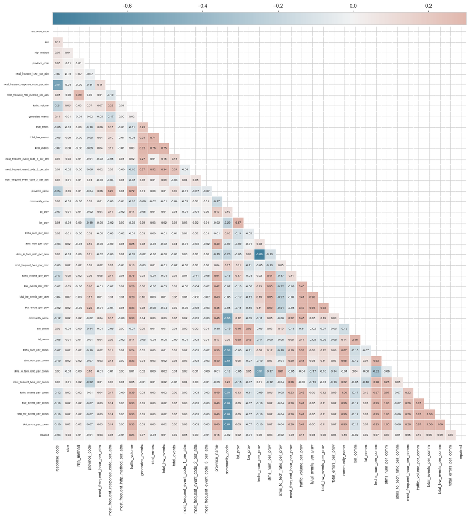

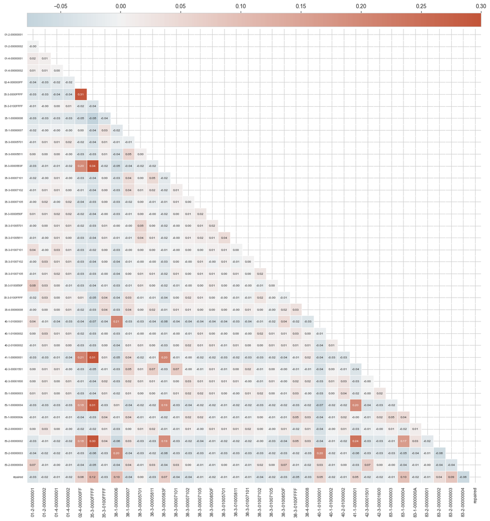

```python
import numpy as np
import seaborn as sns
import matplotlib.pyplot as plt
from mpl_toolkits.axes_grid1 import make_axes_locatable

def draw_heatmap(corr, features):
    # Genera una máscara para el triángulo superior
    mask = np.triu(np.ones_like(corr, dtype=bool))

    # Configura la figura matplotlib
    f, ax = plt.subplots(figsize=(15, 19))

    # Genera un mapa de color divergente personalizado
    cmap = sns.diverging_palette(230, 20, as_cmap=True)

    # Dibuja el mapa de calor con la máscara y el aspecto adecuados
    sns_heatmap = sns.heatmap(corr, mask=mask, cmap=cmap, vmax=.3, center=0,
                              square=True, linewidths=.4, annot=True, fmt=".2f",
                              annot_kws={"size": 6}, cbar=False)

    # Crea nuevos ejes para la barra de color
    divider = make_axes_locatable(ax)
    cax = divider.append_axes("top", size="3%", pad=0.05)

    # Añade la barra de color a los nuevos ejes
    cbar = plt.colorbar(sns_heatmap.collections[0], cax=cax, orientation="horizontal")
    cbar.ax.xaxis.set_ticks_position('top')
    cax.xaxis.set_label_position('top')

    # Modifica el tamaño del texto de las etiquetas de los ejes
    plt.setp(ax.get_xticklabels(), fontsize=8)
    plt.setp(ax.get_yticklabels(), fontsize=5)

    plt.show()

# Calcula la matriz de correlaciones completa
corr_full = scaled_df.corr()

# Primeras 38 características y "repaired"
features_1 = list(scaled_df.columns[:38]) + ['repaired']
corr_1 = corr_full.loc[features_1, features_1]
draw_heatmap(corr_1, features_1)

# Siguientes 37 características y "repaired"
features_2 = list(scaled_df.columns[38:75]) + ['repaired']
corr_2 = corr_full.loc[features_2, features_2]
draw_heatmap(corr_2, features_2)
```

```python
# Eliminar 'repaired' y ordenar el resto por el valor absoluto de su correlación, en orden descendente
sorted_correlation_list = sorted(
    [item for item in corr_full['repaired'].items() if item[0] != 'repaired'],
    key=lambda x: abs(x[1]),
    reverse=True
)

# Extrae los nombres de las 30 características más correlacionadas
top_30_features = [feature for feature, _ in sorted_correlation_list[:30]]
# Muestra las 30 características más correlacionadas
sorted_correlation_list[:30]
```

```
[('traffic_volume', 0.23559780008868264),
 ('traffic_volume_per_prov', 0.15915685287744077),
 ('province_name', 0.15767986868778539),
 ('35-3-0000FFFF', 0.12389791249065467),
 ('38-1-00000006', 0.10219692349956357),
 ('community_name', 0.0994074917617786),
 ('traffic_volume_per_comm', 0.09872992800464854),
 ('83-1-00000004', 0.09520607860389427),
 ('total_hw_events_per_comm', 0.08772760451763781),
 ('total_errors_per_comm', 0.08759118868331785),
 ('atms_num_per_comm', 0.08755393397582484),
 ('total_events_per_comm', 0.0874071086054833),
 ('83-2-00000003', 0.08563077785312087),
 ('38-3-0000583F', 0.07078082842414676),
 ('generates_events', 0.06532206369956516),
 ('techs_num_per_comm', 0.06505314091944438),
 ('83-2-00000004', -0.06250819353873045),
 ('02-4-000000FF', 0.06032606086974981),
 ('most_frequent_response_code_per_atm', 0.0588462606081968),
 ('total_hw_events_per_prov', 0.0575265034994479),
 ('41-1-00000001', 0.05473995838511474),
 ('40-1-01000001', 0.0534123217332511),
 ('most_frequent_hour_per_prov', 0.051891659871002006),
 ('most_frequent_event_code_1_per_atm', 0.05057239066880998),
 ('38-3-0100FFFF', -0.049264070355609674),
 ('most_frequent_hour_per_comm', 0.04865043641593613),
 ('38-1-00000007', -0.0443554399739513),
 ('total_errors_per_prov', 0.04283629326988608),
 ('83-2-00000002', 0.0408805446182299),
 ('total_events_per_prov', 0.04009028774926054)]
```

El hecho de que sólo se encuentren correlaciones bajas no es un buen augurio, pero **no elimina la posibilidad de que existan buenos predictores en el conjunto de datos**. Por un lado, se debe tener en cuenta que la correlación mide relaciones lineales entre variables. Si la relación entre las características y la variable objetivo no es lineal, una métrica como el coeficiente de Pearson no capturaría la fuerza de esa relación y la regresión logística no sería el algoritmo adecuado en este caso. Por otro lado, **es posible que una característica por sí sola no tanga una fuerte correlación con la variable objetivo, pero podría tenerla cuando se combina con otra/s**. Estas interacciones entre características son difíciles de capturar mediante análisis de correlación univariados; a continuación, utilizaremos la selección de características hacia adelante para intentar identificarlas.

##### Selección de características hacia adelante

La selección de características hacia adelante (Forward Feature Selection) es un método de selección de características en el que **se comienza con un conjunto vacío de características y se van añadiendo una a una las características que mejoran el rendimiento del modelo**. Este enfoque es útil cuando se tiene un conjunto de datos con muchas características (como este) y se quiere reducir la dimensionalidad sin sacrificar la precisión del modelo.

Teniendo en cuenta que nuestra variable objetivo está perfectamente equilibrada, podemos utilizar la **exactitud (accuracy) o el índice AUC-ROC (Área Bajo la Curva de Características Operativas del Receptor)** a la hora de evaluar los distintos modelos obtenidos con uno u otro conjunto de atributos. **Ambos métodos serían apropiados en este caso**, aunque nos decantamos por el último debido a que AUC-ROC considera todos los umbrales posibles, proporcionando una medida más completa de la capacidad del modelo para distinguir entre clases y se enfoca en la capacidad del modelo para separarlas, más que en su capacidad para "etiquetar" correctamente las observaciones.

Se utiliza también la técnica de **validación cruzada**. Este método **divide el conjunto de datos en varias particiones o pliegues (folds) y realiza múltiples rondas de entrenamiento y evaluación** (cada vez con una partición diferente como conjunto de prueba y el resto como conjunto de entrenamiento). Luego, la métrica de rendimiento se promedia sobre todas las rondas para obtener una estimación más robusta del rendimiento del modelo. Resulta muy útil para evitar el sobreajuste del modelo con el conjunto de entrenamiento y ofrece una mejor idea de cómo el modelo y las características seleccionadas se podrían generalizar a nuevos datos en el futuro.

```python
from sklearn.metrics import roc_auc_score
from sklearn.linear_model import LogisticRegression
from sklearn.model_selection import train_test_split
from sklearn.model_selection import cross_val_score

# Separa las características y la variable objetivo
X = scaled_df[top_30_features]
y = scaled_df['repaired']

# Inicialización
selected_features = []  # Lista para almacenar las características seleccionadas
remaining_features = list(X.columns)  # Lista de características restantes
best_auc = 0  # Mejor AUC-ROC obtenido hasta ahora

# Número de características a seleccionar
num_features_to_select = 10

# Bucle para la selección de características hacia adelante
for i in range(num_features_to_select):
    feature_auc_dict = {}  # Diccionario para almacenar el AUC de cada característica

    # Itera sobre cada característica restante y evalúa su AUC cuando se añade al conjunto actual de características seleccionadas
    for feature in remaining_features:
        temp_feature_list = selected_features + [feature]
        temp_X = X[temp_feature_list]

        # Entrena un modelo de regresión logística y calcula su AUC-ROC usando validación cruzada
        clf = LogisticRegression(random_state=1)
        cross_val_auc = cross_val_score(clf, temp_X, y, cv=5, scoring='roc_auc')
        auc = np.mean(cross_val_auc)

        # Almacena el AUC de la característica en el diccionario
        feature_auc_dict[feature] = auc

    # Encuentra la característica que proporciona el mayor aumento en AUC-ROC y la añade a la lista de características seleccionadas
    best_feature = max(feature_auc_dict, key=feature_auc_dict.get)
    best_feature_auc = feature_auc_dict[best_feature]

    # Se detiene si la métrica no mejora significativamente
    if best_feature_auc <= best_auc:
        print("La métrica dejó de mejorar. Se detiene la selección de características.")
        break

    # Actualiza las listas y valores
    selected_features.append(best_feature)
    remaining_features.remove(best_feature)
    best_auc = best_feature_auc

    print(f"Iteración {i+1}: Característica seleccionada = {best_feature}, AUC-ROC = {best_auc}")

# Muestra las características seleccionadas
print("\nCaracterísticas seleccionadas:", selected_features)
```

```
Iteración 1: Característica seleccionada = 38-1-00000006, AUC-ROC = 0.5365303061755183
Iteración 2: Característica seleccionada = 35-3-0000FFFF, AUC-ROC = 0.569574148282555
Iteración 3: Característica seleccionada = most_frequent_event_code_1_per_atm, AUC-ROC = 0.5782999070240452
Iteración 4: Característica seleccionada = 38-1-00000007, AUC-ROC = 0.5835276304453021
Iteración 5: Característica seleccionada = 38-3-0100FFFF, AUC-ROC = 0.5853052390836648
Iteración 6: Característica seleccionada = 83-2-00000004, AUC-ROC = 0.5865450092142085
Iteración 7: Característica seleccionada = generates_events, AUC-ROC = 0.5869178317175565
Iteración 8: Característica seleccionada = 40-1-01000001, AUC-ROC = 0.5870022980772169
La métrica dejó de mejorar. Se detiene la selección de características.

Características seleccionadas: ['38-1-00000006', '35-3-0000FFFF', 'most_frequent_event_code_1_per_atm', '38-1-00000007', '38-3-0100FFFF', '83-2-00000004', 'generates_events', '40-1-01000001']
```

#### Random Forests

##### Selección de características

Ahora, vamos a aplicar **distintos criterios de selección de características: chi-cuadrado, ANOVA F_value e información mutua**. Para hacerlo se van a utilizar los datos escalados, ya que algunos de estos algoritmos no aceptan valores negativos.

```python
# Selección de características (se utilizan los datos escalados)
import pandas as pd
from sklearn.feature_selection import SelectKBest, chi2, f_classif, mutual_info_classif

# Separa las características y la variable objetivo
X_scaled = scaled_df.drop(columns='repaired')
y = scaled_df['repaired']

# Diccionario para almacenar las características seleccionadas por cada criterio
selected_features = {}

# Función para ordenar características por puntuación
def sort_features_by_score(features, scores):
    sorted_indices = sorted(range(len(scores)), key=lambda k: scores[k], reverse=True)
    return [features[i] for i in sorted_indices], [scores[i] for i in sorted_indices]

# Chi-cuadrado
kbest_chi2 = SelectKBest(score_func=chi2, k='all')
kbest_chi2.fit_transform(X_scaled, y)
features, scores = sort_features_by_score(X_scaled.columns.tolist(), kbest_chi2.scores_)
selected_features['Chi2'] = {'features': features, 'scores': scores}

# ANOVA F-value
kbest_f_classif = SelectKBest(score_func=f_classif, k='all')
kbest_f_classif.fit_transform(X_scaled, y)
features, scores = sort_features_by_score(X_scaled.columns.tolist(), kbest_f_classif.scores_)
selected_features['F_classif'] = {'features': features, 'scores': scores}

# Información mutua
kbest_mutual_info = SelectKBest(score_func=mutual_info_classif, k='all')
kbest_mutual_info.fit_transform(X_scaled, y)
features, scores = sort_features_by_score(X_scaled.columns.tolist(), kbest_mutual_info.scores_)
selected_features['Mutual_info'] = {'features': features, 'scores': scores}

# Mostrar las características seleccionadas y sus puntuaciones para cada criterio
for criteria, data in selected_features.items():
    print(f"Selected features based on {criteria}:")
    for feature, score in zip(data['features'], data['scores']):
        print(f"  - {feature}: {score}")
```

```
Selected features based on Chi2:
  - traffic_volume: 421992.66593544674
  - province_name: 114126.29756221795
  - traffic_volume_per_prov: 107552.72046893413
  - 35-3-0000FFFF: 52450.83465035238
  - 38-1-00000006: 33709.5512037847
  - traffic_volume_per_comm: 30948.23549502182
  - community_name: 30056.747086042284
  - 83-1-00000004: 23520.343785604717
  - total_errors_per_comm: 21460.896684884705
  - total_hw_events_per_comm: 21433.17960331838
  - atms_num_per_comm: 21423.639047259243
  - total_events_per_comm: 21292.415773614906
  - 83-2-00000003: 17848.779172767965
  - most_frequent_response_code_per_atm: 14560.532124809852
  - 38-3-0000583F: 12386.287831281057
  - 02-4-000000FF: 12221.575395277494
  - techs_num_per_comm: 10365.045395129438
  - 83-2-00000004: 9801.495597059868
  - 40-1-01000001: 9169.485195149975
  - 38-3-0100FFFF: 8183.608530340125
  - 41-1-00000001: 7366.46246222553
  - 38-1-00000007: 6695.334812523668
  - 38-3-00007102: 5436.746267095838
  - 38-3-01007102: 4675.114050837088
  - total_hw_events_per_prov: 4389.616530846679
  - 83-2-00000002: 4316.426704286885
  - most_frequent_event_code_1_per_atm: 3986.3150394596305
  - 38-3-0100850F: 3966.4538495040442
  - most_frequent_hour_per_prov: 3921.8425457090957
  - 38-3-00007101: 3116.9528556540035
  - 38-3-00005811: 3024.350601245672
  - 01-2-00000001: 2820.549918075406
  - 38-4-00000008: 2577.9515173204486
  - total_errors_per_prov: 2473.5754523590513
  - total_events_per_prov: 2021.4824203636558
  - most_frequent_hour_per_comm: 1940.7947142340895
  - 35-3-0100FFFF: 1780.0483731358347
  - most_frequent_event_code_3_per_atm: 1591.032181999973
  - atms_num_per_prov: 1530.2181204594137
```

[output cut: 173 more lines]

```
  - 42-3-00001600: 0.023410198977351193
  - 38-3-00007101: 0.0233851817850943
  - 35-3-0100FFFF: 0.023328970732293675
  - 38-3-01007105: 0.022953257075038147
  - 38-3-01007101: 0.022914615651703718
  - 38-3-01005811: 0.022867687873188824
  - 40-1-01000002: 0.022834205085107584
  - 83-2-00000001: 0.022772236209724683
  - 38-3-0000850F: 0.022658298165546986
  - 01-4-00000002: 0.022302877219311013
  - 38-3-00007105: 0.02226755011553072
  - 38-3-00005701: 0.02207297031045874
  - 01-4-00000001: 0.02157644446309548
  - size: 0.015651970554931394
  - most_frequent_response_code_per_atm: 0.012629756078393894
```

Parece que los tres criterios utilizados coinciden en señalar a la variable "traffic_volume" como la más importante a la hora de predecir nuestra variable objetivo "repaired". Ahora, vamos a implementar una selección de características hacia adelante usando el algoritmo Random Forest.

```python
from sklearn.ensemble import RandomForestClassifier
from sklearn.model_selection import train_test_split
from sklearn.metrics import roc_auc_score
import pandas as pd
import numpy as np

# Separa las características y la variable objetivo
X = model_df.drop(columns='repaired')
y = model_df['repaired']

# Divide el conjunto de datos en entrenamiento y prueba
X_train, X_test, y_train, y_test = train_test_split(X, y, test_size=0.2, random_state=1)

selected_features = []
best_auc = 0.0

for feature in X.columns:
    temp_features = selected_features + [feature]

    # Subconjunto de características
    X_train_temp = X_train[temp_features]
    X_test_temp = X_test[temp_features]

    # Entrenamiento del modelo
    clf = RandomForestClassifier(n_estimators=100, random_state=1)
    clf.fit(X_train_temp, y_train)

    # Predicción y evaluación
    y_pred = clf.predict_proba(X_test_temp)[:, 1]
    auc = roc_auc_score(y_test, y_pred)

    # Verificación de mejora en AUC
    if auc > best_auc:
        best_auc = auc
        selected_features.append(feature)
        print(f'La característica {feature} mejoró AUC: {best_auc}. Se conserva.')
    else:
        print(f'La característica {feature} no mejoró AUC: {auc}. Se descarta.')

print('Selected features:', selected_features)
```

[output not shown]

Este método de selección de características también otorga una gran importancia a la variable "traffic_volume". Además, parece que si la combinamos con "size", "province_code" y "most_frequent_hour_per_atm" podríamos obtener un modelo simple a la par que efectivo. De hecho, se trata de seleccionar **la combinación del menor número de atributos que mejores resultados ofrezca (principio de Parsimonia)**.

```python
# Separa las características y la variable objetivo
X = model_df.drop(columns='repaired')
y = model_df['repaired']

# Selección de características
X_selected = X[['size', 'province_code', 'most_frequent_hour_per_atm', 'traffic_volume']]
```